# Requirements

## Actual Electric

```python
# Correct Google Sheets ID
sheet_id = "1sd0RsLIxi6WN-tPn-DykxQ51WIZofurX"
sheet_url = f"https://docs.google.com/spreadsheets/d/{sheet_id}/export?format=xlsx"

# Suppress specific openpyxl warnings
warnings.filterwarnings("ignore", category=UserWarning, module="openpyxl")

# Fetch the file
response = requests.get(sheet_url)

# If the request was successful, read the Excel file into a DataFrame
if response.status_code == 200:
    # Use BytesIO to treat the content as a file
    file_data = BytesIO(response.content)

    # Read the Excel file
    electric = pd.read_excel(file_data)

    # Display the first few rows of the DataFrame
    print(electric.head())
else:
    print(f"Failed to download the file. Status code: {response.status_code}")
```

```
             TYPE       DATE START_TIME  END_TIME  USAGE_(kWh)  COST  \
0  Electric usage 2023-01-01   00:00:00  00:29:00         0.72   0.0
1  Electric usage 2023-01-01   00:30:00  00:59:00         0.74   0.0
2  Electric usage 2023-01-01   01:00:00  01:29:00         0.75   0.0
3  Electric usage 2023-01-01   01:30:00  01:59:00         0.77   0.0
4  Electric usage 2023-01-01   02:00:00  02:29:00         0.69   0.0

   ESTIMATED_USAGE  NOTES
0              NaN    NaN
1              NaN    NaN
2              NaN    NaN
3              NaN    NaN
4              NaN    NaN
```

```python
# Step 1: Convert 'DATE' to string and ensure 'START_TIME' is also a string before concatenating
electric['starttimestamp'] = pd.to_datetime(electric['DATE'].astype(str) + ' ' + electric['START_TIME'].astype(str), errors='coerce')

# Step 2: Convert 'DATE' to string and ensure 'END_TIME' is also a string before concatenating
electric['endtimestamp'] = pd.to_datetime(electric['DATE'].astype(str) + ' ' + electric['END_TIME'].astype(str), errors='coerce')

# Step 3: Create 'last_day_month' column with the last day of the month for each date
electric['last_day_month'] = pd.to_datetime(electric['DATE']).dt.to_period('M').dt.to_timestamp('M')

# Display the first few rows to verify
print(electric.head())
```

```
             TYPE       DATE START_TIME  END_TIME  USAGE_(kWh)  COST  \
0  Electric usage 2023-01-01   00:00:00  00:29:00         0.72   0.0
1  Electric usage 2023-01-01   00:30:00  00:59:00         0.74   0.0
2  Electric usage 2023-01-01   01:00:00  01:29:00         0.75   0.0
3  Electric usage 2023-01-01   01:30:00  01:59:00         0.77   0.0
4  Electric usage 2023-01-01   02:00:00  02:29:00         0.69   0.0

   ESTIMATED_USAGE  NOTES      starttimestamp        endtimestamp  \
0              NaN    NaN 2023-01-01 00:00:00 2023-01-01 00:29:00
1              NaN    NaN 2023-01-01 00:30:00 2023-01-01 00:59:00
2              NaN    NaN 2023-01-01 01:00:00 2023-01-01 01:29:00
3              NaN    NaN 2023-01-01 01:30:00 2023-01-01 01:59:00
4              NaN    NaN 2023-01-01 02:00:00 2023-01-01 02:29:00

  last_day_month
0     2023-01-31
1     2023-01-31
2     2023-01-31
3     2023-01-31
4     2023-01-31
```

```python
# Ensure 'START_TIME' is converted to a string before splitting, and fill NaNs with a default value
electric['hour'] = electric['START_TIME'].fillna('00:00').astype(str).str.split(':').str[0].astype(int)

# Display the first few rows to verify
print(electric.head())
```

```
             TYPE       DATE START_TIME  END_TIME  USAGE_(kWh)  COST  \
0  Electric usage 2023-01-01   00:00:00  00:29:00         0.72   0.0
1  Electric usage 2023-01-01   00:30:00  00:59:00         0.74   0.0
2  Electric usage 2023-01-01   01:00:00  01:29:00         0.75   0.0
3  Electric usage 2023-01-01   01:30:00  01:59:00         0.77   0.0
4  Electric usage 2023-01-01   02:00:00  02:29:00         0.69   0.0

   ESTIMATED_USAGE  NOTES      starttimestamp        endtimestamp  \
0              NaN    NaN 2023-01-01 00:00:00 2023-01-01 00:29:00
1              NaN    NaN 2023-01-01 00:30:00 2023-01-01 00:59:00
2              NaN    NaN 2023-01-01 01:00:00 2023-01-01 01:29:00
3              NaN    NaN 2023-01-01 01:30:00 2023-01-01 01:59:00
4              NaN    NaN 2023-01-01 02:00:00 2023-01-01 02:29:00

  last_day_month  hour
0     2023-01-31     0
1     2023-01-31     0
2     2023-01-31     1
3     2023-01-31     1
4     2023-01-31     2
```

```python
electric
```

|  | TYPE | DATE | START_TIME | END_TIME | USAGE_(kWh) | COST | ESTIMATED_USAGE | NOTES | starttimestamp | endtimestamp | last_day_month | hour |
| --- | --- | --- | --- | --- | --- | --- | --- | --- | --- | --- | --- | --- |
| 0 | Electric usage | 2023-01-01 | 00:00:00 | 00:29:00 | 0.72 | 0.00 | NaN | NaN | 2023-01-01 00:00:00 | 2023-01-01 00:29:00 | 2023-01-31 | 0 |
| 1 | Electric usage | 2023-01-01 | 00:30:00 | 00:59:00 | 0.74 | 0.00 | NaN | NaN | 2023-01-01 00:30:00 | 2023-01-01 00:59:00 | 2023-01-31 | 0 |
| 2 | Electric usage | 2023-01-01 | 01:00:00 | 01:29:00 | 0.75 | 0.00 | NaN | NaN | 2023-01-01 01:00:00 | 2023-01-01 01:29:00 | 2023-01-31 | 1 |
| 3 | Electric usage | 2023-01-01 | 01:30:00 | 01:59:00 | 0.77 | 0.00 | NaN | NaN | 2023-01-01 01:30:00 | 2023-01-01 01:59:00 | 2023-01-31 | 1 |
| 4 | Electric usage | 2023-01-01 | 02:00:00 | 02:29:00 | 0.69 | 0.00 | NaN | NaN | 2023-01-01 02:00:00 | 2023-01-01 02:29:00 | 2023-01-31 | 2 |
| ... | ... | ... | ... | ... | ... | ... | ... | ... | ... | ... | ... | ... |
| 37285 | Electric usage | 2025-02-14 | 21:30:00 | 21:59:00 | 0.74 | 0.11 | NaN | NaN | 2025-02-14 21:30:00 | 2025-02-14 21:59:00 | 2025-02-28 | 21 |
| 37286 | Electric usage | 2025-02-14 | 22:00:00 | 22:29:00 | 0.86 | 0.12 | NaN | NaN | 2025-02-14 22:00:00 | 2025-02-14 22:29:00 | 2025-02-28 | 22 |
| 37287 | Electric usage | 2025-02-14 | 22:30:00 | 22:59:00 | 0.52 | 0.07 | NaN | NaN | 2025-02-14 22:30:00 | 2025-02-14 22:59:00 | 2025-02-28 | 22 |
| 37288 | Electric usage | 2025-02-14 | 23:00:00 | 23:29:00 | 0.45 | 0.06 | NaN | NaN | 2025-02-14 23:00:00 | 2025-02-14 23:29:00 | 2025-02-28 | 23 |
| 37289 | Electric usage | 2025-02-14 | 23:30:00 | 23:59:00 | 0.48 | 0.07 | NaN | NaN | 2025-02-14 23:30:00 | 2025-02-14 23:59:00 | 2025-02-28 | 23 |

37290 rows × 12 columns

```python
# Function to clean and convert the COST column
def clean_cost(value):
    if isinstance(value, str):
        # Remove dollar sign and commas
        value = value.replace('$', '').replace(',', '')
        # Handle negative values in parentheses
        if '(' in value and ')' in value:
            value = '-' + value.replace('(', '').replace(')', '')
        return float(value)
    else:
        # If the value is already a float, return it as is
        return value

# Apply the cleaning function to the COST column
electric['COST'] = electric['COST'].apply(clean_cost)

# Group by DATE, hour, and last_day_month, then aggregate
electric_agg = electric.groupby(['DATE', 'hour', 'last_day_month']).agg({
    'USAGE_(kWh)': 'sum',
    'COST': 'sum',
    'ESTIMATED_USAGE':'sum'
}).reset_index()

# Create the date_timestamp column
electric_agg['date_timestamp'] = pd.to_datetime(electric_agg['DATE']) + pd.to_timedelta(electric_agg['hour'].astype(int), unit='h')

# Display the new aggregated DataFrame
print(electric_agg.head())
```

```
        DATE  hour last_day_month  USAGE_(kWh)  COST  ESTIMATED_USAGE  \
0 2023-01-01     0     2023-01-31         1.46   0.0              0.0
1 2023-01-01     1     2023-01-31         1.52   0.0              0.0
2 2023-01-01     2     2023-01-31         1.14   0.0              0.0
3 2023-01-01     3     2023-01-31         1.64   0.0              0.0
4 2023-01-01     4     2023-01-31         2.74   0.0              0.0

       date_timestamp
0 2023-01-01 00:00:00
1 2023-01-01 01:00:00
2 2023-01-01 02:00:00
3 2023-01-01 03:00:00
4 2023-01-01 04:00:00
```

```python
# Find the date_timestamp values that have more than one occurrence
duplicate_date_x = electric_agg['date_timestamp'].value_counts()

# Filter to keep only those that appear more than once
duplicate_date_x = duplicate_date_x[duplicate_date_x > 1]

# Display the duplicate date_x values
print("Duplicate date_x timestamps (with more than one occurrence):")
print(duplicate_date_x)
```

```
Duplicate date_x timestamps (with more than one occurrence):
Series([], Name: count, dtype: int64)
```

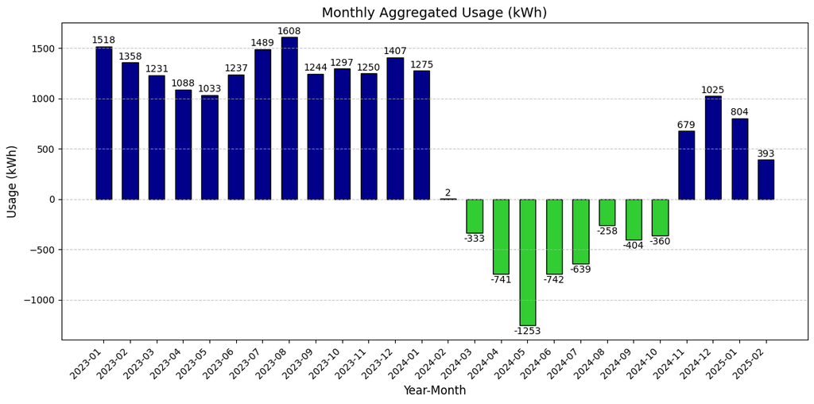

```python
# Extract year and month from the 'DATE' column
electric_agg['YearMonth'] = electric_agg['DATE'].dt.to_period('M')

# Group by 'YearMonth' and aggregate the sum for 'USAGE_(kWh)'
monthly_agg = electric_agg.groupby('YearMonth')['USAGE_(kWh)'].sum()

# Reset index for better readability
monthly_agg = monthly_agg.reset_index()

# Create a bar chart with conditional coloring
plt.figure(figsize=(12, 6))

# Define colors based on positive or negative values
colors = ['darkblue' if value >= 0 else 'limegreen' for value in monthly_agg['USAGE_(kWh)']]

bars = plt.bar(
    monthly_agg['YearMonth'].astype(str),
    monthly_agg['USAGE_(kWh)'],
    width=0.6,
    color=colors,
    edgecolor='black'
)

# Add data labels on the outside end of each bar
for bar in bars:
    height = bar.get_height()
    # Adjust label position based on whether the bar is positive or negative
    label_position = height + (10 if height > 0 else -15)
    plt.text(
        bar.get_x() + bar.get_width() / 2,  # Horizontal position
        label_position,  # Vertical position
        f'{int(round(height))}',  # Label text without decimals
        ha='center', va='bottom' if height > 0 else 'top', fontsize=10
    )

# Add labels and title
plt.title('Monthly Aggregated Usage (kWh)', fontsize=14)
plt.xlabel('Year-Month', fontsize=12)
plt.ylabel('Usage (kWh)', fontsize=12)

# Rotate x-axis labels for better readability
plt.xticks(rotation=45, ha='right')

# Add grid for better readability
plt.grid(axis='y', linestyle='--', alpha=0.7)

# Show the chart
plt.tight_layout()
plt.show()
```

### Look at cost info to compute cost_per_kwh

```python
electric_agg.info(verbose=True)
```

```
<class 'pandas.core.frame.DataFrame'>
RangeIndex: 18622 entries, 0 to 18621
Data columns (total 8 columns):
 #   Column           Non-Null Count  Dtype
---  ------           --------------  -----
 0   DATE             18622 non-null  datetime64[ns]
 1   hour             18622 non-null  int64
 2   last_day_month   18622 non-null  datetime64[ns]
 3   USAGE_(kWh)      18622 non-null  float64
 4   COST             18622 non-null  float64
 5   ESTIMATED_USAGE  18622 non-null  float64
 6   date_timestamp   18622 non-null  datetime64[ns]
 7   YearMonth        18622 non-null  period[M]
dtypes: datetime64[ns](3), float64(3), int64(1), period[M](1)
memory usage: 1.1 MB
```

```python
# Define the solar billing start date (Net Metering Start Date)
solar_start_date = pd.Timestamp('2024-01-08')

# Step 1: Compute Unaltered Cost per kWh (Raw Calculation)
electric_agg['unaltered_cost_per_kWh'] = np.where(
    electric_agg['USAGE_(kWh)'] != 0,
    electric_agg['COST'] / electric_agg['USAGE_(kWh)'],
    np.nan
)

# Step 2: Compute cost_per_kWh with prior working logic (Only After Solar Start Date)
electric_agg['cost_per_kWh'] = np.where(
    electric_agg['date_timestamp'] < solar_start_date,
    np.abs(electric_agg['unaltered_cost_per_kWh']),  # Always positive before solar start
    np.where(
        (electric_agg['USAGE_(kWh)'] > 0) & (electric_agg['COST'] < 0),
        0,  # Prevent negative costs on positive usage
        np.abs(electric_agg['unaltered_cost_per_kWh'])  # Always positive after solar start
    )
)

# Step 3: Cap Outliers Before Smoothing (Only After Solar Start)
cap_value = electric_agg.loc[electric_agg['date_timestamp'] >= solar_start_date, 'cost_per_kWh'].quantile(0.85)
electric_agg['cost_per_kWh'] = np.where(
    (electric_agg['date_timestamp'] >= solar_start_date) & (electric_agg['cost_per_kWh'] > cap_value),
    cap_value,  # Cap to the 85th percentile
    electric_agg['cost_per_kWh']
)

# Step 4: Apply Adaptive Smoothing After Capping
electric_agg['cost_per_kWh_smoothed'] = (
    electric_agg['cost_per_kWh']
    .ewm(span=5, adjust=False)
    .mean()
)

# Step 5: Final cost_per_kWh_final (Always Positive)
# Pre-Solar Start: Keep smoothed or unaltered positive value
# Post-Solar Start: Use smoothed result if original is zero, else enforce positive value
electric_agg['cost_per_kWh_final'] = np.where(
    electric_agg['date_timestamp'] < solar_start_date,
    np.abs(electric_agg['unaltered_cost_per_kWh']),  # Enforce positive pre-solar
    np.where(
        electric_agg['cost_per_kWh'] == 0,  # Use smoothed result if original is zero
        np.abs(electric_agg['cost_per_kWh_smoothed']),  # Enforce positive smoothing
        np.abs(electric_agg['cost_per_kWh'])  # Otherwise, enforce positive original
    )
)
```

```python
# Calculate descriptive statistics for cost_per_kWh and Net_Cost_per_kWh
descriptives = electric_agg['cost_per_kWh_final'].describe()

# Display the results
print(descriptives)
```

```
count    18615.000000
mean         0.135673
std          0.057435
min          0.000000
25%          0.119403
50%          0.133929
75%          0.149701
max          1.246575
Name: cost_per_kWh_final, dtype: float64
```

```python
### 📌 Verify Results ###
# Define the time range for inspection
start_datetime = pd.Timestamp('2024-05-26 08:00:00')
end_datetime = pd.Timestamp('2024-05-26 17:00:00')

# Filter and display rows within the specified time range
result_rows = electric_agg[
    (electric_agg['date_timestamp'] >= start_datetime) &
    (electric_agg['date_timestamp'] <= end_datetime)
][[
    'date_timestamp', 'USAGE_(kWh)', 'COST', 'unaltered_cost_per_kWh',
    'cost_per_kWh', 'cost_per_kWh_smoothed', 'cost_per_kWh_final'
]]

result_rows
```

|  | date_timestamp | USAGE_(kWh) | COST | unaltered_cost_per_kWh | cost_per_kWh | cost_per_kWh_smoothed | cost_per_kWh_final |
| --- | --- | --- | --- | --- | --- | --- | --- |
| 12270 | 2024-05-26 08:00:00 | -0.11 | 0.16 | -1.454545 | 0.166667 | 0.110723 | 0.166667 |
| 12271 | 2024-05-26 09:00:00 | 0.99 | 0.18 | 0.181818 | 0.166667 | 0.129371 | 0.166667 |
| 12272 | 2024-05-26 10:00:00 | 1.16 | 0.17 | 0.146552 | 0.146552 | 0.135098 | 0.146552 |
| 12273 | 2024-05-26 11:00:00 | 1.07 | 0.16 | 0.149533 | 0.149533 | 0.139909 | 0.149533 |
| 12274 | 2024-05-26 12:00:00 | 1.04 | -0.03 | -0.028846 | 0.000000 | 0.093273 | 0.093273 |
| 12275 | 2024-05-26 13:00:00 | -0.15 | -0.42 | 2.800000 | 0.166667 | 0.117737 | 0.166667 |
| 12276 | 2024-05-26 14:00:00 | -2.66 | -0.29 | 0.109023 | 0.109023 | 0.114833 | 0.109023 |
| 12277 | 2024-05-26 15:00:00 | -1.92 | -0.21 | 0.109375 | 0.109375 | 0.113013 | 0.109375 |
| 12278 | 2024-05-26 16:00:00 | -1.37 | 0.00 | -0.000000 | 0.000000 | 0.075342 | 0.075342 |
| 12279 | 2024-05-26 17:00:00 | -0.01 | 0.52 | -52.000000 | 0.166667 | 0.105784 | 0.166667 |

```python
### 📌  Verify Results ###
# Define the time range for inspection
start_datetime = pd.Timestamp('2024-07-26 08:00:00')
end_datetime = pd.Timestamp('2024-07-26 17:00:00')

# Filter and display rows within the specified time range
result_rows = electric_agg[
    (electric_agg['date_timestamp'] >= start_datetime) &
    (electric_agg['date_timestamp'] <= end_datetime)
][[
    'date_timestamp', 'USAGE_(kWh)', 'COST', 'unaltered_cost_per_kWh',
    'cost_per_kWh', 'cost_per_kWh_smoothed', 'cost_per_kWh_final'
]]

result_rows
```

|  | date_timestamp | USAGE_(kWh) | COST | unaltered_cost_per_kWh | cost_per_kWh | cost_per_kWh_smoothed | cost_per_kWh_final |
| --- | --- | --- | --- | --- | --- | --- | --- |
| 13734 | 2024-07-26 08:00:00 | -7.13 | -1.14 | 0.159888 | 0.159888 | 0.141318 | 0.159888 |
| 13735 | 2024-07-26 09:00:00 | -8.40 | -1.36 | 0.161905 | 0.161905 | 0.148180 | 0.161905 |
| 13736 | 2024-07-26 10:00:00 | -10.10 | -1.43 | 0.141584 | 0.141584 | 0.145981 | 0.141584 |
| 13737 | 2024-07-26 11:00:00 | -10.56 | -1.33 | 0.125947 | 0.125947 | 0.139303 | 0.125947 |
| 13738 | 2024-07-26 12:00:00 | -9.83 | -0.54 | 0.054934 | 0.054934 | 0.111180 | 0.054934 |
| 13739 | 2024-07-26 13:00:00 | -4.01 | 0.21 | -0.052369 | 0.052369 | 0.091576 | 0.052369 |
| 13740 | 2024-07-26 14:00:00 | 1.56 | 0.56 | 0.358974 | 0.166667 | 0.116607 | 0.166667 |
| 13741 | 2024-07-26 15:00:00 | 4.15 | 0.14 | 0.033735 | 0.033735 | 0.088983 | 0.033735 |
| 13742 | 2024-07-26 16:00:00 | 1.01 | -0.02 | -0.019802 | 0.000000 | 0.059322 | 0.059322 |
| 13743 | 2024-07-26 17:00:00 | -0.15 | 0.02 | -0.133333 | 0.133333 | 0.083992 | 0.133333 |

```python
# Step 1: Rename the original cost_per_kWh column to Net_Cost_per_kWh
electric_agg.rename(columns={'unaltered_cost_per_kWh': 'Net_Cost_per_kWh'}, inplace=True)

# Step 2: Replace cost_per_kWh with cost_per_kWh_final
electric_agg['cost_per_kWh'] = electric_agg['cost_per_kWh_final']

# Step 3: Drop the normalized and improved versions for clarity
electric_agg.drop(columns=['cost_per_kWh_smoothed', 'cost_per_kWh_final', 'unaltered_cost_per_kWh'], inplace=True, errors='ignore')

# Step 4: Verify the updates
print("Updated electric_agg DataFrame:")
print(electric_agg[['date_timestamp', 'USAGE_(kWh)', 'COST', 'cost_per_kWh', 'Net_Cost_per_kWh']].tail())
```

```
Updated electric_agg DataFrame:
           date_timestamp  USAGE_(kWh)  COST  cost_per_kWh  Net_Cost_per_kWh
18617 2025-02-14 19:00:00         3.28  0.47      0.143293          0.143293
18618 2025-02-14 20:00:00         2.55  0.36      0.141176          0.141176
18619 2025-02-14 21:00:00         1.96  0.28      0.142857          0.142857
18620 2025-02-14 22:00:00         1.38  0.19      0.137681          0.137681
18621 2025-02-14 23:00:00         0.93  0.13      0.139785          0.139785
```

```python
electric_agg.info(verbose=True,show_counts=True)
```

```
<class 'pandas.core.frame.DataFrame'>
RangeIndex: 18622 entries, 0 to 18621
Data columns (total 10 columns):
 #   Column            Non-Null Count  Dtype
---  ------            --------------  -----
 0   DATE              18622 non-null  datetime64[ns]
 1   hour              18622 non-null  int64
 2   last_day_month    18622 non-null  datetime64[ns]
 3   USAGE_(kWh)       18622 non-null  float64
 4   COST              18622 non-null  float64
 5   ESTIMATED_USAGE   18622 non-null  float64
 6   date_timestamp    18622 non-null  datetime64[ns]
 7   YearMonth         18622 non-null  period[M]
 8   Net_Cost_per_kWh  18615 non-null  float64
 9   cost_per_kWh      18615 non-null  float64
dtypes: datetime64[ns](3), float64(5), int64(1), period[M](1)
memory usage: 1.4 MB
```

```python
# Calculate descriptive statistics for cost_per_kWh and Net_Cost_per_kWh
descriptives = electric_agg[['cost_per_kWh', 'Net_Cost_per_kWh']].describe()

# Display the results
print(descriptives)
```

```
       cost_per_kWh  Net_Cost_per_kWh
count  18615.000000      18615.000000
mean       0.135673          0.133492
std        0.057435          0.902204
min        0.000000        -52.000000
25%        0.119403          0.118812
50%        0.133929          0.133333
75%        0.149701          0.149449
max        1.246575         77.000000
```

```python
# Filter rows where cost_per_kWh is greater than 1
high_cost_rows = electric_agg[electric_agg['cost_per_kWh'] > .5]

# Return the dates and the corresponding rows
high_cost_dates = high_cost_rows[['date_timestamp', 'cost_per_kWh']]

# Display the result
print(high_cost_dates)
```

```
          date_timestamp  cost_per_kWh
1976 2023-03-24 09:00:00      0.510417
1986 2023-03-24 19:00:00      0.717241
2041 2023-03-27 02:00:00      0.553191
2083 2023-03-28 20:00:00      0.608696
2091 2023-03-29 04:00:00      0.515464
...                  ...           ...
7295 2023-11-01 00:00:00      0.551724
7319 2023-11-02 00:00:00      0.510638
7379 2023-11-04 12:00:00      0.546392
7438 2023-11-06 23:00:00      0.506329
7450 2023-11-07 11:00:00      0.527473

[78 rows x 2 columns]
```

### Visual to check reasonableness of the cost_per_kWh.

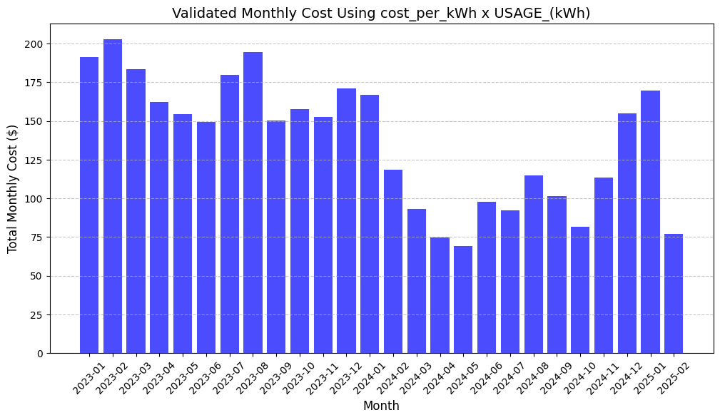

```python
# Ensure 'date_timestamp' is in datetime format
electric_agg['date_timestamp'] = pd.to_datetime(electric_agg['date_timestamp'])

# Filter out rows with negative USAGE or cost_per_kWh
valid_data = electric_agg.loc[
    (electric_agg['USAGE_(kWh)'] > 0) & (electric_agg['cost_per_kWh'] > 0)
].copy()  # Use .copy() to avoid SettingWithCopyWarning

# Extract year and month for grouping
valid_data['Year-Month'] = valid_data['date_timestamp'].dt.to_period('M')

# Calculate total monthly cost using cost_per_kWh
monthly_cost_valid = valid_data.groupby('Year-Month', as_index=False).apply(
    lambda x: pd.Series({'Total_Cost': (x['cost_per_kWh'] * x['USAGE_(kWh)']).sum()}),
    include_groups=False  # Exclude grouping columns during the operation
)

# Convert 'Year-Month' to string for plotting
monthly_cost_valid['Year-Month'] = monthly_cost_valid['Year-Month'].astype(str)

# Plot the monthly cost
import matplotlib.pyplot as plt

plt.figure(figsize=(12, 6))
plt.bar(monthly_cost_valid['Year-Month'], monthly_cost_valid['Total_Cost'], color='blue', alpha=0.7)

# Formatting
plt.xlabel('Month', fontsize=12)
plt.ylabel('Total Monthly Cost ($)', fontsize=12)
plt.title('Validated Monthly Cost Using cost_per_kWh x USAGE_(kWh)', fontsize=14)
plt.xticks(rotation=45)
plt.grid(axis='y', linestyle='--', alpha=0.7)

# Show the plot
plt.show()
```

### Visual to check the electric usage data

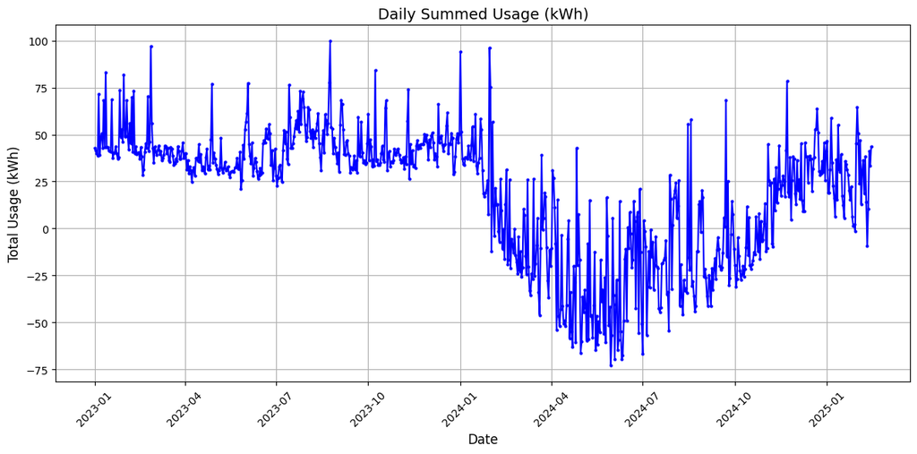

```python
# Ensure 'DATE' is in datetime format
electric_agg['DATE'] = pd.to_datetime(electric_agg['DATE'])

# Step 1: Resample the data by day and sum the 'USAGE_(kWh)'
daily_usage = electric_agg.resample('D', on='DATE')['USAGE_(kWh)'].sum()

# Step 2: Plot the daily summed usage
plt.figure(figsize=(12, 6))
plt.plot(daily_usage.index, daily_usage.values, marker='o', linestyle='-', color='b', markersize=2)

# Adding titles and labels
plt.title('Daily Summed Usage (kWh)', fontsize=14)
plt.xlabel('Date', fontsize=12)
plt.ylabel('Total Usage (kWh)', fontsize=12)

# Display the plot
plt.grid(True)
plt.xticks(rotation=45)
plt.tight_layout()
plt.show()
```

#### The dip in the electric data is because it is has switched to net usage (so it is discounted for the solar production) starting in 1/1/2024). Need to calculate the consumption / total usage by taking the net usage and adding the production.

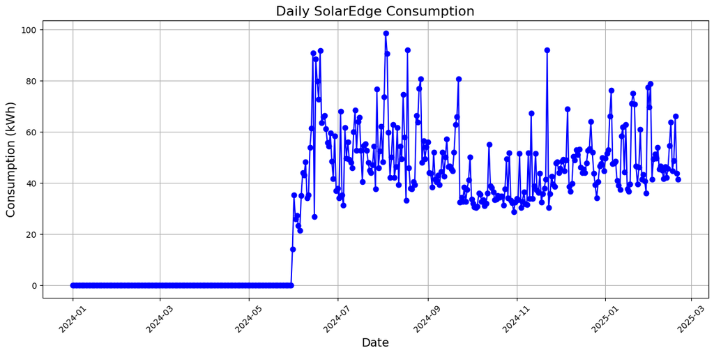

```python
#Look at the Solar Edge Consumption data.
# Ensure 'date' is in datetime format
solaredge_process['date'] = pd.to_datetime(solaredge_process['date'])

# Filter for meter_type 'Consumption'
solaredge_consumption = solaredge_process[solaredge_process['meter_type'] == 'Consumption']

# Aggregate by date and sum the values
daily_consumption = (
    solaredge_consumption.groupby(solaredge_consumption['date'].dt.date)['value']
    .sum()
    .reset_index()
    .rename(columns={'date': 'DATE', 'value': 'Daily_Consumption'})
)

# Convert 'DATE' back to datetime for plotting
daily_consumption['DATE'] = pd.to_datetime(daily_consumption['DATE'])

# Plot the daily consumption
plt.figure(figsize=(12, 6))
plt.plot(daily_consumption['DATE'], daily_consumption['Daily_Consumption'], marker='o', linestyle='-', color='blue')

# Add titles and labels
plt.title('Daily SolarEdge Consumption', fontsize=16)
plt.xlabel('Date', fontsize=14)
plt.ylabel('Consumption (kWh)', fontsize=14)
plt.grid(True)
plt.xticks(rotation=45)

# Display the plot
plt.tight_layout()
plt.show()
```

## Create a solaredge consumption and production dataframe

```python
# Ensure 'date' column in solaredge_process is in datetime format
solaredge_process['date'] = pd.to_datetime(solaredge_process['date'])

# Extract the hour from 'date' in solaredge_process
solaredge_process['hour'] = solaredge_process['date'].dt.hour

# Pivot the DataFrame to create separate columns for 'Consumption', 'Production', 'Purchased', and 'FeedIn'
solaredge_pivoted = solaredge_process.pivot_table(
    index=['date', 'hour'],
    columns='meter_type',
    values='value',
    aggfunc='sum'  # Ensure values are aggregated in case of duplicates
).reset_index()

# Rename columns for clarity
solaredge_pivoted.rename(
    columns={
        'date': 'DATE',
        'Consumption': 'Consumption',
        'Production': 'Production',
        'Purchased': 'Purchased',
        'FeedIn': 'FeedIn'
    },
    inplace=True
)

# Remove any unnecessary columns
solaredge_final = solaredge_pivoted[['DATE', 'hour', 'Consumption', 'Production', 'Purchased', 'FeedIn']]

# Debug: Inspect the prepared solaredge_final DataFrame
print("Prepared SolarEdge Final DataFrame:")
print(solaredge_final.head(20))

# Ensure no duplicates (optional sanity check)
duplicates = solaredge_final.duplicated(subset=['DATE', 'hour'], keep=False)
if duplicates.any():
    print("Duplicates in solaredge_final:")
    print(solaredge_final[duplicates])
else:
    print("No duplicates found in solaredge_final.")
```

```
Prepared SolarEdge Final DataFrame:
meter_type                DATE  hour  Consumption  Production  Purchased  \
0          2024-01-01 00:00:00     0          0.0         0.0        0.0
1          2024-01-01 01:00:00     1          0.0         0.0        0.0
2          2024-01-01 02:00:00     2          0.0         0.0        0.0
3          2024-01-01 03:00:00     3          0.0         0.0        0.0
4          2024-01-01 04:00:00     4          0.0         0.0        0.0
5          2024-01-01 05:00:00     5          0.0         0.0        0.0
6          2024-01-01 06:00:00     6          0.0         0.0        0.0
7          2024-01-01 07:00:00     7          0.0         0.0        0.0
8          2024-01-01 08:00:00     8          0.0         0.0        0.0
9          2024-01-01 09:00:00     9          0.0         0.0        0.0
10         2024-01-01 10:00:00    10          0.0         0.0        0.0
11         2024-01-01 11:00:00    11          0.0         0.0        0.0
12         2024-01-01 12:00:00    12          0.0         0.0        0.0
```

[output cut: 30 more lines]

```python
# Ensure solaredge_final is a copy, not a view
solaredge_final = solaredge_final.copy()
# Add the Net_Usage_SolarEdge column using .loc
solaredge_final.loc[:, 'Net_Usage_SolarEdge'] = solaredge_final['Purchased'] - solaredge_final['FeedIn']
```

```python
solaredge_final.info(verbose=True,show_counts=True)
```

```
<class 'pandas.core.frame.DataFrame'>
RangeIndex: 10008 entries, 0 to 10007
Data columns (total 7 columns):
 #   Column               Non-Null Count  Dtype
---  ------               --------------  -----
 0   DATE                 10008 non-null  datetime64[ns]
 1   hour                 10008 non-null  int32
 2   Consumption          10008 non-null  float64
 3   Production           10008 non-null  float64
 4   Purchased            10008 non-null  float64
 5   FeedIn               10008 non-null  float64
 6   Net_Usage_SolarEdge  10008 non-null  float64
dtypes: datetime64[ns](1), float64(5), int32(1)
memory usage: 508.3 KB
```

```python
duplicates_solaredge = solaredge_final[solaredge_final.duplicated(subset=['DATE', 'hour'], keep=False)]

if not duplicates_solaredge.empty:
    print("Duplicates found in solaredge_final:")
    print(duplicates_solaredge)
else:
    print("No duplicates found in solaredge_final.")
```

```
No duplicates found in solaredge_final.
```

```python
#Production data starts at 9am on 1/8/2024
# Filter solaredge_final for January 2024
january_data = solaredge_final[
    (solaredge_final['DATE'] >= pd.Timestamp('2024-01-01')) &
    (solaredge_final['DATE'] <= pd.Timestamp('2024-01-31'))
]

# Print the filtered DataFrame
print("SolarEdge Data for January 2024:")
january_data
```

```
SolarEdge Data for January 2024:
```

| meter_type | DATE | hour | Consumption | Production | Purchased | FeedIn | Net_Usage_SolarEdge |
| --- | --- | --- | --- | --- | --- | --- | --- |
| 0 | 2024-01-01 00:00:00 | 0 | 0.0 | 0.0 | 0.0 | 0.0 | 0.0 |
| 1 | 2024-01-01 01:00:00 | 1 | 0.0 | 0.0 | 0.0 | 0.0 | 0.0 |
| 2 | 2024-01-01 02:00:00 | 2 | 0.0 | 0.0 | 0.0 | 0.0 | 0.0 |
| 3 | 2024-01-01 03:00:00 | 3 | 0.0 | 0.0 | 0.0 | 0.0 | 0.0 |
| 4 | 2024-01-01 04:00:00 | 4 | 0.0 | 0.0 | 0.0 | 0.0 | 0.0 |
| ... | ... | ... | ... | ... | ... | ... | ... |
| 716 | 2024-01-30 20:00:00 | 20 | 0.0 | 0.0 | 0.0 | 0.0 | 0.0 |
| 717 | 2024-01-30 21:00:00 | 21 | 0.0 | 0.0 | 0.0 | 0.0 | 0.0 |
| 718 | 2024-01-30 22:00:00 | 22 | 0.0 | 0.0 | 0.0 | 0.0 | 0.0 |
| 719 | 2024-01-30 23:00:00 | 23 | 0.0 | 0.0 | 0.0 | 0.0 | 0.0 |
| 720 | 2024-01-31 00:00:00 | 0 | 0.0 | 0.0 | 0.0 | 0.0 | 0.0 |

721 rows × 7 columns

```python
# Create the 'YearMonth' column
solaredge_final['YearMonth'] = solaredge_final['DATE'].dt.to_period('M')

# Group by YearMonth and calculate the monthly sum for the specified columns
monthly_sums2 = solaredge_final.groupby('YearMonth')[['Production','Consumption','Purchased','FeedIn', 'Net_Usage_SolarEdge']].sum()

# Reset the index for better readability
monthly_sums2 = monthly_sums2.reset_index()

# Display the resulting table
monthly_sums2
```

| meter_type | YearMonth | Production | Consumption | Purchased | FeedIn | Net_Usage_SolarEdge |
| --- | --- | --- | --- | --- | --- | --- |
| 0 | 2024-01 | 118.575 | 0.000 | 0.000 | 0.000 | 0.000 |
| 1 | 2024-02 | 1162.688 | 0.000 | 0.000 | 0.000 | 0.000 |
| 2 | 2024-03 | 822.196 | 0.000 | 0.000 | 0.000 | 0.000 |
| 3 | 2024-04 | 887.326 | 0.000 | 0.000 | 0.000 | 0.000 |
| 4 | 2024-05 | 1796.752 | 14.229 | 9.616 | 68.738 | -59.122 |
| 5 | 2024-06 | 2268.325 | 1551.439 | 841.009 | 1722.645 | -881.636 |
| 6 | 2024-07 | 2242.938 | 1597.729 | 829.423 | 1474.632 | -645.209 |
| 7 | 2024-08 | 2039.035 | 1774.062 | 1016.954 | 1281.927 | -264.973 |
| 8 | 2024-09 | 1799.839 | 1388.996 | 846.109 | 1256.952 | -410.843 |
| 9 | 2024-10 | 1464.660 | 1099.690 | 715.071 | 1080.041 | -364.970 |
| 10 | 2024-11 | 570.708 | 1243.224 | 987.901 | 315.385 | 672.516 |
| 11 | 2024-12 | 454.805 | 1473.872 | 1237.882 | 218.815 | 1019.067 |
| 12 | 2025-01 | 819.339 | 1618.692 | 1262.182 | 462.829 | 799.353 |
| 13 | 2025-02 | 499.828 | 1001.254 | 777.244 | 275.818 | 501.426 |

```python
electric_agg.info(verbose=True,show_counts=True)
```

```
<class 'pandas.core.frame.DataFrame'>
RangeIndex: 18622 entries, 0 to 18621
Data columns (total 10 columns):
 #   Column            Non-Null Count  Dtype
---  ------            --------------  -----
 0   DATE              18622 non-null  datetime64[ns]
 1   hour              18622 non-null  int64
 2   last_day_month    18622 non-null  datetime64[ns]
 3   USAGE_(kWh)       18622 non-null  float64
 4   COST              18622 non-null  float64
 5   ESTIMATED_USAGE   18622 non-null  float64
 6   date_timestamp    18622 non-null  datetime64[ns]
 7   YearMonth         18622 non-null  period[M]
 8   Net_Cost_per_kWh  18615 non-null  float64
 9   cost_per_kWh      18615 non-null  float64
dtypes: datetime64[ns](3), float64(5), int64(1), period[M](1)
memory usage: 1.4 MB
```

```python
duplicates_electric_agg = electric_agg[electric_agg.duplicated(subset=['DATE', 'hour'], keep=False)]

if not duplicates_solaredge.empty:
    print("Duplicates found in electric_agg:")
    print(duplicates_solaredge)
else:
    print("No duplicates found in electric_agg.")
```

```
No duplicates found in electric_agg.
```

### Merge Electric Agg with Solar Data to derive Net_Usage_Electric_Company and recompute USAGE_(kWh)

```python
# Merge electric_agg with solaredge_final using date_timestamp and hour
# This aligns solar and electric data based on matching date and hour values.
electric_agg_updated = pd.merge(
    electric_agg,
    solaredge_final.rename(columns={'DATE': 'date_timestamp'}),  # Align column names for the merge
    on=['date_timestamp', 'hour'],  # Specify the merge keys: date and hour
    how='left'  # Perform a left join to retain all rows from electric_agg
)

# Create the 'Net_Usage_Computed' column
# Logic:
# - If the timestamp is between 2024-01-08 09:00:00 and 2024-06-15 00:00:00, set it to 'USAGE_(kWh)' (net usage provided by the electric company)
# - If the timestamp is on or after 2024-06-15 00:00:00, calculate it as 'Purchased - FeedIn'
# - Otherwise, set it to NaN (for dates before 2024-01-08 09:00:00)
electric_agg_updated['Net_Usage_Computed'] = electric_agg_updated.apply(
    lambda row: (
        row['USAGE_(kWh)'] if pd.Timestamp('2024-01-08 09:00:00') <= row['date_timestamp'] < pd.Timestamp('2024-06-15 00:00:00') #This is done because Purchased and FeedIn data were unavailable during this timeframe
        else (row['Purchased'] - row['FeedIn'] if row['date_timestamp'] >= pd.Timestamp('2024-06-15 00:00:00') else float('nan'))
    ),
    axis=1
)

# Add the 'Net_Usage_Electric_Company' column
# This equals 'USAGE_(kWh)' if the timestamp is on or after 2024-01-08 09:00:00
electric_agg_updated['Net_Usage_Electric_Company'] = electric_agg_updated.apply(
    lambda row: row['USAGE_(kWh)'] if row['date_timestamp'] >= pd.Timestamp('2024-01-08 09:00:00') else float('nan'),
    axis=1
)

# Update the 'USAGE_(kWh)' column with the goal of making it be total usage, not net usage, based on conditions:
# - If the timestamp is before 2024-06-15 00:00:00 and 'Net_Usage_Computed' is not NaN,
#   calculate it as 'Net_Usage_Computed + Production' (which gets total usage)
# - If the timestamp is on or after 2024-06-15 00:00:00, use 'Consumption' if it is not NaN
# - Otherwise, retain the original 'USAGE_(kWh)' value
electric_agg_updated['USAGE_(kWh)'] = electric_agg_updated.apply(
    lambda row: (
        row['Net_Usage_Computed'] + row['Production'] if row['date_timestamp'] < pd.Timestamp('2024-06-15 00:00:00') and not pd.isna(row['Net_Usage_Computed']) #This is done because consumption data was unavailable durint thid timeframe
        else (row['Consumption'] if row['date_timestamp'] >= pd.Timestamp('2024-06-15 00:00:00') and not pd.isna(row['Consumption'])
              else row['USAGE_(kWh)'])
    ),
    axis=1
)

# Drop unnecessary columns 'YearMonth_x' and 'YearMonth_y'
# This ensures a clean dataframe without duplicate or unneeded columns.
electric_agg_updated = electric_agg_updated.drop(columns=['YearMonth_x', 'YearMonth_y'], errors='ignore')

# Debug: Verify the updated DataFrame
# Display the first 50 rows of the updated DataFrame where the date is on or after 2024-06-15
print("Updated Merged DataFrame:")
print(electric_agg_updated.loc[electric_agg_updated['date_timestamp'] >= pd.Timestamp('2024-06-15'),
                               ['date_timestamp', 'hour', 'USAGE_(kWh)', 'Net_Usage_Computed', 'Net_Usage_Electric_Company',
                                'Consumption', 'Production', 'Purchased', 'FeedIn', 'Net_Usage_SolarEdge']].head(50))
```

```
Updated Merged DataFrame:
           date_timestamp  hour  USAGE_(kWh)  Net_Usage_Computed  \
12742 2024-06-15 00:00:00     0        0.986               0.986
12743 2024-06-15 01:00:00     1        1.002               1.002
12744 2024-06-15 02:00:00     2        1.042               1.042
12745 2024-06-15 03:00:00     3        1.032               1.032
12746 2024-06-15 04:00:00     4        0.930               0.930
12747 2024-06-15 05:00:00     5        0.963               0.578
12748 2024-06-15 06:00:00     6        0.964              -1.497
12749 2024-06-15 07:00:00     7        1.002              -5.486
12750 2024-06-15 08:00:00     8        1.013              -2.569
12751 2024-06-15 09:00:00     9        0.975              -3.958
12752 2024-06-15 10:00:00    10        1.010              -9.916
12753 2024-06-15 11:00:00    11        0.919              -7.434
12754 2024-06-15 12:00:00    12        1.050              -7.796
```

[output cut: 141 more lines]

```python
electric_agg_updated.info(verbose=True)
```

```
<class 'pandas.core.frame.DataFrame'>
RangeIndex: 18622 entries, 0 to 18621
Data columns (total 16 columns):
 #   Column                      Non-Null Count  Dtype
---  ------                      --------------  -----
 0   DATE                        18622 non-null  datetime64[ns]
 1   hour                        18622 non-null  int64
 2   last_day_month              18622 non-null  datetime64[ns]
 3   USAGE_(kWh)                 18622 non-null  float64
 4   COST                        18622 non-null  float64
 5   ESTIMATED_USAGE             18622 non-null  float64
 6   date_timestamp              18622 non-null  datetime64[ns]
 7   Net_Cost_per_kWh            18615 non-null  float64
 8   cost_per_kWh                18615 non-null  float64
 9   Consumption                 9863 non-null   float64
 10  Production                  9863 non-null   float64
 11  Purchased                   9863 non-null   float64
 12  FeedIn                      9863 non-null   float64
 13  Net_Usage_SolarEdge         9863 non-null   float64
 14  Net_Usage_Computed          9686 non-null   float64
 15  Net_Usage_Electric_Company  9686 non-null   float64
dtypes: datetime64[ns](3), float64(12), int64(1)
memory usage: 2.3 MB
```

```python
# Calculate descriptive statistics for cost_per_kWh and Net_Cost_per_kWh
descriptives = electric_agg_updated[['cost_per_kWh', 'Net_Cost_per_kWh']].describe()

# Display the results
print(descriptives)
```

```
       cost_per_kWh  Net_Cost_per_kWh
count  18615.000000      18615.000000
mean       0.135673          0.133492
std        0.057435          0.902204
min        0.000000        -52.000000
25%        0.119403          0.118812
50%        0.133929          0.133333
75%        0.149701          0.149449
max        1.246575         77.000000
```

### Validate new fields with a chart

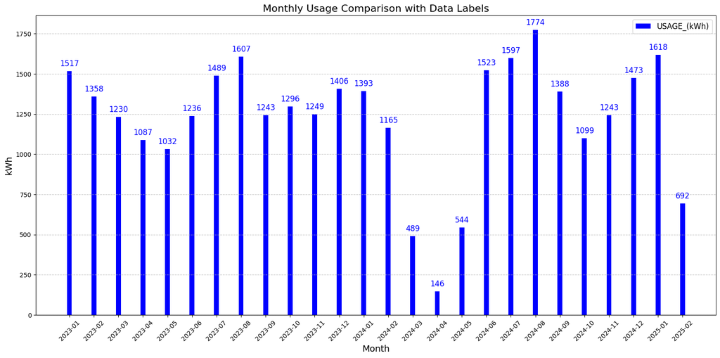

```python
# Aggregate data at the monthly level
electric_agg_updated['YearMonth'] = electric_agg_updated['date_timestamp'].dt.to_period('M')
monthly_data = electric_agg_updated.groupby('YearMonth')[['USAGE_(kWh)']].sum().reset_index()

# Convert 'YearMonth' back to datetime for plotting
monthly_data['YearMonth'] = monthly_data['YearMonth'].dt.to_timestamp()

# Define bar width and position with increased separation
bar_width = 0.5  # Wider bars
x = np.arange(len(monthly_data)) * 2.5  # Increase separation between bars

# Create the bar chart
plt.figure(figsize=(16, 8))

# Plot each dataset as a bar
bars1 = plt.bar(x, monthly_data['USAGE_(kWh)'], width=bar_width, label='USAGE_(kWh)', color='blue')

# Add data labels
for bar in bars1:
    height = bar.get_height()
    label_position = height + (20 if height > 0 else -20)  # Adjust label position for positive/negative values
    plt.text(
        bar.get_x() + bar.get_width() / 2,  # Center the label horizontally
        label_position,  # Position the label just above the bar
        f"{int(height)}",  # Convert height to an integer label
        ha='center', va='bottom' if height > 0 else 'top', fontsize=12, color='blue'
    )

# Customize the chart
plt.xticks(x, monthly_data['YearMonth'].dt.strftime('%Y-%m'), rotation=45)
plt.xlabel('Month', fontsize=14)
plt.ylabel('kWh', fontsize=14)
plt.title('Monthly Usage Comparison with Data Labels', fontsize=16)
plt.legend(fontsize=12)
plt.grid(axis='y', linestyle='--', alpha=0.7)
plt.tight_layout()

# Show the chart
plt.show()
```

### March, April, and May 2024 have odd Usage numbers that do not make sense.

- The numbers match what is coming from the electric company export and solar company for production
- The numbers do not match what happened with billing but most are close with the exception of March April and May 2024
- I am going to fill in 2023 numbers to populate 2025 forward and leave 2024 the same.

### Plot the net usage from the electric company and compare it to the net usage derived from solar edge.

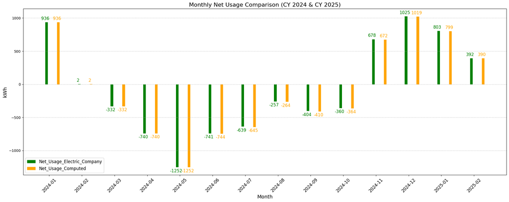

```python
# Filter data for CY 2024 and CY 2025
electric_agg_updated['YearMonth'] = electric_agg_updated['date_timestamp'].dt.to_period('M')
filtered_data = electric_agg_updated[
    electric_agg_updated['date_timestamp'] >= pd.Timestamp('2024-01-01')
].groupby('YearMonth')[['Net_Usage_Electric_Company', 'Net_Usage_Computed']].sum().reset_index()

# Convert 'YearMonth' back to datetime for plotting
filtered_data['YearMonth'] = filtered_data['YearMonth'].dt.to_timestamp()

# Define bar width and horizontal spacing
bar_width = 0.4
x = np.arange(len(filtered_data)) * 5  # Large separation between groups for readability

# Create the bar chart
plt.figure(figsize=(20, 8))

# Plot each dataset as a bar with more horizontal spacing
bars1 = plt.bar(
    x - bar_width,
    filtered_data['Net_Usage_Electric_Company'],
    width=bar_width,
    label='Net_Usage_Electric_Company',
    color='green'
)
bars2 = plt.bar(
    x + bar_width +1,
    filtered_data['Net_Usage_Computed'],
    width=bar_width,
    label='Net_Usage_Computed',
    color='orange'
)

# Add data labels near the bars with horizontal separation
for bars, color in zip([bars1, bars2], ['green', 'orange']):
    for bar in bars:
        height = bar.get_height()
        label_position = height + (20 if height > 0 else -20)  # Place labels near the bar
        plt.text(
            bar.get_x(),  # Keep labels close to the bar horizontally
            label_position,  # Adjust label placement for positive/negative values
            f"{int(height)}",  # Convert height to an integer label
            ha='center',
            va='bottom' if height > 0 else 'top',
            fontsize=12,
            color=color
        )

# Customize the chart
plt.xticks(x, filtered_data['YearMonth'].dt.strftime('%Y-%m'), rotation=45, fontsize=12)
plt.xlabel('Month', fontsize=14)
plt.ylabel('kWh', fontsize=14)
plt.title('Monthly Net Usage Comparison (CY 2024 & CY 2025)', fontsize=16)
plt.legend(fontsize=12)
plt.grid(axis='y', linestyle='--', alpha=0.7)
plt.tight_layout()

# Show the chart
plt.show()
```

```python
# Calculate descriptive statistics for cost_per_kWh and Net_Cost_per_kWh
descriptives = electric_agg_updated[['cost_per_kWh', 'Net_Cost_per_kWh']].describe()

# Display the results
print(descriptives)
```

```
       cost_per_kWh  Net_Cost_per_kWh
count  18615.000000      18615.000000
mean       0.135673          0.133492
std        0.057435          0.902204
min        0.000000        -52.000000
25%        0.119403          0.118812
50%        0.133929          0.133333
75%        0.149701          0.149449
max        1.246575         77.000000
```

```python
electric_agg_updated.info(verbose=True)
```

```
<class 'pandas.core.frame.DataFrame'>
RangeIndex: 18622 entries, 0 to 18621
Data columns (total 17 columns):
 #   Column                      Non-Null Count  Dtype
---  ------                      --------------  -----
 0   DATE                        18622 non-null  datetime64[ns]
 1   hour                        18622 non-null  int64
 2   last_day_month              18622 non-null  datetime64[ns]
 3   USAGE_(kWh)                 18622 non-null  float64
 4   COST                        18622 non-null  float64
 5   ESTIMATED_USAGE             18622 non-null  float64
 6   date_timestamp              18622 non-null  datetime64[ns]
 7   Net_Cost_per_kWh            18615 non-null  float64
 8   cost_per_kWh                18615 non-null  float64
 9   Consumption                 9863 non-null   float64
 10  Production                  9863 non-null   float64
 11  Purchased                   9863 non-null   float64
 12  FeedIn                      9863 non-null   float64
 13  Net_Usage_SolarEdge         9863 non-null   float64
 14  Net_Usage_Computed          9686 non-null   float64
 15  Net_Usage_Electric_Company  9686 non-null   float64
 16  YearMonth                   18622 non-null  period[M]
dtypes: datetime64[ns](3), float64(12), int64(1), period[M](1)
memory usage: 2.4 MB
```

## These numbers don't match the electric bill.

- It is likely due to the billing month being defined differently than the calendar month
- Add a billing month analysis and replot

```python
# Create a billing month DataFrame
def create_billing_month_dataframe():
    data = {
        "Billing_Year": [
            2022, 2022, 2022, 2022, 2023, 2023, 2023, 2023, 2023, 2023, 2023, 2023,
            2023, 2023, 2023, 2023, 2024, 2024, 2024, 2024, 2024, 2024, 2024, 2024,
            2024, 2024, 2024
        ],
        "Billing_Year_Start": [
            "2022-05-01 00:00:00", "2022-05-01 00:00:00", "2022-05-01 00:00:00", "2022-05-01 00:00:00",
            "2023-04-27 00:00:00", "2023-04-27 00:00:00", "2023-04-27 00:00:00", "2023-04-27 00:00:00",
            "2023-04-27 00:00:00", "2023-04-27 00:00:00", "2023-04-27 00:00:00", "2023-04-27 00:00:00",
            "2023-04-27 00:00:00", "2023-04-27 00:00:00", "2023-04-27 00:00:00", "2023-04-27 00:00:00",
            "2024-05-01 00:00:00", "2024-05-01 00:00:00", "2024-05-01 00:00:00", "2024-05-01 00:00:00",
            "2024-05-01 00:00:00", "2024-05-01 00:00:00", "2024-05-01 00:00:00", "2024-05-01 00:00:00",
            "2024-05-01 00:00:00", "2024-05-01 00:00:00", "2024-05-01 00:00:00",
        ],
        "Billing_Month": [
            "January", "February", "March", "April",
            "May", "June", "July", "August",
            "September", "October", "November", "December",
            "January", "February", "March", "April",
            "May", "June", "July", "August",
            "September", "October", "November", "December",
            "January", "February", "March"
        ],
        "Billing_Month_Start": [
            "2022-12-29 00:00:00", "2023-01-30 00:00:00", "2023-02-28 00:00:00", "2023-03-29 00:00:00",
            "2023-04-27 00:00:00", "2023-05-26 00:00:00", "2023-06-27 00:00:00", "2023-07-27 00:00:00",
            "2023-08-25 00:00:00", "2023-09-26 00:00:00", "2023-10-25 00:00:00", "2023-11-27 00:00:00",
            "2023-12-28 00:00:00", "2024-01-29 00:00:00", "2024-03-05 00:00:00", "2024-04-02 00:00:00",
            "2024-05-01 00:00:00", "2024-05-31 00:00:00", "2024-07-01 00:00:00", "2024-07-31 00:00:00",
            "2024-08-29 00:00:00", "2024-09-30 00:00:00", "2024-10-29 00:00:00", "2024-11-26 00:00:00",
            "2024-12-30 00:00:00", "2025-01-29 00:00:00", "2024-03-03 00:00:00"
        ],
        "Billing_Month_End": [
            "2023-01-29 23:00:00", "2023-02-27 23:00:00", "2023-03-28 23:00:00", "2023-04-26 23:00:00",
            "2023-05-25 23:00:00", "2023-06-26 23:00:00", "2023-07-26 23:00:00", "2023-08-24 23:00:00",
            "2023-09-25 23:00:00", "2023-10-24 23:00:00", "2023-11-26 23:00:00", "2023-12-27 23:00:00",
            "2024-01-28 23:00:00", "2024-03-04 23:00:00", "2024-04-01 23:00:00", "2024-04-30 23:00:00",
            "2024-05-30 23:00:00", "2024-06-30 23:00:00", "2024-07-30 23:00:00", "2024-08-28 23:00:00",
            "2024-09-29 23:00:00", "2024-10-28 23:00:00", "2024-11-25 23:00:00", "2024-12-29 23:00:00",
            "2025-01-28 23:00:00", "2025-03-02 23:00:00", "2024-03-31 23:00:00"
        ]
    }

    # Convert columns to datetime and explicitly set the time to 00:00:00 where required
    data["Billing_Year_Start"] = pd.to_datetime(data["Billing_Year_Start"])
    data["Billing_Month_Start"] = pd.to_datetime(data["Billing_Month_Start"])
    data["Billing_Month_End"] = pd.to_datetime(data["Billing_Month_End"])  # Retain original times


    return pd.DataFrame(data)

# Create the billing month DataFrame
billing_month_df = create_billing_month_dataframe()

# Display the DataFrame
print(billing_month_df)
```

```
    Billing_Year Billing_Year_Start Billing_Month Billing_Month_Start  \
0           2022         2022-05-01       January          2022-12-29
1           2022         2022-05-01      February          2023-01-30
2           2022         2022-05-01         March          2023-02-28
3           2022         2022-05-01         April          2023-03-29
4           2023         2023-04-27           May          2023-04-27
5           2023         2023-04-27          June          2023-05-26
6           2023         2023-04-27          July          2023-06-27
7           2023         2023-04-27        August          2023-07-27
8           2023         2023-04-27     September          2023-08-25
9           2023         2023-04-27       October          2023-09-26
10          2023         2023-04-27      November          2023-10-25
11          2023         2023-04-27      December          2023-11-27
12          2023         2023-04-27       January          2023-12-28
13          2023         2023-04-27      February          2024-01-29
```

[output cut: 42 more lines]

### Merge billing_month_df into electric_agg_updated

```python
# Ensure the result DataFrame starts as a complete copy of electric_agg_updated
merged_df = electric_agg_updated.copy()

# Ensure billing_month_df has a 'Billing_Month' column (if it doesn't already)
if 'Billing_Month' not in billing_month_df.columns:
    billing_month_df['Billing_Month'] = billing_month_df['Billing_Month_Start'].dt.month_name()

# Loop through each row of billing_month_df to conditionally assign its values
for _, row in billing_month_df.iterrows():
    # Create a condition to check if date_timestamp falls within the billing range
    condition = (merged_df['date_timestamp'] >= row['Billing_Month_Start']) & \
                (merged_df['date_timestamp'] <= row['Billing_Month_End'])

    # Assign the values from billing_month_df to matching rows in merged_df
    merged_df.loc[condition, ['Billing_Year', 'Billing_Year_Start',
                              'Billing_Month_Start', 'Billing_Month_End', 'Billing_Month']] = \
        row[['Billing_Year', 'Billing_Year_Start',
             'Billing_Month_Start', 'Billing_Month_End', 'Billing_Month']].values

# Perform a left join to add the new billing information to electric_agg_updated
electric_agg_updated = pd.merge(
    electric_agg_updated,
    merged_df[['date_timestamp', 'Billing_Year', 'Billing_Year_Start',
               'Billing_Month_End', 'Billing_Month']],
    on='date_timestamp',
    how='left'
)
electric_agg_updated
```

|  | DATE | hour | last_day_month | USAGE_(kWh) | COST | ESTIMATED_USAGE | date_timestamp | Net_Cost_per_kWh | cost_per_kWh | Consumption | ... | Purchased | FeedIn | Net_Usage_SolarEdge | Net_Usage_Computed | Net_Usage_Electric_Company | YearMonth | Billing_Year | Billing_Year_Start | Billing_Month_End | Billing_Month |
| --- | --- | --- | --- | --- | --- | --- | --- | --- | --- | --- | --- | --- | --- | --- | --- | --- | --- | --- | --- | --- | --- |
| 0 | 2023-01-01 | 0 | 2023-01-31 | 1.460 | 0.00 | 0.0 | 2023-01-01 00:00:00 | 0.000000 | 0.000000 | NaN | ... | NaN | NaN | NaN | NaN | NaN | 2023-01 | 2022.0 | 2022-05-01 | 2023-01-29 23:00:00 | January |
| 1 | 2023-01-01 | 1 | 2023-01-31 | 1.520 | 0.00 | 0.0 | 2023-01-01 01:00:00 | 0.000000 | 0.000000 | NaN | ... | NaN | NaN | NaN | NaN | NaN | 2023-01 | 2022.0 | 2022-05-01 | 2023-01-29 23:00:00 | January |
| 2 | 2023-01-01 | 2 | 2023-01-31 | 1.140 | 0.00 | 0.0 | 2023-01-01 02:00:00 | 0.000000 | 0.000000 | NaN | ... | NaN | NaN | NaN | NaN | NaN | 2023-01 | 2022.0 | 2022-05-01 | 2023-01-29 23:00:00 | January |
| 3 | 2023-01-01 | 3 | 2023-01-31 | 1.640 | 0.00 | 0.0 | 2023-01-01 03:00:00 | 0.000000 | 0.000000 | NaN | ... | NaN | NaN | NaN | NaN | NaN | 2023-01 | 2022.0 | 2022-05-01 | 2023-01-29 23:00:00 | January |
| 4 | 2023-01-01 | 4 | 2023-01-31 | 2.740 | 0.00 | 0.0 | 2023-01-01 04:00:00 | 0.000000 | 0.000000 | NaN | ... | NaN | NaN | NaN | NaN | NaN | 2023-01 | 2022.0 | 2022-05-01 | 2023-01-29 23:00:00 | January |
| ... | ... | ... | ... | ... | ... | ... | ... | ... | ... | ... | ... | ... | ... | ... | ... | ... | ... | ... | ... | ... | ... |
| 18617 | 2025-02-14 | 19 | 2025-02-28 | 3.117 | 0.47 | 0.0 | 2025-02-14 19:00:00 | 0.143293 | 0.143293 | 3.117 | ... | 3.117 | 0.0 | 3.117 | 3.117 | 3.28 | 2025-02 | 2024.0 | 2024-05-01 | 2025-03-02 23:00:00 | February |
| 18618 | 2025-02-14 | 20 | 2025-02-28 | 2.657 | 0.36 | 0.0 | 2025-02-14 20:00:00 | 0.141176 | 0.141176 | 2.657 | ... | 2.657 | 0.0 | 2.657 | 2.657 | 2.55 | 2025-02 | 2024.0 | 2024-05-01 | 2025-03-02 23:00:00 | February |
| 18619 | 2025-02-14 | 21 | 2025-02-28 | 1.982 | 0.28 | 0.0 | 2025-02-14 21:00:00 | 0.142857 | 0.142857 | 1.982 | ... | 1.982 | 0.0 | 1.982 | 1.982 | 1.96 | 2025-02 | 2024.0 | 2024-05-01 | 2025-03-02 23:00:00 | February |
| 18620 | 2025-02-14 | 22 | 2025-02-28 | 1.377 | 0.19 | 0.0 | 2025-02-14 22:00:00 | 0.137681 | 0.137681 | 1.377 | ... | 1.377 | 0.0 | 1.377 | 1.377 | 1.38 | 2025-02 | 2024.0 | 2024-05-01 | 2025-03-02 23:00:00 | February |
| 18621 | 2025-02-14 | 23 | 2025-02-28 | 0.925 | 0.13 | 0.0 | 2025-02-14 23:00:00 | 0.139785 | 0.139785 | 0.925 | ... | 0.925 | 0.0 | 0.925 | 0.925 | 0.93 | 2025-02 | 2024.0 | 2024-05-01 | 2025-03-02 23:00:00 | February |

18622 rows × 21 columns

```python
# Define the target timestamp
target_date = pd.Timestamp('2024-04-15 00:00:00')

# Filter the DataFrame for the target date
result = electric_agg_updated.loc[electric_agg_updated['date_timestamp'] == target_date, ['date_timestamp', 'Billing_Year']]

# Display the result
print(result)
```

```
      date_timestamp  Billing_Year
11278     2024-04-15        2023.0
```

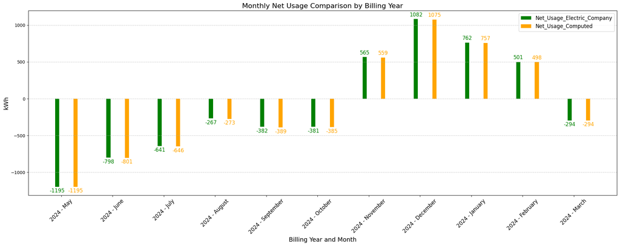

```python
def plot_billing_year_usage_comparison(electric_agg_updated):
    # Ensure 'Billing Year' is an integer
    electric_agg_updated['Billing_Year'] = electric_agg_updated['Billing_Year'].fillna(0).astype(int)

    # Filter data for Billing Years 2024 and 2025
    filtered_data = electric_agg_updated[
        electric_agg_updated['Billing_Year'].isin([2024, 2025])
    ].groupby(['Billing_Year', 'Billing_Month'])[
        ['Net_Usage_Electric_Company', 'Net_Usage_Computed']
    ].sum().reset_index()

    # Sort the data by Billing Year and Billing Month
    month_order = ["May", "June", "July", "August", "September", "October", "November", "December", "January", "February", "March", "April"]
    filtered_data['Billing_Month'] = pd.Categorical(filtered_data['Billing_Month'], categories=month_order, ordered=True)
    filtered_data = filtered_data.sort_values(['Billing_Year', 'Billing_Month']).reset_index(drop=True)

    # Define bar width and horizontal spacing
    bar_width = 0.4
    x = np.arange(len(filtered_data)) * 5  # Large separation between groups for readability

    # Create the bar chart
    plt.figure(figsize=(20, 8))

    # Plot each dataset as a bar with more horizontal spacing
    bars1 = plt.bar(
        x - bar_width,
        filtered_data['Net_Usage_Electric_Company'],
        width=bar_width,
        label='Net_Usage_Electric_Company',
        color='green'
    )
    bars2 = plt.bar(
        x + bar_width + 1,
        filtered_data['Net_Usage_Computed'],
        width=bar_width,
        label='Net_Usage_Computed',
        color='orange'
    )

    # Add data labels near the bars with horizontal separation
    for bars, color in zip([bars1, bars2], ['green', 'orange']):
        for bar in bars:
            height = bar.get_height()
            label_position = height + (20 if height > 0 else -20)  # Place labels near the bar
            plt.text(
                bar.get_x() + bar.get_width() / 2,  # Adjust for center alignment
                label_position,  # Adjust label placement for positive/negative values
                f"{int(height)}",  # Convert height to an integer label
                ha='center',
                va='bottom' if height > 0 else 'top',
                fontsize=12,
                color=color
            )

    # Customize the chart
    plt.xticks(
        x,
        [f"{int(row['Billing_Year'])} - {row['Billing_Month']}" for _, row in filtered_data.iterrows()],
        rotation=45,
        fontsize=12
    )
    plt.xlabel('Billing Year and Month', fontsize=14)
    plt.ylabel('kWh', fontsize=14)
    plt.title('Monthly Net Usage Comparison by Billing Year', fontsize=16)
    plt.legend(fontsize=12)
    plt.grid(axis='y', linestyle='--', alpha=0.7)
    plt.tight_layout()

    # Show the chart
    plt.show()

# Assuming electric_agg_updated is already defined
plot_billing_year_usage_comparison(electric_agg_updated)
```

```python
electric_agg_updated.info(verbose=True,show_counts=True)
```

```
<class 'pandas.core.frame.DataFrame'>
RangeIndex: 18622 entries, 0 to 18621
Data columns (total 21 columns):
 #   Column                      Non-Null Count  Dtype
---  ------                      --------------  -----
 0   DATE                        18622 non-null  datetime64[ns]
 1   hour                        18622 non-null  int64
 2   last_day_month              18622 non-null  datetime64[ns]
 3   USAGE_(kWh)                 18622 non-null  float64
 4   COST                        18622 non-null  float64
 5   ESTIMATED_USAGE             18622 non-null  float64
 6   date_timestamp              18622 non-null  datetime64[ns]
 7   Net_Cost_per_kWh            18615 non-null  float64
 8   cost_per_kWh                18615 non-null  float64
 9   Consumption                 9863 non-null   float64
 10  Production                  9863 non-null   float64
 11  Purchased                   9863 non-null   float64
 12  FeedIn                      9863 non-null   float64
 13  Net_Usage_SolarEdge         9863 non-null   float64
 14  Net_Usage_Computed          9686 non-null   float64
 15  Net_Usage_Electric_Company  9686 non-null   float64
 16  YearMonth                   18622 non-null  period[M]
 17  Billing_Year                18622 non-null  int64
 18  Billing_Year_Start          18622 non-null  datetime64[ns]
 19  Billing_Month_End           18622 non-null  datetime64[ns]
 20  Billing_Month               18622 non-null  object
dtypes: datetime64[ns](5), float64(12), int64(2), object(1), period[M](1)
memory usage: 3.0+ MB
```

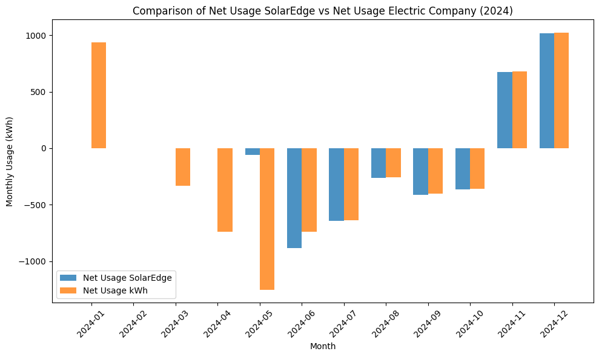

```python
# Filter data for the 2024 calendar year
data_2024 = electric_agg_updated[(electric_agg_updated['DATE'] >= '2024-01-01') & (electric_agg_updated['DATE'] <= '2024-12-31')]

# Extract year-month and aggregate the sums
monthly_data = data_2024.groupby(data_2024['DATE'].dt.to_period('M')).agg({
    'Net_Usage_SolarEdge': 'sum',
    'Net_Usage_Electric_Company': 'sum'
}).reset_index()

# Convert 'DATE' back to datetime for plotting
monthly_data['DATE'] = monthly_data['DATE'].dt.to_timestamp()

# Plot the bar chart
plt.figure(figsize=(10, 6))
bar_width = 0.35
x = range(len(monthly_data))

# Plot Net_Usage_SolarEdge
plt.bar(x, monthly_data['Net_Usage_SolarEdge'], width=bar_width, label='Net Usage SolarEdge', alpha=0.8)

# Plot Net_Usage_kWh
plt.bar([i + bar_width for i in x], monthly_data['Net_Usage_Electric_Company'], width=bar_width, label='Net Usage kWh', alpha=0.8)

# Customize the chart
plt.xticks([i + bar_width / 2 for i in x], monthly_data['DATE'].dt.strftime('%Y-%m'), rotation=45)
plt.ylabel('Monthly Usage (kWh)')
plt.xlabel('Month')
plt.title('Comparison of Net Usage SolarEdge vs Net Usage Electric Company (2024)')
plt.legend()
plt.tight_layout()

# Display the chart
plt.show()
```

```python
electric_agg_updated.drop(columns=['ESTIMATED_USAGE'], errors='ignore', inplace=True)
```

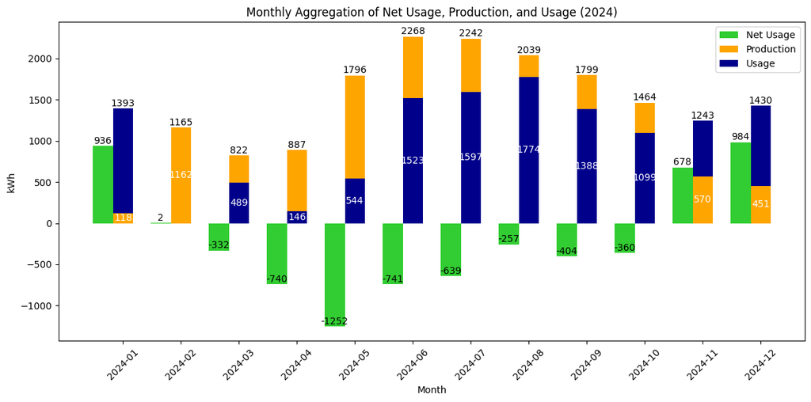

```python
# Filter data for the calendar year 2024
electric_agg_filtered = electric_agg_updated[
    (electric_agg_updated['date_timestamp'] >= '2024-01-01') &
    (electric_agg_updated['date_timestamp'] <= '2024-12-31')
]

# Aggregate monthly data for the required columns
monthly_agg = electric_agg_filtered.groupby(electric_agg_filtered['date_timestamp'].dt.to_period('M'))[
    ['Net_Usage_Electric_Company', 'Production', 'USAGE_(kWh)']
].sum()
monthly_agg.index = monthly_agg.index.to_timestamp()  # Convert PeriodIndex to datetime

# Create the bar positions
x = np.arange(len(monthly_agg))
bar_width = 0.35

# Create the bar chart
fig, ax = plt.subplots(figsize=(12, 6))

# Determine the bottom and top dynamically based on the smaller and larger values
bottom_values = np.minimum(monthly_agg['Production'], monthly_agg['USAGE_(kWh)'])
top_values = np.maximum(monthly_agg['Production'], monthly_agg['USAGE_(kWh)']) - bottom_values
bottom_label = monthly_agg['Production'] <= monthly_agg['USAGE_(kWh)']

# Plot the Net Usage as a separate bar
bars1 = ax.bar(x - bar_width, monthly_agg['Net_Usage_Electric_Company'],
               width=bar_width, label='Net Usage', color='limegreen')

# Plot the stacked bars, dynamically assigning the bottom and top colors
bars2 = ax.bar(x, bottom_values,
               width=bar_width,
               color=np.where(bottom_label, 'orange', 'darkblue'),
               label='Bottom')
bars3 = ax.bar(x, top_values,
               bottom=bottom_values,
               width=bar_width,
               color=np.where(bottom_label, 'darkblue', 'orange'),
               label='Top')

# Add data labels for Net Usage
for bar in bars1:
    height = bar.get_height()
    if height != 0:
        ax.text(
            bar.get_x() + bar.get_width() / 2,
            height + 2,
            f'{int(height)}',
            ha='center', va='bottom'
        )

# Add data labels for stacked bars
for bar2, bar3 in zip(bars2, bars3):
    production_height = bar2.get_height()
    usage_height = bar3.get_height() + production_height

    # Bottom label
    if production_height != 0:
        ax.text(
            bar2.get_x() + bar2.get_width() / 2,
            production_height / 2,
            f'{int(production_height)}',
            ha='center', va='center', color='white'
        )
    # Top label
    if usage_height != 0:
        ax.text(
            bar3.get_x() + bar3.get_width() / 2,
            usage_height + 2,
            f'{int(usage_height)}',
            ha='center', va='bottom'
        )

# Customize the chart
ax.set_xlabel('Month')
ax.set_ylabel('kWh')
ax.set_title('Monthly Aggregation of Net Usage, Production, and Usage (2024)')
ax.set_xticks(x)
ax.set_xticklabels(monthly_agg.index.strftime('%Y-%m'))
ax.legend(['Net Usage', 'Production', 'Usage'])

plt.xticks(rotation=45)
plt.tight_layout()
plt.show()
```

```python
electric_agg_updated = electric_agg_updated.drop(columns=['Consumption', 'Production', 'FeedIn', 'Purchased', 'Net_Usage_SolarEdge', 'YearMonth'])
```

```python
electric_agg_updated.info(verbose=True,show_counts=True)
```

```
<class 'pandas.core.frame.DataFrame'>
RangeIndex: 18622 entries, 0 to 18621
Data columns (total 14 columns):
 #   Column                      Non-Null Count  Dtype
---  ------                      --------------  -----
 0   DATE                        18622 non-null  datetime64[ns]
 1   hour                        18622 non-null  int64
 2   last_day_month              18622 non-null  datetime64[ns]
 3   USAGE_(kWh)                 18622 non-null  float64
 4   COST                        18622 non-null  float64
 5   date_timestamp              18622 non-null  datetime64[ns]
 6   Net_Cost_per_kWh            18615 non-null  float64
 7   cost_per_kWh                18615 non-null  float64
 8   Net_Usage_Computed          9686 non-null   float64
 9   Net_Usage_Electric_Company  9686 non-null   float64
 10  Billing_Year                18622 non-null  int64
 11  Billing_Year_Start          18622 non-null  datetime64[ns]
 12  Billing_Month_End           18622 non-null  datetime64[ns]
 13  Billing_Month               18622 non-null  object
dtypes: datetime64[ns](5), float64(6), int64(2), object(1)
memory usage: 2.0+ MB
```

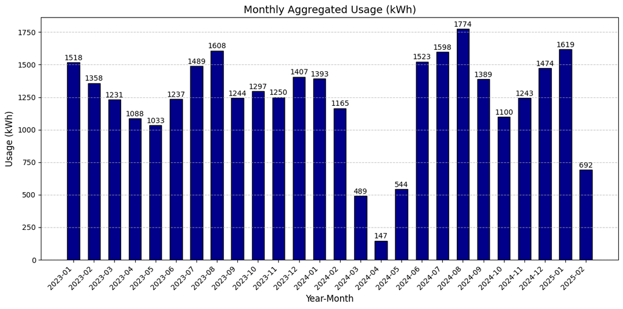

```python
# Ensure the 'DATE' column is in datetime format
electric_agg_updated['DATE'] = pd.to_datetime(electric_agg_updated['DATE'])

# Extract year and month from the 'DATE' column
electric_agg_updated['YearMonth'] = electric_agg_updated['DATE'].dt.to_period('M')

# Group by 'YearMonth' and aggregate the sum for 'USAGE_(kWh)'
monthly_agg = electric_agg_updated.groupby('YearMonth')['USAGE_(kWh)'].sum()

# Reset index for better readability
monthly_agg = monthly_agg.reset_index()



#Plot net usage from electric company.
# Create a bar chart with conditional coloring
plt.figure(figsize=(12, 6))

# Define colors based on positive or negative values
colors = ['darkblue' if value >= 0 else 'limegreen' for value in monthly_agg['USAGE_(kWh)']]

bars = plt.bar(
    monthly_agg['YearMonth'].astype(str),
    monthly_agg['USAGE_(kWh)'],
    width=0.6,
    color=colors,
    edgecolor='black'
)

# Add data labels on the outside end of each bar
for bar in bars:
    height = bar.get_height()
    # Adjust label position based on whether the bar is positive or negative
    label_position = height + (5 if height > 0 else -5)
    plt.text(
        bar.get_x() + bar.get_width() / 2,  # Horizontal position
        label_position,  # Vertical position
        f'{int(round(height))}',  # Label text without decimals
        ha='center', va='bottom' if height > 0 else 'top', fontsize=10
    )

# Add labels and title
plt.title('Monthly Aggregated Usage (kWh)', fontsize=14)
plt.xlabel('Year-Month', fontsize=12)
plt.ylabel('Usage (kWh)', fontsize=12)

# Rotate x-axis labels for better readability
plt.xticks(rotation=45, ha='right')

# Add grid for better readability
plt.grid(axis='y', linestyle='--', alpha=0.7)

# Show the chart
plt.tight_layout()
plt.show()
```

```python
# Define the filename for saving the updated electric data
file_path = "bi_electric_data.pkl"

# Save the updated electric DataFrame locally in GitHub Codespaces
electric_agg_updated.to_pickle(file_path)
print(f"✅ Updated electric data saved to {file_path}")

# Push the updated file to GitHub
os.system(f"git add {file_path}")
os.system('git commit -m "Updated electric data"')
os.system("git push origin main")

print("🚀 Updated electric data pushed to GitHub!")
```

[output not shown]

[output not shown]

### Future Electric

```python
# Define GitHub raw file URL
github_url = "https://raw.githubusercontent.com/AmyHumke12/SolarProject/main/bi_electric_data.pkl"

# Load the pickle file from GitHub
response = requests.get(github_url)

if response.status_code == 200:
    electric_agg = pickle.load(io.BytesIO(response.content))
    print("✅ Electric data loaded successfully.")
    print(electric_agg.head())  # Display first few rows
else:
    raise Exception(f"❌ Failed to load bi_electric_data.pkl. HTTP Status: {response.status_code}")
```

```
✅ Electric data loaded successfully.
        DATE  hour last_day_month  USAGE_(kWh)  COST      date_timestamp  \
0 2023-01-01     0     2023-01-31         1.46   0.0 2023-01-01 00:00:00
1 2023-01-01     1     2023-01-31         1.52   0.0 2023-01-01 01:00:00
2 2023-01-01     2     2023-01-31         1.14   0.0 2023-01-01 02:00:00
3 2023-01-01     3     2023-01-31         1.64   0.0 2023-01-01 03:00:00
4 2023-01-01     4     2023-01-31         2.74   0.0 2023-01-01 04:00:00

   Net_Cost_per_kWh  cost_per_kWh  Net_Usage_Computed  \
0               0.0           0.0                 NaN
1               0.0           0.0                 NaN
2               0.0           0.0                 NaN
3               0.0           0.0                 NaN
4               0.0           0.0                 NaN

   Net_Usage_Electric_Company  Billing_Year Billing_Year_Start  \
0                         NaN          2022         2022-05-01
1                         NaN          2022         2022-05-01
2                         NaN          2022         2022-05-01
3                         NaN          2022         2022-05-01
4                         NaN          2022         2022-05-01

    Billing_Month_End Billing_Month YearMonth
0 2023-01-29 23:00:00       January   2023-01
1 2023-01-29 23:00:00       January   2023-01
2 2023-01-29 23:00:00       January   2023-01
3 2023-01-29 23:00:00       January   2023-01
4 2023-01-29 23:00:00       January   2023-01
```

```python
# Define the end date to extend to
end_date = '2034-12-31 23:00:00'

# Get the last date from the DataFrame
last_timestamp = electric_agg['date_timestamp'].max()

# Create a date range starting from the next hour after the last_timestamp up to the end date
new_dates = pd.date_range(start=last_timestamp + pd.Timedelta(hours=1),
                          end=end_date, freq='h')

# Create new DataFrame with the necessary columns
new_data = pd.DataFrame({
    'date_timestamp': new_dates,
    'DATE': new_dates.date,
    'hour': new_dates.hour,
    'last_day_month': new_dates + pd.offsets.MonthEnd(0),
    'USAGE_(kWh)': 0,  # or fill with NaN or some placeholder if needed
    'COST': 0,  # or fill with NaN or some placeholder if needed
    'Net_Cost_per_kWh': 0,  # or fill with NaN or some placeholder if needed
    'cost_per_kWh': 0,  # or fill with NaN or some placeholder if needed
    'Net_Usage_Electric_Company': 0  # or fill with NaN or some placeholder if needed
})

# Append the new data to the existing DataFrame
electric_agg_extended = pd.concat([electric_agg, new_data], ignore_index=True)

# Display or save the extended DataFrame
print(electric_agg_extended)
```

```
                       DATE  hour      last_day_month  USAGE_(kWh)  COST  \
0       2023-01-01 00:00:00     0 2023-01-31 00:00:00         1.46   0.0
1       2023-01-01 00:00:00     1 2023-01-31 00:00:00         1.52   0.0
2       2023-01-01 00:00:00     2 2023-01-31 00:00:00         1.14   0.0
3       2023-01-01 00:00:00     3 2023-01-31 00:00:00         1.64   0.0
4       2023-01-01 00:00:00     4 2023-01-31 00:00:00         2.74   0.0
...                     ...   ...                 ...          ...   ...
105185           2034-12-31    19 2034-12-31 19:00:00         0.00   0.0
105186           2034-12-31    20 2034-12-31 20:00:00         0.00   0.0
105187           2034-12-31    21 2034-12-31 21:00:00         0.00   0.0
105188           2034-12-31    22 2034-12-31 22:00:00         0.00   0.0
105189           2034-12-31    23 2034-12-31 23:00:00         0.00   0.0

            date_timestamp  Net_Cost_per_kWh  cost_per_kWh  \
0      2023-01-01 00:00:00               0.0           0.0
```

[output cut: 38 more lines]

```python
#DATE and ESTIMATED_USAGE are not needed
columns_to_drop = ['DATE']

final_electric_agg = electric_agg_extended.drop(columns=columns_to_drop, errors='ignore')
final_electric_agg.info(verbose=True,show_counts=True)
```

```
<class 'pandas.core.frame.DataFrame'>
RangeIndex: 105190 entries, 0 to 105189
Data columns (total 14 columns):
 #   Column                      Non-Null Count   Dtype
---  ------                      --------------   -----
 0   hour                        105190 non-null  int64
 1   last_day_month              105190 non-null  datetime64[ns]
 2   USAGE_(kWh)                 105190 non-null  float64
 3   COST                        105190 non-null  float64
 4   date_timestamp              105190 non-null  datetime64[ns]
 5   Net_Cost_per_kWh            105183 non-null  float64
 6   cost_per_kWh                105183 non-null  float64
 7   Net_Usage_Computed          9686 non-null    float64
 8   Net_Usage_Electric_Company  96254 non-null   float64
 9   Billing_Year                18622 non-null   float64
 10  Billing_Year_Start          18622 non-null   datetime64[ns]
 11  Billing_Month_End           18622 non-null   datetime64[ns]
 12  Billing_Month               18622 non-null   object
 13  YearMonth                   18622 non-null   period[M]
dtypes: datetime64[ns](4), float64(7), int64(1), object(1), period[M](1)
memory usage: 11.2+ MB
```

```python
# Calculate descriptive statistics for cost_per_kWh and Net_Cost_per_kWh
descriptives = final_electric_agg[['cost_per_kWh', 'Net_Cost_per_kWh']].describe()

# Display the results
print(descriptives)
```

```
        cost_per_kWh  Net_Cost_per_kWh
count  105183.000000     105183.000000
mean        0.024011          0.023625
std         0.057140          0.382941
min         0.000000        -52.000000
25%         0.000000          0.000000
50%         0.000000          0.000000
75%         0.000000          0.000000
max         1.246575         77.000000
```

```python
# Define GitHub raw file URL
github_url = "https://raw.githubusercontent.com/AmyHumke12/SolarProject/main/bi_solaredge_data_process.pkl"

# Load the pickle file from GitHub
response = requests.get(github_url)

if response.status_code == 200:
    solaredge_df2 = pickle.load(io.BytesIO(response.content))
    print("✅ Processed SolarEdge data loaded successfully.")
    print(solaredge_df2.head())  # Display first few rows
else:
    raise Exception(f"❌ Failed to load bi_solaredge_data_process.pkl. HTTP Status: {response.status_code}")
```

```
✅ Processed SolarEdge data loaded successfully.
                 date   meter_type  value           date_meter_combination
0 2024-01-01 00:00:00  Consumption    NaN  2024-01-01 00:00:00_Consumption
1 2024-01-01 00:00:00       FeedIn    NaN       2024-01-01 00:00:00_FeedIn
2 2024-01-01 00:00:00   Production    NaN   2024-01-01 00:00:00_Production
3 2024-01-01 00:00:00    Purchased    NaN    2024-01-01 00:00:00_Purchased
4 2024-01-01 01:00:00  Consumption    NaN  2024-01-01 01:00:00_Consumption
```

### Merge the electric data in with the Solar Edge data.

```python
#Create a pivoted solar edge dataframe.
# Ensure the 'hour' column exists in solaredge_df2
solaredge_df2['hour'] = solaredge_df2['date'].dt.hour

# Pivot the DataFrame without filling missing values
pivoted_solaredge_df2 = solaredge_df2.pivot_table(
    index=['date', 'hour'],              # Group by date and hour
    columns='meter_type',                # Use meter_type as columns
    values='value',                      # Pivot values are from 'value' column
    aggfunc='min'                        # Aggregate duplicate entries using min
).reset_index()                          # Flatten the DataFrame

# Ensure missing values remain as NaN
pivoted_solaredge_df2.rename_axis(None, axis=1, inplace=True)  # Remove axis name

# Rename columns for clarity
pivoted_solaredge_df2.rename_axis(None, axis=1, inplace=True)  # Remove axis name
pivoted_solaredge_df2.rename(columns={'date': 'date'}, inplace=True)  # Ensure clear column names

# Debug: Inspect the pivoted DataFrame
print("Pivoted SolarEdge DataFrame:")
print(pivoted_solaredge_df2.head())

# Check for duplicates (sanity check after pivoting)
duplicates = pivoted_solaredge_df2.duplicated(subset=['date', 'hour'], keep=False)
if duplicates.any():
    print("Duplicates in pivoted_solaredge_df2:")
    print(pivoted_solaredge_df2[duplicates])
else:
    print("No duplicates found in pivoted SolarEdge DataFrame.")
```

```
Pivoted SolarEdge DataFrame:
                 date  hour  Consumption  FeedIn  Production  Purchased
0 2024-01-08 09:00:00     9          NaN     NaN       0.072        NaN
1 2024-01-08 10:00:00    10          NaN     NaN       0.285        NaN
2 2024-01-08 11:00:00    11          NaN     NaN       0.251        NaN
3 2024-01-08 12:00:00    12          NaN     NaN       0.782        NaN
4 2024-01-08 13:00:00    13          NaN     NaN       0.491        NaN
No duplicates found in pivoted SolarEdge DataFrame.
```

```python
# Check for duplicates in pivoted_solaredge_df2
duplicates_solaredge = pivoted_solaredge_df2.duplicated(subset=['date', 'hour'], keep=False)
if duplicates_solaredge.any():
    print("Duplicates in pivoted_solaredge_df2:")
    print(pivoted_solaredge_df2[duplicates_solaredge])
else:
    print("No duplicates in pivoted_solaredge_df2.")

# Check for duplicates in final_electric_agg
duplicates_electric = final_electric_agg.duplicated(subset=['date_timestamp', 'hour'], keep=False)
if duplicates_electric.any():
    print("Duplicates in final_electric_agg:")
    print(final_electric_agg[duplicates_electric])
else:
    print("No duplicates in final_electric_agg.")
```

```
No duplicates in pivoted_solaredge_df2.
No duplicates in final_electric_agg.
```

```python
# Ensure datetime consistency
final_electric_agg['date_timestamp'] = pd.to_datetime(final_electric_agg['date_timestamp'])
pivoted_solaredge_df2['date'] = pd.to_datetime(pivoted_solaredge_df2['date'])

# Merge the DataFrames
merged_final_electric_agg = pd.merge(
    final_electric_agg,
    pivoted_solaredge_df2,
    how='left',
    left_on=['date_timestamp', 'hour'],
    right_on=['date', 'hour'],
    suffixes=('', '_solaredge')
)

# Drop redundant columns
merged_final_electric_agg.drop(columns=['date'], inplace=True)

# Check merged DataFrame
print("Merged DataFrame Sample:")
print(merged_final_electric_agg.head())
```

```
Merged DataFrame Sample:
   hour last_day_month  USAGE_(kWh)  COST      date_timestamp  \
0     0     2023-01-31         1.46   0.0 2023-01-01 00:00:00
1     1     2023-01-31         1.52   0.0 2023-01-01 01:00:00
2     2     2023-01-31         1.14   0.0 2023-01-01 02:00:00
3     3     2023-01-31         1.64   0.0 2023-01-01 03:00:00
4     4     2023-01-31         2.74   0.0 2023-01-01 04:00:00

   Net_Cost_per_kWh  cost_per_kWh  Net_Usage_Computed  \
0               0.0           0.0                 NaN
1               0.0           0.0                 NaN
2               0.0           0.0                 NaN
3               0.0           0.0                 NaN
4               0.0           0.0                 NaN

```

[output cut: 20 more lines]

```python
merged_final_electric_agg.info(verbose=True)
```

```
<class 'pandas.core.frame.DataFrame'>
RangeIndex: 105190 entries, 0 to 105189
Data columns (total 18 columns):
 #   Column                      Non-Null Count   Dtype
---  ------                      --------------   -----
 0   hour                        105190 non-null  int64
 1   last_day_month              105190 non-null  datetime64[ns]
 2   USAGE_(kWh)                 105190 non-null  float64
 3   COST                        105190 non-null  float64
 4   date_timestamp              105190 non-null  datetime64[ns]
 5   Net_Cost_per_kWh            105183 non-null  float64
 6   cost_per_kWh                105183 non-null  float64
 7   Net_Usage_Computed          9686 non-null    float64
 8   Net_Usage_Electric_Company  96254 non-null   float64
 9   Billing_Year                18622 non-null   float64
 10  Billing_Year_Start          18622 non-null   datetime64[ns]
 11  Billing_Month_End           18622 non-null   datetime64[ns]
 12  Billing_Month               18622 non-null   object
 13  YearMonth                   18622 non-null   period[M]
 14  Consumption                 6374 non-null    float64
 15  FeedIn                      6374 non-null    float64
 16  Production                  9830 non-null    float64
 17  Purchased                   6374 non-null    float64
dtypes: datetime64[ns](4), float64(11), int64(1), object(1), period[M](1)
memory usage: 14.4+ MB
```

### Check the usage and consumption

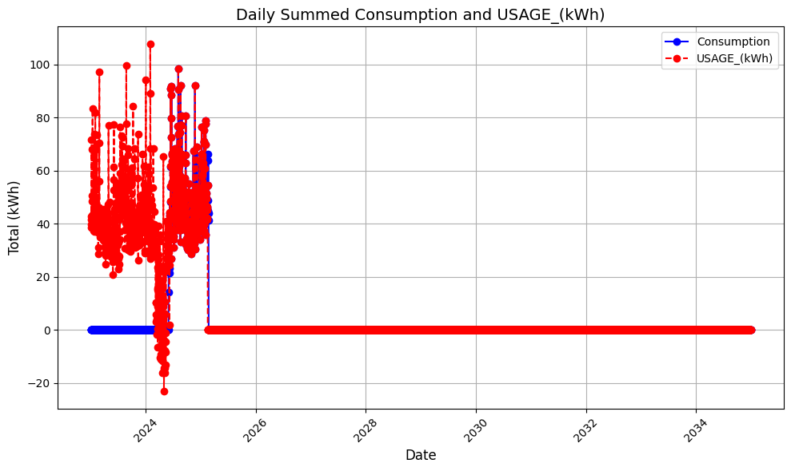

```python
# Step 1: Resample the data by month and sum the 'Consumption' and 'USAGE_(kWh)'
daily_consumption = merged_final_electric_agg.resample('d', on='date_timestamp')['Consumption'].sum()
daily_usage = merged_final_electric_agg.resample('d', on='date_timestamp')['USAGE_(kWh)'].sum()

# Step 2: Plot both the daily summed consumption and usage
plt.figure(figsize=(10, 6))

# Plot for 'Consumption'
plt.plot(daily_consumption.index, daily_consumption.values, marker='o', linestyle='-', color='b', label='Consumption')

# Plot for 'USAGE_(kWh)'
plt.plot(daily_usage.index, daily_usage.values, marker='o', linestyle='--', color='r', label='USAGE_(kWh)')

# Adding titles and labels
plt.title('Daily Summed Consumption and USAGE_(kWh)', fontsize=14)
plt.xlabel('Date', fontsize=12)
plt.ylabel('Total (kWh)', fontsize=12)

# Adding a legend
plt.legend()

# Display the plot
plt.grid(True)
plt.xticks(rotation=45)
plt.tight_layout()
plt.show()
```

```python
# Step 1: Identify the maximum actual date from the SolarEdge data
max_actual_date = solaredge_process.loc[
    (solaredge_process['meter_type'] == 'Consumption') & (solaredge_process['value'].notna()), 'date'
].max()
print(max_actual_date)
# Step 2: Create the 'Consumption_Status' field
merged_final_electric_agg['Consumption_Status'] = merged_final_electric_agg.apply(
    lambda row: 'estimated' if (pd.Timestamp('2024-01-01') <= row['date_timestamp'] <= max_actual_date) else
                ('future' if row['date_timestamp'] > max_actual_date else 'actual'),
    axis=1
)

# Display the first few rows to verify
print(merged_final_electric_agg[['date_timestamp', 'Consumption', 'Consumption_Status']].tail())
```

```
2025-02-20 23:00:00
            date_timestamp  Consumption Consumption_Status
105185 2034-12-31 19:00:00          NaN             future
105186 2034-12-31 20:00:00          NaN             future
105187 2034-12-31 21:00:00          NaN             future
105188 2034-12-31 22:00:00          NaN             future
105189 2034-12-31 23:00:00          NaN             future
```

```python
# Check for duplicate 'date_timestamp' values
duplicate_timestamps = merged_final_electric_agg[merged_final_electric_agg.duplicated(subset=['date_timestamp'], keep=False)]

# Display the duplicate rows
if not duplicate_timestamps.empty:
    print("Duplicate date_timestamp values found:")
    print(duplicate_timestamps)
else:
    print("No duplicate date_timestamp values found.")
```

```
No duplicate date_timestamp values found.
```

```python
# Calculate the Solaredge_Update_Date based on the max date for Consumption with non-NA values
solaredge_update_date = solaredge_process.loc[
    (solaredge_process['meter_type'] == 'Consumption') & (solaredge_process['value'].notna()), 'date'
].max()

# Add the calculated Solaredge_Update_Date as a new column to merged_final_electric_agg
merged_final_electric_agg['Solaredge_Update_Date'] = solaredge_update_date

# Display a few rows to verify the addition
print(merged_final_electric_agg[['date_timestamp', 'Solaredge_Update_Date']].head())
```

```
       date_timestamp Solaredge_Update_Date
0 2023-01-01 00:00:00   2025-02-20 23:00:00
1 2023-01-01 01:00:00   2025-02-20 23:00:00
2 2023-01-01 02:00:00   2025-02-20 23:00:00
3 2023-01-01 03:00:00   2025-02-20 23:00:00
4 2023-01-01 04:00:00   2025-02-20 23:00:00
```

```python
merged_final_electric_agg.info(verbose=True)
```

```
<class 'pandas.core.frame.DataFrame'>
RangeIndex: 105190 entries, 0 to 105189
Data columns (total 20 columns):
 #   Column                      Non-Null Count   Dtype
---  ------                      --------------   -----
 0   hour                        105190 non-null  int64
 1   last_day_month              105190 non-null  datetime64[ns]
 2   USAGE_(kWh)                 105190 non-null  float64
 3   COST                        105190 non-null  float64
 4   date_timestamp              105190 non-null  datetime64[ns]
 5   Net_Cost_per_kWh            105183 non-null  float64
 6   cost_per_kWh                105183 non-null  float64
 7   Net_Usage_Computed          9686 non-null    float64
 8   Net_Usage_Electric_Company  96254 non-null   float64
 9   Billing_Year                18622 non-null   float64
 10  Billing_Year_Start          18622 non-null   datetime64[ns]
 11  Billing_Month_End           18622 non-null   datetime64[ns]
 12  Billing_Month               18622 non-null   object
 13  YearMonth                   18622 non-null   period[M]
 14  Consumption                 6374 non-null    float64
 15  FeedIn                      6374 non-null    float64
 16  Production                  9830 non-null    float64
 17  Purchased                   6374 non-null    float64
 18  Consumption_Status          105190 non-null  object
 19  Solaredge_Update_Date       105190 non-null  datetime64[ns]
dtypes: datetime64[ns](5), float64(11), int64(1), object(2), period[M](1)
memory usage: 16.1+ MB
```

```python
# Filter rows for the solar edge update date to make sure the last rows aren't coming in NaN
filtered_rows = merged_final_electric_agg.loc[
    merged_final_electric_agg['date_timestamp'].dt.date == merged_final_electric_agg['Solaredge_Update_Date'].dt.date,
    ['date_timestamp', 'Production', 'Consumption', 'FeedIn', 'Purchased']
]

# Display the filtered rows
print(filtered_rows)
```

```
           date_timestamp  Production  Consumption  FeedIn  Purchased
18742 2025-02-20 00:00:00       0.000        1.208   0.000      1.208
18743 2025-02-20 01:00:00       0.000        1.167   0.000      1.167
18744 2025-02-20 02:00:00       0.000        3.919   0.000      3.919
18745 2025-02-20 03:00:00       0.000        1.179   0.000      1.179
18746 2025-02-20 04:00:00       0.000        1.074   0.000      1.074
18747 2025-02-20 05:00:00       0.000        1.328   0.000      1.328
18748 2025-02-20 06:00:00       0.026        1.643   0.000      1.617
18749 2025-02-20 07:00:00       1.016        4.345   0.006      3.335
18750 2025-02-20 08:00:00       6.572        1.164   5.417      0.009
18751 2025-02-20 09:00:00       8.478        1.406   7.072      0.000
18752 2025-02-20 10:00:00       8.938        1.481   7.457      0.000
18753 2025-02-20 11:00:00       8.403        1.454   6.949      0.000
18754 2025-02-20 12:00:00       6.895        1.046   5.849      0.000
18755 2025-02-20 13:00:00       4.216        1.323   2.893      0.000
18756 2025-02-20 14:00:00       1.643        3.810   0.375      2.542
18757 2025-02-20 15:00:00       0.614        1.027   0.000      0.413
18758 2025-02-20 16:00:00       0.360        1.342   0.000      0.982
18759 2025-02-20 17:00:00       0.041        1.445   0.000      1.404
18760 2025-02-20 18:00:00       0.000        1.232   0.000      1.232
18761 2025-02-20 19:00:00       0.000        1.228   0.000      1.228
18762 2025-02-20 20:00:00       0.000        2.732   0.000      2.732
18763 2025-02-20 21:00:00       0.000        2.681   0.000      2.681
18764 2025-02-20 22:00:00       0.000        1.211   0.000      1.211
18765 2025-02-20 23:00:00       0.000        0.884   0.000      0.884
```

```python
merged_final_electric_agg.info(verbose=True,show_counts=True)
```

```
<class 'pandas.core.frame.DataFrame'>
RangeIndex: 105190 entries, 0 to 105189
Data columns (total 20 columns):
 #   Column                      Non-Null Count   Dtype
---  ------                      --------------   -----
 0   hour                        105190 non-null  int64
 1   last_day_month              105190 non-null  datetime64[ns]
 2   USAGE_(kWh)                 105190 non-null  float64
 3   COST                        105190 non-null  float64
 4   date_timestamp              105190 non-null  datetime64[ns]
 5   Net_Cost_per_kWh            105183 non-null  float64
 6   cost_per_kWh                105183 non-null  float64
 7   Net_Usage_Computed          9686 non-null    float64
 8   Net_Usage_Electric_Company  96254 non-null   float64
 9   Billing_Year                18622 non-null   float64
 10  Billing_Year_Start          18622 non-null   datetime64[ns]
 11  Billing_Month_End           18622 non-null   datetime64[ns]
 12  Billing_Month               18622 non-null   object
 13  YearMonth                   18622 non-null   period[M]
 14  Consumption                 6374 non-null    float64
 15  FeedIn                      6374 non-null    float64
 16  Production                  9830 non-null    float64
 17  Purchased                   6374 non-null    float64
 18  Consumption_Status          105190 non-null  object
 19  Solaredge_Update_Date       105190 non-null  datetime64[ns]
dtypes: datetime64[ns](5), float64(11), int64(1), object(2), period[M](1)
memory usage: 16.1+ MB
```

```python
# Make the Consumption equal to the usage (because usage was already earlier set to be from electric or consumption solar edge as appropriate).
merged_final_electric_agg['Consumption'] = merged_final_electric_agg['USAGE_(kWh)']

# Define the desired column order
desired_order = [
    'date_timestamp', 'YearMonth', 'last_day_month', 'hour', 'USAGE_(kWh)', 'Net_Usage_Electric_Company', 'COST',
    'cost_per_kWh', 'Net_Cost_per_kWh', 'Consumption', 'FeedIn', 'Production',
    'Purchased', 'Consumption_Status', 'Solaredge_Update_Date'
]

# Reorder the DataFrame columns
merged_final_electric_agg = merged_final_electric_agg[desired_order]

# Display the first few rows to verify the order
print(merged_final_electric_agg.head())
```

```
       date_timestamp YearMonth last_day_month  hour  USAGE_(kWh)  \
0 2023-01-01 00:00:00   2023-01     2023-01-31     0         1.46
1 2023-01-01 01:00:00   2023-01     2023-01-31     1         1.52
2 2023-01-01 02:00:00   2023-01     2023-01-31     2         1.14
3 2023-01-01 03:00:00   2023-01     2023-01-31     3         1.64
4 2023-01-01 04:00:00   2023-01     2023-01-31     4         2.74

   Net_Usage_Electric_Company  COST  cost_per_kWh  Net_Cost_per_kWh  \
0                         NaN   0.0           0.0               0.0
1                         NaN   0.0           0.0               0.0
2                         NaN   0.0           0.0               0.0
3                         NaN   0.0           0.0               0.0
4                         NaN   0.0           0.0               0.0

   Consumption  FeedIn  Production  Purchased Consumption_Status  \
0         1.46     NaN         NaN        NaN             actual
1         1.52     NaN         NaN        NaN             actual
2         1.14     NaN         NaN        NaN             actual
3         1.64     NaN         NaN        NaN             actual
4         2.74     NaN         NaN        NaN             actual

  Solaredge_Update_Date
0   2025-02-20 23:00:00
1   2025-02-20 23:00:00
2   2025-02-20 23:00:00
3   2025-02-20 23:00:00
4   2025-02-20 23:00:00
```

```python
# Capture the maximum date in the 'date_timestamp' column
max_date_timestamp = merged_final_electric_agg['date_timestamp'].max()

# Display the max date_timestamp
print("Max date_timestamp:", max_date_timestamp)
```

```
Max date_timestamp: 2034-12-31 23:00:00
```

```python
merged_final_electric_agg.info(verbose=True,show_counts=True)
```

```
<class 'pandas.core.frame.DataFrame'>
RangeIndex: 105190 entries, 0 to 105189
Data columns (total 15 columns):
 #   Column                      Non-Null Count   Dtype
---  ------                      --------------   -----
 0   date_timestamp              105190 non-null  datetime64[ns]
 1   YearMonth                   18622 non-null   period[M]
 2   last_day_month              105190 non-null  datetime64[ns]
 3   hour                        105190 non-null  int64
 4   USAGE_(kWh)                 105190 non-null  float64
 5   Net_Usage_Electric_Company  96254 non-null   float64
 6   COST                        105190 non-null  float64
 7   cost_per_kWh                105183 non-null  float64
 8   Net_Cost_per_kWh            105183 non-null  float64
 9   Consumption                 105190 non-null  float64
 10  FeedIn                      6374 non-null    float64
 11  Production                  9830 non-null    float64
 12  Purchased                   6374 non-null    float64
 13  Consumption_Status          105190 non-null  object
 14  Solaredge_Update_Date       105190 non-null  datetime64[ns]
dtypes: datetime64[ns](3), float64(9), int64(1), object(1), period[M](1)
memory usage: 12.0+ MB
```

```python
merged_final_electric_agg
```

|  | date_timestamp | YearMonth | last_day_month | hour | USAGE_(kWh) | Net_Usage_Electric_Company | COST | cost_per_kWh | Net_Cost_per_kWh | Consumption | FeedIn | Production | Purchased | Consumption_Status | Solaredge_Update_Date |
| --- | --- | --- | --- | --- | --- | --- | --- | --- | --- | --- | --- | --- | --- | --- | --- |
| 0 | 2023-01-01 00:00:00 | 2023-01 | 2023-01-31 00:00:00 | 0 | 1.46 | NaN | 0.0 | 0.0 | 0.0 | 1.46 | NaN | NaN | NaN | actual | 2025-02-20 23:00:00 |
| 1 | 2023-01-01 01:00:00 | 2023-01 | 2023-01-31 00:00:00 | 1 | 1.52 | NaN | 0.0 | 0.0 | 0.0 | 1.52 | NaN | NaN | NaN | actual | 2025-02-20 23:00:00 |
| 2 | 2023-01-01 02:00:00 | 2023-01 | 2023-01-31 00:00:00 | 2 | 1.14 | NaN | 0.0 | 0.0 | 0.0 | 1.14 | NaN | NaN | NaN | actual | 2025-02-20 23:00:00 |
| 3 | 2023-01-01 03:00:00 | 2023-01 | 2023-01-31 00:00:00 | 3 | 1.64 | NaN | 0.0 | 0.0 | 0.0 | 1.64 | NaN | NaN | NaN | actual | 2025-02-20 23:00:00 |
| 4 | 2023-01-01 04:00:00 | 2023-01 | 2023-01-31 00:00:00 | 4 | 2.74 | NaN | 0.0 | 0.0 | 0.0 | 2.74 | NaN | NaN | NaN | actual | 2025-02-20 23:00:00 |
| ... | ... | ... | ... | ... | ... | ... | ... | ... | ... | ... | ... | ... | ... | ... | ... |
| 105185 | 2034-12-31 19:00:00 | NaT | 2034-12-31 19:00:00 | 19 | 0.00 | 0.0 | 0.0 | 0.0 | 0.0 | 0.00 | NaN | NaN | NaN | future | 2025-02-20 23:00:00 |
| 105186 | 2034-12-31 20:00:00 | NaT | 2034-12-31 20:00:00 | 20 | 0.00 | 0.0 | 0.0 | 0.0 | 0.0 | 0.00 | NaN | NaN | NaN | future | 2025-02-20 23:00:00 |
| 105187 | 2034-12-31 21:00:00 | NaT | 2034-12-31 21:00:00 | 21 | 0.00 | 0.0 | 0.0 | 0.0 | 0.0 | 0.00 | NaN | NaN | NaN | future | 2025-02-20 23:00:00 |
| 105188 | 2034-12-31 22:00:00 | NaT | 2034-12-31 22:00:00 | 22 | 0.00 | 0.0 | 0.0 | 0.0 | 0.0 | 0.00 | NaN | NaN | NaN | future | 2025-02-20 23:00:00 |
| 105189 | 2034-12-31 23:00:00 | NaT | 2034-12-31 23:00:00 | 23 | 0.00 | 0.0 | 0.0 | 0.0 | 0.0 | 0.00 | NaN | NaN | NaN | future | 2025-02-20 23:00:00 |

105190 rows × 15 columns

# Add the future dates with Predicted_Usage

This code processes the merged_final_electric_agg and solaredge_df2 dataframes by ensuring their timestamp columns are in datetime format and extracting key temporal features like month, day, and hour. It calculates the average Consumption for the year 2023 grouped by month, day, and hour, using this grouped data to populate the Predicted_Usage column for future dates (i.e., dates beyond the maximum date in solaredge_df2). Finally, it merges the future date data with the calculated predictions and updates the original dataframe, cleaning up intermediate columns afterward.

```python
# Assuming 'date_timestamp' exists in merged_final_electric_agg
timestamp_col_merged = 'date_timestamp'

# The date column in solaredge_df2 is 'date'
timestamp_col_solaredge = 'date'

# Ensure the timestamp columns are in datetime format
merged_final_electric_agg[timestamp_col_merged] = pd.to_datetime(merged_final_electric_agg[timestamp_col_merged])
solaredge_df2[timestamp_col_solaredge] = pd.to_datetime(solaredge_df2[timestamp_col_solaredge])

# Get the maximum date from solaredge_df2
max_date = solaredge_df2[timestamp_col_solaredge].max()
print("Maximum date in solaredge_df2:", max_date)

# Create 'Predicted_Usage' column initialized with NaN
merged_final_electric_agg['Predicted_Usage'] = np.nan

# Extract month, day, and hour from the timestamp column
merged_final_electric_agg['month'] = merged_final_electric_agg[timestamp_col_merged].dt.month
merged_final_electric_agg['day'] = merged_final_electric_agg[timestamp_col_merged].dt.day
merged_final_electric_agg['hour'] = merged_final_electric_agg[timestamp_col_merged].dt.hour

# Adjust 'adj_day' for leap years (set 2/29 to 2/28)
merged_final_electric_agg['adj_day'] = merged_final_electric_agg['day']
leap_day_mask = (merged_final_electric_agg['month'] == 2) & (merged_final_electric_agg['day'] == 29)
merged_final_electric_agg.loc[leap_day_mask, 'adj_day'] = 28

# Filter data for the year 2023
data_2023 = merged_final_electric_agg[merged_final_electric_agg[timestamp_col_merged].dt.year == 2023].copy()

# Ensure the 'USAGE_(kWh)' column exists
usage_col = 'USAGE_(kWh)'  # Replace with actual column name if different

# Verify 'USAGE_(kWh)' column exists in data_2023
if usage_col not in data_2023.columns:
    raise KeyError(f"Column '{usage_col}' does not exist in data_2023.")

# Group by month, adjusted day, and hour, then calculate the mean USAGE_(kWh)
usage_df = data_2023.groupby(['month', 'adj_day', 'hour'])[usage_col].mean().reset_index()

# Rename 'USAGE_(kWh)' to 'Predicted_Usage' in preparation for the merge
usage_df.rename(columns={usage_col: 'Predicted_Usage'}, inplace=True)

# Debug: Check columns and data in usage_df
print("Columns in usage_df:", usage_df.columns.tolist())
print("First few rows of usage_df:")
print(usage_df.head())

# Identify future dates where prediction is needed
future_dates_mask = merged_final_electric_agg[timestamp_col_merged] > max_date

# Create a copy of future_dates to avoid SettingWithCopyWarning
future_dates = merged_final_electric_agg[future_dates_mask].copy()

# Drop 'Predicted_Usage' from future_dates to prevent column conflict
future_dates.drop(columns=['Predicted_Usage'], inplace=True)

# Ensure merge keys have consistent data types
for col in ['month', 'adj_day', 'hour']:
    future_dates[col] = future_dates[col].astype(int)
    usage_df[col] = usage_df[col].astype(int)

# Perform the merge
future_dates = future_dates.merge(usage_df, on=['month', 'adj_day', 'hour'], how='left')

# Debug: Check columns and data in future_dates after merge
print("Columns in future_dates after merge:", future_dates.columns.tolist())
print("First few rows of future_dates after merge:")
print(future_dates.head())

# Ensure 'Predicted_Usage' exists in future_dates
if 'Predicted_Usage' not in future_dates.columns:
    raise KeyError("'Predicted_Usage' column does not exist in future_dates after merge.")

# Update the 'Predicted_Usage' column in the original dataframe
merged_final_electric_agg.loc[future_dates_mask, 'Predicted_Usage'] = future_dates['Predicted_Usage'].values

# Clean up the auxiliary columns if no longer needed
merged_final_electric_agg.drop(['month', 'day', 'hour', 'adj_day'], axis=1, inplace=True)

# Debug: Verify the updated DataFrame
print("Updated merged_final_electric_agg with Predicted_Usage:")
print(merged_final_electric_agg.head())
```

```
Maximum date in solaredge_df2: 2025-02-20 23:00:00
Columns in usage_df: ['month', 'adj_day', 'hour', 'Predicted_Usage']
First few rows of usage_df:
   month  adj_day  hour  Predicted_Usage
0      1        1     0             1.46
1      1        1     1             1.52
2      1        1     2             1.14
3      1        1     3             1.64
4      1        1     4             2.74
Columns in future_dates after merge: ['date_timestamp', 'YearMonth', 'last_day_month', 'hour', 'USAGE_(kWh)', 'Net_Usage_Electric_Company', 'COST', 'cost_per_kWh', 'Net_Cost_per_kWh', 'Consumption', 'FeedIn', 'Production', 'Purchased', 'Consumption_Status', 'Solaredge_Update_Date', 'month', 'day', '…
First few rows of future_dates after merge:
       date_timestamp YearMonth      last_day_month  hour  USAGE_(kWh)  \
0 2025-02-21 00:00:00       NaT 2025-02-28 00:00:00     0          0.0
1 2025-02-21 01:00:00       NaT 2025-02-28 01:00:00     1          0.0
2 2025-02-21 02:00:00       NaT 2025-02-28 02:00:00     2          0.0
3 2025-02-21 03:00:00       NaT 2025-02-28 03:00:00     3          0.0
4 2025-02-21 04:00:00       NaT 2025-02-28 04:00:00     4          0.0

   Net_Usage_Electric_Company  COST  cost_per_kWh  Net_Cost_per_kWh  \
0                         0.0   0.0           0.0               0.0
1                         0.0   0.0           0.0               0.0
2                         0.0   0.0           0.0               0.0
3                         0.0   0.0           0.0               0.0
4                         0.0   0.0           0.0               0.0

   Consumption  FeedIn  Production  Purchased Consumption_Status  \
0          0.0     NaN         NaN        NaN             future
1          0.0     NaN         NaN        NaN             future
2          0.0     NaN         NaN        NaN             future
3          0.0     NaN         NaN        NaN             future
4          0.0     NaN         NaN        NaN             future

  Solaredge_Update_Date  month  day  adj_day  Predicted_Usage
0   2025-02-20 23:00:00      2   21       21             0.98
1   2025-02-20 23:00:00      2   21       21             3.31
2   2025-02-20 23:00:00      2   21       21             0.96
3   2025-02-20 23:00:00      2   21       21             0.83
4   2025-02-20 23:00:00      2   21       21             0.80
Updated merged_final_electric_agg with Predicted_Usage:
       date_timestamp YearMonth last_day_month  USAGE_(kWh)  \
```

[output cut: 11 more lines]

```
4                         NaN   0.0           0.0               0.0

   Consumption  FeedIn  Production  Purchased Consumption_Status  \
0         1.46     NaN         NaN        NaN             actual
1         1.52     NaN         NaN        NaN             actual
2         1.14     NaN         NaN        NaN             actual
3         1.64     NaN         NaN        NaN             actual
4         2.74     NaN         NaN        NaN             actual

  Solaredge_Update_Date  Predicted_Usage
0   2025-02-20 23:00:00              NaN
1   2025-02-20 23:00:00              NaN
2   2025-02-20 23:00:00              NaN
3   2025-02-20 23:00:00              NaN
4   2025-02-20 23:00:00              NaN
```

```python
# Recalculate 'YearMonth' based on the full range of 'date_timestamp'
merged_final_electric_agg['YearMonth'] = merged_final_electric_agg['date_timestamp'].dt.to_period('M')

# Verify the updated column
print("Updated YearMonth column:")
print(merged_final_electric_agg[['date_timestamp', 'YearMonth']].head())

# Ensure no truncation occurred
print("Date range in YearMonth after recalculation:")
print(merged_final_electric_agg['YearMonth'].min(), merged_final_electric_agg['YearMonth'].max())
```

```
Updated YearMonth column:
       date_timestamp YearMonth
0 2023-01-01 00:00:00   2023-01
1 2023-01-01 01:00:00   2023-01
2 2023-01-01 02:00:00   2023-01
3 2023-01-01 03:00:00   2023-01
4 2023-01-01 04:00:00   2023-01
Date range in YearMonth after recalculation:
2023-01 2034-12
```

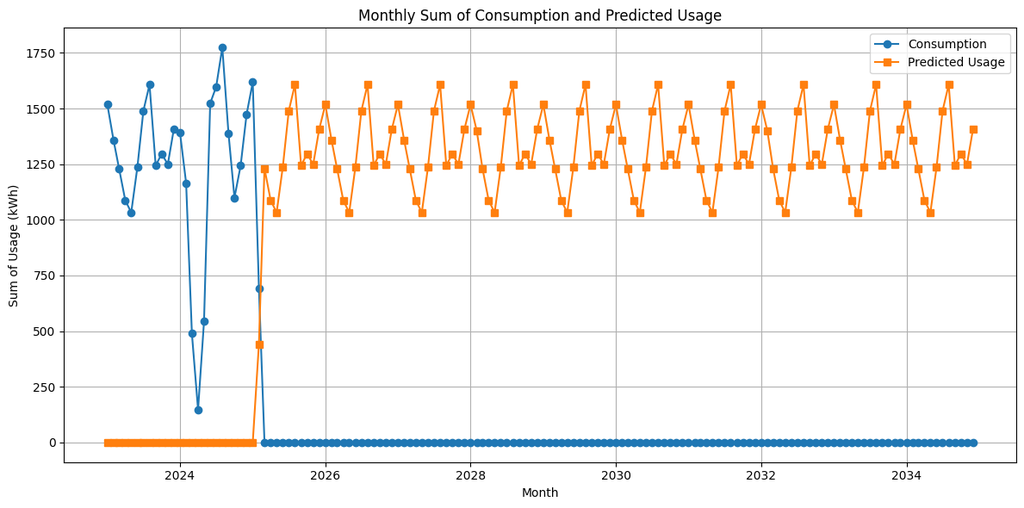

```python
# Group by 'YearMonth' and sum 'Consumption' and 'Predicted_Usage'
monthly_sums = merged_final_electric_agg.groupby('YearMonth')[['Consumption', 'Predicted_Usage']].sum().reset_index()

# Convert 'Year-Month' back to datetime for plotting
monthly_sums['YearMonth'] = monthly_sums['YearMonth'].dt.to_timestamp()

# Plotting
plt.figure(figsize=(12, 6))
plt.plot(monthly_sums['YearMonth'], monthly_sums['Consumption'], marker='o', label='Consumption')
plt.plot(monthly_sums['YearMonth'], monthly_sums['Predicted_Usage'], marker='s', label='Predicted Usage')
plt.xlabel('Month')
plt.ylabel('Sum of Usage (kWh)')
plt.title('Monthly Sum of Consumption and Predicted Usage')
plt.legend()
plt.grid(True)
plt.tight_layout()
plt.show()
```

```python
# Check for any NaN values in Predicted_Usage
nan_predicted_usage = merged_final_electric_agg[merged_final_electric_agg['Predicted_Usage'].isna()]
print(f"Rows with NaN Predicted Usage: {nan_predicted_usage.shape[0]}")
print(nan_predicted_usage[['date_timestamp', 'Predicted_Usage']].head())

# Check the statistics of the Predicted_Usage column
print(merged_final_electric_agg['Predicted_Usage'].describe())

# Check if there are zeros in the Predicted_Usage column
zero_predicted_usage = merged_final_electric_agg[merged_final_electric_agg['Predicted_Usage'] == 0]
print(f"Rows with zero Predicted Usage: {zero_predicted_usage.shape[0]}")
print(zero_predicted_usage[['date_timestamp', 'Predicted_Usage']].head())
```

```
Rows with NaN Predicted Usage: 18776
       date_timestamp  Predicted_Usage
0 2023-01-01 00:00:00              NaN
1 2023-01-01 01:00:00              NaN
2 2023-01-01 02:00:00              NaN
3 2023-01-01 03:00:00              NaN
4 2023-01-01 04:00:00              NaN
count    86414.000000
mean         1.796475
std          1.319079
min          0.450000
25%          1.000000
50%          1.270000
75%          2.080000
max         14.110000
Name: Predicted_Usage, dtype: float64
Rows with zero Predicted Usage: 0
Empty DataFrame
Columns: [date_timestamp, Predicted_Usage]
Index: []
```

```python
# Ensure 'date_timestamp' is in datetime format
final_electric_agg['date_timestamp'] = pd.to_datetime(final_electric_agg['date_timestamp'])

# Get the minimum and maximum dates
min_date = final_electric_agg['date_timestamp'].min()
max_date = final_electric_agg['date_timestamp'].max()

# Print the results
print(f"Minimum Date: {min_date}")
print(f"Maximum Date: {max_date}")
```

```
Minimum Date: 2023-01-01 00:00:00
Maximum Date: 2034-12-31 23:00:00
```

```python
merged_final_electric_agg.info(verbose=True,show_counts=True)
```

```
<class 'pandas.core.frame.DataFrame'>
RangeIndex: 105190 entries, 0 to 105189
Data columns (total 15 columns):
 #   Column                      Non-Null Count   Dtype
---  ------                      --------------   -----
 0   date_timestamp              105190 non-null  datetime64[ns]
 1   YearMonth                   105190 non-null  period[M]
 2   last_day_month              105190 non-null  datetime64[ns]
 3   USAGE_(kWh)                 105190 non-null  float64
 4   Net_Usage_Electric_Company  96254 non-null   float64
 5   COST                        105190 non-null  float64
 6   cost_per_kWh                105183 non-null  float64
 7   Net_Cost_per_kWh            105183 non-null  float64
 8   Consumption                 105190 non-null  float64
 9   FeedIn                      6374 non-null    float64
 10  Production                  9830 non-null    float64
 11  Purchased                   6374 non-null    float64
 12  Consumption_Status          105190 non-null  object
 13  Solaredge_Update_Date       105190 non-null  datetime64[ns]
 14  Predicted_Usage             86414 non-null   float64
dtypes: datetime64[ns](3), float64(10), object(1), period[M](1)
memory usage: 12.0+ MB
```

```python
# Calculate descriptive statistics for cost_per_kWh and Net_Cost_per_kWh
descriptives = merged_final_electric_agg[['cost_per_kWh', 'Net_Cost_per_kWh']].describe()

# Display the results
print(descriptives)
```

```
        cost_per_kWh  Net_Cost_per_kWh
count  105183.000000     105183.000000
mean        0.024011          0.023625
std         0.057140          0.382941
min         0.000000        -52.000000
25%         0.000000          0.000000
50%         0.000000          0.000000
75%         0.000000          0.000000
max         1.246575         77.000000
```

```python
# Filter for dates prior to 1/2/2025
filtered_data = final_electric_agg[final_electric_agg['date_timestamp'] < '2025-01-02']

# Calculate descriptive statistics for cost_per_kWh and Net_Cost_per_kWh
descriptives = filtered_data[['cost_per_kWh', 'Net_Cost_per_kWh']].describe()

# Display the results
print(descriptives)
```

```
       cost_per_kWh  Net_Cost_per_kWh
count  17560.000000      17560.000000
mean       0.135494          0.133175
std        0.059114          0.928903
min        0.000000        -52.000000
25%        0.118280          0.117647
50%        0.131313          0.130769
75%        0.150259          0.150000
max        1.246575         77.000000
```

```python
# Filter for dates prior to 1/2/2025
filtered_data = final_electric_agg[final_electric_agg['date_timestamp'] > '2025-01-02']

# Calculate descriptive statistics for cost_per_kWh and Net_Cost_per_kWh
descriptives = filtered_data[['cost_per_kWh', 'Net_Cost_per_kWh']].describe()

# Display the results
print(descriptives)
```

```
       cost_per_kWh  Net_Cost_per_kWh
count  87622.000000      87622.000000
mean       0.001668          0.001669
std        0.015127          0.015229
min        0.000000          0.000000
25%        0.000000          0.000000
50%        0.000000          0.000000
75%        0.000000          0.000000
max        0.166667          0.500000
```

```python
# Filter for dates prior to 1/1/2023
filtered_data = final_electric_agg[final_electric_agg['date_timestamp'] == '2023-01-01']

# Calculate descriptive statistics for cost_per_kWh and Net_Cost_per_kWh
descriptives = filtered_data[['cost_per_kWh', 'Net_Cost_per_kWh']].describe()

# Display the results
print(descriptives)
```

```
       cost_per_kWh  Net_Cost_per_kWh
count           1.0               1.0
mean            0.0               0.0
std             NaN               NaN
min             0.0               0.0
25%             0.0               0.0
50%             0.0               0.0
75%             0.0               0.0
max             0.0               0.0
```

## Add the best guess of what the billing month might be in the future.

- build on the already existing billing_month_df
- develop a function that will add a best guess of future billing dates up through 1/31/2035.
- billing months should be about 30-35 days
- the billing month should never start on Saturday, Sunday, or a US holiday
- the billing year starts in the May billing month

### Create future_billing_month_df

```python
from datetime import timedelta
import pandas as pd
import holidays

# Define US holidays
us_holidays = holidays.US()

# Initialize variables for generating future billing months
current_month_start = billing_month_df["Billing_Month_End"].max() + timedelta(hours=1)  # Start 1 hour after last end
future_billing_months = []

# Generate future billing months up to January 31, 2035
while current_month_start <= pd.Timestamp("2035-01-31"):
    # Ensure start date is not a weekend or US holiday
    while current_month_start.weekday() >= 5 or current_month_start in us_holidays:
        current_month_start += timedelta(days=1)  # Move to next day

    # Calculate an approximate end date (30-35 days later)
    next_month_start = current_month_start + timedelta(days=30)
    while next_month_start.weekday() >= 5 or next_month_start in us_holidays:
        next_month_start += timedelta(days=1)  # Move end to next valid day

    # Billing month ends 1 hour before the next month starts
    billing_month_end = next_month_start - timedelta(hours=1)

    # Determine the billing year
    # The billing year starts with May; months before May belong to the previous year
    if current_month_start.month >= 5:  # May or later belongs to the current year
        billing_year = current_month_start.year
    else:  # January, February, March, April belong to the previous year
        billing_year = current_month_start.year - 1

    # Get billing month name
    billing_month = current_month_start.strftime("%B")

    # Append to the future billing months list
    future_billing_months.append({
        "Billing_Year": billing_year,
        "Billing_Year_Start": pd.Timestamp(billing_year, 5, 1),  # May 1 of the billing year
        "Billing_Month_Start": current_month_start,
        "Billing_Month_Start_Day": current_month_start.strftime("%A"),  # Add start day of the week
        "Billing_Month_End": billing_month_end,
        "Billing_Month_End_Day": billing_month_end.strftime("%A"),      # Add end day of the week
        "Billing_Month": billing_month
    })

    # Move to the next billing month
    current_month_start = next_month_start

# Convert the future billing months list to a DataFrame
future_billing_months_df = pd.DataFrame(future_billing_months)

# Append to the original billing_month_df
future_billing_month_df = pd.concat([billing_month_df, future_billing_months_df], ignore_index=True)
```

```python
future_billing_month_df
```

|  | Billing_Year | Billing_Year_Start | Billing_Month | Billing_Month_Start | Billing_Month_End | Billing_Month_Start_Day | Billing_Month_End_Day |
| --- | --- | --- | --- | --- | --- | --- | --- |
| 0 | 2022 | 2022-05-01 | January | 2022-12-29 | 2023-01-29 23:00:00 | NaN | NaN |
| 1 | 2022 | 2022-05-01 | February | 2023-01-30 | 2023-02-27 23:00:00 | NaN | NaN |
| 2 | 2022 | 2022-05-01 | March | 2023-02-28 | 2023-03-28 23:00:00 | NaN | NaN |
| 3 | 2022 | 2022-05-01 | April | 2023-03-29 | 2023-04-26 23:00:00 | NaN | NaN |
| 4 | 2023 | 2023-04-27 | May | 2023-04-27 | 2023-05-25 23:00:00 | NaN | NaN |
| ... | ... | ... | ... | ... | ... | ... | ... |
| 141 | 2034 | 2034-05-01 | September | 2034-09-06 | 2034-10-05 23:00:00 | Wednesday | Thursday |
| 142 | 2034 | 2034-05-01 | October | 2034-10-06 | 2034-11-05 23:00:00 | Friday | Sunday |
| 143 | 2034 | 2034-05-01 | November | 2034-11-06 | 2034-12-05 23:00:00 | Monday | Tuesday |
| 144 | 2034 | 2034-05-01 | December | 2034-12-06 | 2035-01-04 23:00:00 | Wednesday | Thursday |
| 145 | 2034 | 2034-05-01 | January | 2035-01-05 | 2035-02-04 23:00:00 | Friday | Sunday |

146 rows × 7 columns

```python
# Define the target timestamp
target_date = pd.Timestamp('2024-04-30 23:00:00')

# Filter the DataFrame for the target date
result = future_billing_month_df.loc[future_billing_month_df['Billing_Month_End'] == target_date, ['Billing_Month_End', 'Billing_Year']]

# Display the result
print(result)
```

```
     Billing_Month_End  Billing_Year
15 2024-04-30 23:00:00          2023
```

#### Add future_billing_month_df to merged_final_electric_agg

```python
# Ensure the result DataFrame starts as a complete copy of merged_final_electric_agg
merged_df = merged_final_electric_agg.copy()

# Ensure future_billing_month_df has a 'Billing_Month' column
if 'Billing_Month' not in future_billing_month_df.columns:
    future_billing_month_df['Billing_Month'] = future_billing_month_df['Billing_Month_Start'].dt.month_name()

# Sort future_billing_month_df by Billing_Month_Start to ensure proper processing order
future_billing_month_df = future_billing_month_df.sort_values(by='Billing_Month_Start')

# Process each billing month row by row
for _, row in future_billing_month_df.iterrows():
    # Create a condition to check if date_timestamp falls within the billing range
    condition = (merged_df['date_timestamp'] >= row['Billing_Month_Start']) & \
                (merged_df['date_timestamp'] <= row['Billing_Month_End'])

    # Assign billing information only if the condition matches
    merged_df.loc[condition, ['Billing_Year', 'Billing_Year_Start',
                              'Billing_Month_Start', 'Billing_Month_End', 'Billing_Month']] = \
        row[['Billing_Year', 'Billing_Year_Start',
             'Billing_Month_Start', 'Billing_Month_End', 'Billing_Month']].values

# Perform a left join to add the new billing information to electric_agg_updated
merged_final_electric_agg_updated = pd.merge(
    merged_final_electric_agg,
    merged_df[['date_timestamp', 'Billing_Year', 'Billing_Year_Start', 'Billing_Month_Start',
               'Billing_Month_End', 'Billing_Month']],
    on='date_timestamp',
    how='left'
)
```

```python
# Convert Billing_Year to integers
merged_final_electric_agg_updated['Billing_Year'] = merged_final_electric_agg_updated['Billing_Year'].astype(int)
```

```python
merged_final_electric_agg_updated.info(verbose=True)
```

```
<class 'pandas.core.frame.DataFrame'>
RangeIndex: 105190 entries, 0 to 105189
Data columns (total 20 columns):
 #   Column                      Non-Null Count   Dtype
---  ------                      --------------   -----
 0   date_timestamp              105190 non-null  datetime64[ns]
 1   YearMonth                   105190 non-null  period[M]
 2   last_day_month              105190 non-null  datetime64[ns]
 3   USAGE_(kWh)                 105190 non-null  float64
 4   Net_Usage_Electric_Company  96254 non-null   float64
 5   COST                        105190 non-null  float64
 6   cost_per_kWh                105183 non-null  float64
 7   Net_Cost_per_kWh            105183 non-null  float64
 8   Consumption                 105190 non-null  float64
 9   FeedIn                      6374 non-null    float64
 10  Production                  9830 non-null    float64
 11  Purchased                   6374 non-null    float64
 12  Consumption_Status          105190 non-null  object
 13  Solaredge_Update_Date       105190 non-null  datetime64[ns]
 14  Predicted_Usage             86414 non-null   float64
 15  Billing_Year                105190 non-null  int64
 16  Billing_Year_Start          105190 non-null  datetime64[ns]
 17  Billing_Month_Start         105190 non-null  datetime64[ns]
 18  Billing_Month_End           105190 non-null  datetime64[ns]
 19  Billing_Month               105190 non-null  object
dtypes: datetime64[ns](6), float64(10), int64(1), object(2), period[M](1)
memory usage: 16.1+ MB
```

```python
# Define the target timestamp
target_date = pd.Timestamp('2024-04-15 00:00:00')

# Filter the DataFrame for the target date
result = merged_final_electric_agg_updated.loc[merged_final_electric_agg_updated['date_timestamp'] == target_date, ['date_timestamp', 'Billing_Year']]

# Display the result
print(result)
```

```
      date_timestamp  Billing_Year
11278     2024-04-15          2023
```

```python
# GitHub repository details
github_repo = "AmyHumke12/SolarProject"
github_branch = "main"
github_filename = "bi_electric_all_data_raw2.pkl"
local_filename = "bi_electric_all_data_raw2.pkl"

# Save the DataFrame locally
merged_final_electric_agg_updated.to_pickle(local_filename)
print("✅ Electric data saved locally.")

# GitHub API URL for file upload
github_api_url = f"https://api.github.com/repos/{github_repo}/contents/{github_filename}"

# Load the file and encode in Base64
with open(local_filename, "rb") as file:
    file_content = base64.b64encode(file.read()).decode("utf-8")

# Get GitHub token from environment variable
github_token = os.getenv("GIT")
if not github_token:
    raise ValueError("❌ GitHub Token is missing. Set the GITHUB_TOKEN environment variable.")

# Check if the file already exists to get its SHA
response = requests.get(github_api_url, headers={"Authorization": f"token {github_token}"})
if response.status_code == 200:
    sha = response.json().get("sha", None)
else:
    sha = None  # File does not exist yet

# Prepare payload for file upload
payload = {
    "message": "Updated electric data",
    "content": file_content,
    "branch": github_branch
}

if sha:
    payload["sha"] = sha  # Required for updating an existing file

# Make the request to upload the file
response = requests.put(github_api_url, headers={"Authorization": f"token {github_token}"}, data=json.dumps(payload))

# Check response
if response.status_code in [200, 201]:
    print("🚀 Electric data successfully uploaded to GitHub.")
else:
    print(f"❌ Failed to upload. Response: {response.json()}")
```

```
✅ Electric data saved locally.
🚀 Electric data successfully uploaded to GitHub.
```

# Part 2 Predict the production values

```python
# Define GitHub-friendly file paths
production_data_path = "bi_solaredge_data_process.pkl"
weather_data_path = "bi_weather_all_data_raw.pkl"
electric_data_path = "bi_electric_all_data_raw2.pkl"
solar_estimate_path = "solar_production_estimate.pkl"

# Load the production data from the pickle file
production_df = pd.read_pickle(production_data_path)
print(f"✅ Production data loaded from {production_data_path}")

# Load the weather data from the pickle file
weather_df = pd.read_pickle(weather_data_path)
print(f"✅ Weather data loaded from {weather_data_path}")

# Load the electric data from the pickle file
electric_df = pd.read_pickle(electric_data_path)
print(f"✅ Electric data loaded from {electric_data_path}")

# Load the area predicted values by month/hour dataframe
df_solar = pd.read_pickle(solar_estimate_path)
print(f"✅ Solar production estimates loaded from {solar_estimate_path}")
```

```
✅ Production data loaded from bi_solaredge_data_process.pkl
✅ Weather data loaded from bi_weather_all_data_raw.pkl
✅ Electric data loaded from bi_electric_all_data_raw2.pkl
✅ Solar production estimates loaded from solar_production_estimate.pkl
```

```python
# Filter the DataFrame where meter_type is 'Production' and value is not NaN
production_data = production_df[(production_df['meter_type'] == 'Production') & (production_df['value'].notna())]

# Ensure the 'date' column in production_df is in datetime format
production_df['date'] = pd.to_datetime(production_df['date'])

# Filter production_df where meter_type is "Production" (no date range limit)
filtered_production_df = production_df[production_df['meter_type'] == "Production"]

# Perform the left join, keeping all dates from weather_df
# Assuming 'weather_df' has the correct date field which was 'date_timestamp' in previous descriptions
merged_df = pd.merge(weather_df, filtered_production_df, left_on='date_timestamp', right_on='date', how='left')

# Display the structure and a sample of the merged DataFrame to verify the result
print(merged_df.info())
print(merged_df.head())
```

```
<class 'pandas.core.frame.DataFrame'>
RangeIndex: 113952 entries, 0 to 113951
Data columns (total 29 columns):
 #   Column                    Non-Null Count   Dtype
---  ------                    --------------   -----
 0   date_timestamp            113952 non-null  datetime64[ns]
 1   day_hour                  113952 non-null  object
 2   hour                      113952 non-null  float64
 3   temperature_2m            113952 non-null  float32
 4   relative_humidity_2m      113952 non-null  float32
 5   dew_point_2m              113952 non-null  float32
 6   precipitation             113952 non-null  float32
 7   snowfall                  113952 non-null  float32
 8   snow_depth                113441 non-null  float32
 9   cloud_cover               113952 non-null  float32
```

[output cut: 58 more lines]

```python
merged_df.info(verbose=True,show_counts=True)
```

```
<class 'pandas.core.frame.DataFrame'>
RangeIndex: 113952 entries, 0 to 113951
Data columns (total 29 columns):
 #   Column                    Non-Null Count   Dtype
---  ------                    --------------   -----
 0   date_timestamp            113952 non-null  datetime64[ns]
 1   day_hour                  113952 non-null  object
 2   hour                      113952 non-null  float64
 3   temperature_2m            113952 non-null  float32
 4   relative_humidity_2m      113952 non-null  float32
 5   dew_point_2m              113952 non-null  float32
 6   precipitation             113952 non-null  float32
 7   snowfall                  113952 non-null  float32
 8   snow_depth                113441 non-null  float32
 9   cloud_cover               113952 non-null  float32
```

[output cut: 21 more lines]

## Data Preprocessing

```python
# Find and display the row(s) with any null values
null_rows = merged_df[merged_df.isnull().any(axis=1)]


# Display the row with null values
print(null_rows)

#There is 1 NaN production value and that is happening when it is not daytime so that is ok since the analysis will be focused on day.
#There are NaN snow data. Those can be 0 filled because they happen in summer dates.
```

```
            date_timestamp  day_hour  hour  temperature_2m  \
0      2022-01-01 00:00:00  01-01 00   0.0       29.179399
1      2022-01-01 01:00:00  01-01 01   1.0       29.629400
2      2022-01-01 02:00:00  01-01 02   2.0       29.449400
3      2022-01-01 03:00:00  01-01 03   3.0       28.729401
4      2022-01-01 04:00:00  01-01 04   4.0       24.229401
...                    ...       ...   ...             ...
113947 2034-12-31 19:00:00  12-31 19  19.0       30.709400
113948 2034-12-31 20:00:00  12-31 20  20.0       30.619400
113949 2034-12-31 21:00:00  12-31 21  21.0       30.349400
113950 2034-12-31 22:00:00  12-31 22  22.0       30.439400
113951 2034-12-31 23:00:00  12-31 23  23.0       31.069401

        relative_humidity_2m  dew_point_2m  precipitation  snowfall  \
0                  92.888649     27.379400            0.0       0.0
```

[output cut: 64 more lines]

```python
merged_df.info(verbose=True,show_counts=True)
```

```
<class 'pandas.core.frame.DataFrame'>
RangeIndex: 113952 entries, 0 to 113951
Data columns (total 29 columns):
 #   Column                    Non-Null Count   Dtype
---  ------                    --------------   -----
 0   date_timestamp            113952 non-null  datetime64[ns]
 1   day_hour                  113952 non-null  object
 2   hour                      113952 non-null  float64
 3   temperature_2m            113952 non-null  float32
 4   relative_humidity_2m      113952 non-null  float32
 5   dew_point_2m              113952 non-null  float32
 6   precipitation             113952 non-null  float32
 7   snowfall                  113952 non-null  float32
 8   snow_depth                113441 non-null  float32
 9   cloud_cover               113952 non-null  float32
```

[output cut: 21 more lines]

```python
# Drop the 'date' and 'hour_y' columns from merged_df
merged_df.drop(columns=['date'], inplace=True, errors='ignore')
```

```python
# Replace NaN values in 'snow_depth' with 0 only for months between May (5) and October (10) inclusive
merged_df.loc[(merged_df['snow_depth'].isna()) & (merged_df['date_timestamp'].dt.month >= 5) & (merged_df['date_timestamp'].dt.month <= 10), 'snow_depth'] = 0

# Fill NaN values in 'value' with 0 where 'is_daylight' is 0
merged_df.loc[(merged_df['is_daylight'] == 0) & (merged_df['value'].isnull()), 'value'] = 0

# Add month and day number fields.
# Ensure the 'date' column is in datetime format (assuming you meant to convert 'date_x' here)
merged_df['date_timestamp'] = pd.to_datetime(merged_df['date_timestamp'])

# Add a column for the day of the month
merged_df['day_of_month'] = merged_df['date_timestamp'].dt.day

# Add a column for the month
merged_df['month'] = merged_df['date_timestamp'].dt.month

merged_df.info(verbose=True,show_counts=True)
```

```
<class 'pandas.core.frame.DataFrame'>
RangeIndex: 113952 entries, 0 to 113951
Data columns (total 30 columns):
 #   Column                    Non-Null Count   Dtype
---  ------                    --------------   -----
 0   date_timestamp            113952 non-null  datetime64[ns]
 1   day_hour                  113952 non-null  object
 2   hour                      113952 non-null  float64
 3   temperature_2m            113952 non-null  float32
 4   relative_humidity_2m      113952 non-null  float32
 5   dew_point_2m              113952 non-null  float32
 6   precipitation             113952 non-null  float32
 7   snowfall                  113952 non-null  float32
 8   snow_depth                113921 non-null  float32
 9   cloud_cover               113952 non-null  float32
```

[output cut: 22 more lines]

```python
# Identify rows where 'is_daylight' is null
null_is_daylight_df = merged_df[merged_df['is_daylight'].isna()]

# Display the rows where 'is_daylight' is null
print(null_is_daylight_df)

# Optionally, show the number of rows where 'is_daylight' is null
print(f"Number of rows with 'is_daylight' as null: {null_is_daylight_df.shape[0]}")
```

```
Empty DataFrame
Columns: [date_timestamp, day_hour, hour, temperature_2m, relative_humidity_2m, dew_point_2m, precipitation, snowfall, snow_depth, cloud_cover, cloud_cover_low, cloud_cover_mid, cloud_cover_high, wind_speed_10m, wind_gusts_10m, sunshine_duration, global_tilted_irradiance, is_daylight, solar_angle, s…
Index: []

[0 rows x 30 columns]
Number of rows with 'is_daylight' as null: 0
```

### Restructure the Dataframe and fields

```python
merged_df.info(verbose=True,show_counts=True)
```

```
<class 'pandas.core.frame.DataFrame'>
RangeIndex: 113952 entries, 0 to 113951
Data columns (total 30 columns):
 #   Column                    Non-Null Count   Dtype
---  ------                    --------------   -----
 0   date_timestamp            113952 non-null  datetime64[ns]
 1   day_hour                  113952 non-null  object
 2   hour                      113952 non-null  float64
 3   temperature_2m            113952 non-null  float32
 4   relative_humidity_2m      113952 non-null  float32
 5   dew_point_2m              113952 non-null  float32
 6   precipitation             113952 non-null  float32
 7   snowfall                  113952 non-null  float32
 8   snow_depth                113921 non-null  float32
 9   cloud_cover               113952 non-null  float32
```

[output cut: 22 more lines]

```python
# Step 1: Add 'month' and 'day_of_month' columns safely
merged_df = merged_df.copy()  # Ensure we're working on a copy of the DataFrame
merged_df['month'] = merged_df['date_timestamp'].dt.month
merged_df['day_of_month'] = merged_df['date_timestamp'].dt.day

# Step 2: Drop the specified fields from merged_df
fields_to_drop = ['meter_type', 'sunrise_hour', 'sunset_hour', 'snowfall', 'sunrise', 'sunset']
merged_df.drop(columns=fields_to_drop, inplace=True, errors='ignore')

# Step 3: Reorder the columns in the desired order
columns_order = [
    'date_timestamp', 'month', 'day_of_month', 'hour', 'is_daylight',  'solar_angle',
    'solar_azimuth', 'temperature_2m', 'relative_humidity_2m', 'dew_point_2m',
    'precipitation', 'snow_depth', 'cloud_cover', 'cloud_cover_low',
    'cloud_cover_mid', 'cloud_cover_high', 'wind_speed_10m',
    'wind_gusts_10m', 'sunshine_duration', 'global_tilted_irradiance','value'
]

# Step 4: Reorder the DataFrame
merged_df = merged_df[columns_order]

# Step 5: Display the first few rows to confirm the changes
print(merged_df.head())
```

```
       date_timestamp  month  day_of_month  hour  is_daylight  solar_angle  \
0 2022-01-01 00:00:00      1             1   0.0            0   -70.688555
1 2022-01-01 01:00:00      1             1   1.0            0   -66.512771
2 2022-01-01 02:00:00      1             1   2.0            0   -57.778016
3 2022-01-01 03:00:00      1             1   3.0            0   -47.315025
4 2022-01-01 04:00:00      1             1   4.0            0   -36.299107

   solar_azimuth  temperature_2m  relative_humidity_2m  dew_point_2m  ...  \
0       3.056930       29.179399             92.888649     27.379400  ...
1      39.814783       29.629400             93.591866     28.009399  ...
2      63.069547       29.449400             93.586723     27.829399  ...
3      78.020430       28.729401             94.262344     27.289400  ...
4      89.240580       24.229401             97.033241     23.509399  ...

   snow_depth  cloud_cover  cloud_cover_low  cloud_cover_mid  \
```

[output cut: 21 more lines]

#### Code the value where is_daylight = 0 to 0.0

```python
# Set 'value' to 0.0 wherever 'is_daylight' is 0
merged_df.loc[merged_df['is_daylight'] == 0, 'value'] = 0.0
```

```python
merged_df
```

|  | date_timestamp | month | day_of_month | hour | is_daylight | solar_angle | solar_azimuth | temperature_2m | relative_humidity_2m | dew_point_2m | ... | snow_depth | cloud_cover | cloud_cover_low | cloud_cover_mid | cloud_cover_high | wind_speed_10m | wind_gusts_10m | sunshine_duration | global_tilted_irradiance | value |
| --- | --- | --- | --- | --- | --- | --- | --- | --- | --- | --- | --- | --- | --- | --- | --- | --- | --- | --- | --- | --- | --- |
| 0 | 2022-01-01 00:00:00 | 1 | 1 | 0.0 | 0 | -70.688555 | 3.056930 | 29.179399 | 92.888649 | 27.379400 | ... | 0.131234 | 97.0 | 97.0 | 0.0 | 0.0 | 6.109918 | 11.632400 | 0.0 | 0.0 | 0.0 |
| 1 | 2022-01-01 01:00:00 | 1 | 1 | 1.0 | 0 | -66.512771 | 39.814783 | 29.629400 | 93.591866 | 28.009399 | ... | 0.131234 | 99.0 | 99.0 | 0.0 | 0.0 | 6.105822 | 11.408700 | 0.0 | 0.0 | 0.0 |
| 2 | 2022-01-01 02:00:00 | 1 | 1 | 2.0 | 0 | -57.778016 | 63.069547 | 29.449400 | 93.586723 | 27.829399 | ... | 0.131234 | 100.0 | 100.0 | 0.0 | 0.0 | 5.317288 | 11.184999 | 0.0 | 0.0 | 0.0 |
| 3 | 2022-01-01 03:00:00 | 1 | 1 | 3.0 | 0 | -47.315025 | 78.020430 | 28.729401 | 94.262344 | 27.289400 | ... | 0.131234 | 79.0 | 79.0 | 0.0 | 0.0 | 3.257121 | 9.842800 | 0.0 | 0.0 | 0.0 |
| 4 | 2022-01-01 04:00:00 | 1 | 1 | 4.0 | 0 | -36.299107 | 89.240580 | 24.229401 | 97.033241 | 23.509399 | ... | 0.131234 | 99.0 | 99.0 | 0.0 | 0.0 | 5.592500 | 7.605800 | 0.0 | 0.0 | 0.0 |
| ... | ... | ... | ... | ... | ... | ... | ... | ... | ... | ... | ... | ... | ... | ... | ... | ... | ... | ... | ... | ... | ... |
| 113947 | 2034-12-31 19:00:00 | 12 | 31 | 19.0 | 0 | -26.893894 | 262.454319 | 30.709400 | 93.208801 | 28.099400 | ... | 0.000000 | 100.0 | 0.0 | 79.0 | 100.0 | 3.906753 | 7.382100 | 0.0 | 0.0 | 0.0 |
| 113948 | 2034-12-31 20:00:00 | 12 | 31 | 20.0 | 0 | -37.962894 | 272.252301 | 30.619400 | 93.167740 | 28.099400 | ... | 0.000000 | 100.0 | 0.0 | 100.0 | 100.0 | 3.537008 | 6.711000 | 0.0 | 0.0 | 0.0 |
| 113949 | 2034-12-31 21:00:00 | 12 | 31 | 21.0 | 0 | -48.934295 | 283.851877 | 30.349400 | 92.121437 | 28.189400 | ... | 0.000000 | 100.0 | 0.0 | 86.0 | 100.0 | 4.202941 | 7.382100 | 0.0 | 0.0 | 0.0 |
| 113950 | 2034-12-31 22:00:00 | 12 | 31 | 22.0 | 0 | -59.239961 | 299.669257 | 30.439400 | 91.906746 | 28.369400 | ... | 0.000000 | 100.0 | 0.0 | 0.0 | 100.0 | 5.415204 | 9.619101 | 0.0 | 0.0 | 0.0 |
| 113951 | 2034-12-31 23:00:00 | 12 | 31 | 23.0 | 0 | -67.526769 | 324.736302 | 31.069401 | 91.747147 | 28.549400 | ... | 0.000000 | 100.0 | 0.0 | 0.0 | 100.0 | 5.305511 | 9.842800 | 0.0 | 0.0 | 0.0 |

113952 rows × 21 columns

#### Create a Solstice Field

```python
# Define the function to create the solar day feature
def create_solar_day_feature(df, date_column):
    # Define the key dates
    winter_solstice = pd.Timestamp("2020-12-21")
    summer_solstice = pd.Timestamp("2021-06-20")

    def calculate_day_count(date):
        year = date.year
        # Adjust for leap years
        winter_solstice_this_year = winter_solstice.replace(year=int(year))
        summer_solstice_this_year = summer_solstice.replace(year=int(year + 1 if date > summer_solstice.replace(year=int(year)) else year))

        if date < winter_solstice_this_year:
            # Date is in the prior year before winter solstice, adjust to this year's winter solstice
            winter_solstice_this_year = winter_solstice_this_year.replace(year=int(year - 1))

        days_from_solstice = (date - winter_solstice_this_year).days

        if days_from_solstice < 0:
            days_from_solstice += 365 + (1 if year % 4 == 0 else 0)  # Add days for the previous year

        # If it's between December 21 and June 20, return the count up
        if days_from_solstice <= 182:  # Max count is 182 (half a year, considering leap year)
            return days_from_solstice

        # If it's after June 20, return the count down
        return 365 + (1 if year % 4 == 0 else 0) - days_from_solstice

    # Ensure we work on a copy of the DataFrame
    df = df.copy()

    # Ensure the date_column is in datetime format and drop NaN values
    df[date_column] = pd.to_datetime(df[date_column], errors='coerce')
    df = df.dropna(subset=[date_column])

    # Apply the solar day calculation
    df['solar_day_count'] = df[date_column].apply(calculate_day_count)
    return df

# Assuming merged_df is already defined and has a 'date_timestamp' column
# Apply the solar day feature creation function to merged_df, using 'date_timestamp'
merged_df = create_solar_day_feature(merged_df, 'date_timestamp')

# Verify the new column
print(merged_df[['date_timestamp', 'solar_day_count']].head())
```

```
       date_timestamp  solar_day_count
0 2022-01-01 00:00:00               11
1 2022-01-01 01:00:00               11
2 2022-01-01 02:00:00               11
3 2022-01-01 03:00:00               11
4 2022-01-01 04:00:00               11
```

#### Add the estimated area solar production predicted value

```python
# Step 1: Create a mapping from month abbreviation to number
month_map = {
    'Jan': 1, 'Feb': 2, 'Mar': 3, 'Apr': 4,
    'May': 5, 'Jun': 6, 'Jul': 7, 'Aug': 8,
    'Sep': 9, 'Oct': 10, 'Nov': 11, 'Dec': 12
}

# Step 2: Map df_solar Month to numbers
df_solar['month'] = df_solar['Month'].map(month_map)

# Step 3: Merge on 'month' and 'hour'
merged_df2 = pd.merge(merged_df, df_solar[['month', 'Hour', 'Solar_Generation']],
                     left_on=['month', 'hour'], right_on=['month', 'Hour'], how='left')

# Step 4: Rename Solar_Generation to Estimated_Area_Solar_Production
merged_df2.rename(columns={'Solar_Generation': 'Estimated_Area_Solar_Production'}, inplace=True)

# Step 5: Drop the 'Hour' column added from df_solar
merged_df2.drop(columns=['Hour'], inplace=True)
```

```python
# Set 'date_timestamp' as the index for merged_df
merged_df2.set_index('date_timestamp', inplace=True)
```

```python
merged_df2.info(verbose=True,show_counts=True)
```

```
<class 'pandas.core.frame.DataFrame'>
DatetimeIndex: 113952 entries, 2022-01-01 00:00:00 to 2034-12-31 23:00:00
Data columns (total 22 columns):
 #   Column                           Non-Null Count   Dtype
---  ------                           --------------   -----
 0   month                            113952 non-null  int32
 1   day_of_month                     113952 non-null  int32
 2   hour                             113952 non-null  float64
 3   is_daylight                      113952 non-null  int64
 4   solar_angle                      113952 non-null  float64
 5   solar_azimuth                    113952 non-null  float64
 6   temperature_2m                   113952 non-null  float32
 7   relative_humidity_2m             113952 non-null  float32
 8   dew_point_2m                     113952 non-null  float32
 9   precipitation                    113952 non-null  float32
 10  snow_depth                       113921 non-null  float32
 11  cloud_cover                      113952 non-null  float32
 12  cloud_cover_low                  113952 non-null  float32
 13  cloud_cover_mid                  113952 non-null  float32
 14  cloud_cover_high                 113952 non-null  float32
 15  wind_speed_10m                   113952 non-null  float32
 16  wind_gusts_10m                   113952 non-null  float32
 17  sunshine_duration                113952 non-null  float32
 18  global_tilted_irradiance         113952 non-null  float32
 19  value                            58288 non-null   float64
 20  solar_day_count                  113952 non-null  int64
 21  Estimated_Area_Solar_Production  113952 non-null  float64
dtypes: float32(13), float64(5), int32(2), int64(2)
memory usage: 13.5 MB
```

#### Load pickle for best performing model

```python
# Define GitHub raw file URL
github_url = "https://raw.githubusercontent.com/AmyHumke12/SolarProject/main/first_rf_model_no_corrected_estimate.pkl"

# Load the model pickle file from GitHub
response = requests.get(github_url)

if response.status_code == 200:
    loaded_model = pickle.load(io.BytesIO(response.content))
    print("✅ Random Forest model loaded successfully.")
    print(loaded_model)  # Verify the loaded model
else:
    raise Exception(f"❌ Failed to load first_rf_model_no_corrected_estimate.pkl. HTTP Status: {response.status_code}")
```

```
✅ Random Forest model loaded successfully.
RandomForestRegressor(random_state=42)
```

### Make the dataframe ready to have the best model applied to it.

```python
# Create new_data by selecting only the relevant columns from merged_df2
new_data = merged_df2[[
    'month',
    'day_of_month',
    'hour',
    'is_daylight',
    'solar_angle',
    'solar_azimuth',
    'global_tilted_irradiance',
    'solar_day_count',
    'Estimated_Area_Solar_Production',
    'value'
]].copy()

# Ensure the index is DatetimeIndex
if not isinstance(new_data.index, pd.DatetimeIndex):
    new_data = new_data.set_index(pd.to_datetime(merged_df2.index))

# Debug step: Print the range of dates in the DataFrame
print(f"Date range in new_data: {new_data.index.min()} to {new_data.index.max()}")

# Replace 'value' with NaN for dates >= 2024-01-08
start_date = datetime(2024, 1, 8)
new_data.loc[new_data.index >= start_date, 'value'] = np.nan

# Debug step: Check rows with dates >= 2024-01-08
print(new_data[new_data.index >= start_date][['value']].head(10))


# Ensure data types match those expected by the model
new_data['month'] = new_data['month'].astype(int)
new_data['day_of_month'] = new_data['day_of_month'].astype(int)
new_data['hour'] = new_data['hour'].astype(float)
new_data['is_daylight'] = new_data['is_daylight'].astype(int)
new_data['solar_angle'] = new_data['solar_angle'].astype(float)
new_data['solar_azimuth'] = new_data['solar_azimuth'].astype(float)
new_data['solar_day_count'] = new_data['solar_day_count'].astype(int)
new_data['Estimated_Area_Solar_Production'] = new_data['Estimated_Area_Solar_Production'].astype(float)


# Debug step: Check the final rows of new_data to confirm changes
print(new_data.tail(10))
```

```
Date range in new_data: 2022-01-01 00:00:00 to 2034-12-31 23:00:00
                     value
date_timestamp
2024-01-08 00:00:00    NaN
2024-01-08 01:00:00    NaN
2024-01-08 02:00:00    NaN
2024-01-08 03:00:00    NaN
2024-01-08 04:00:00    NaN
2024-01-08 05:00:00    NaN
2024-01-08 06:00:00    NaN
2024-01-08 07:00:00    NaN
2024-01-08 08:00:00    NaN
2024-01-08 09:00:00    NaN
                     month  day_of_month  hour  is_daylight  solar_angle  \
date_timestamp
2034-12-31 14:00:00     12            31  14.0            1    18.658624
2034-12-31 15:00:00     12            31  15.0            1    12.089714
2034-12-31 16:00:00     12            31  16.0            1     3.931251
2034-12-31 17:00:00     12            31  17.0            0    -5.701727
2034-12-31 18:00:00     12            31  18.0            0   -16.054796
2034-12-31 19:00:00     12            31  19.0            0   -26.893894
2034-12-31 20:00:00     12            31  20.0            0   -37.962894
2034-12-31 21:00:00     12            31  21.0            0   -48.934295
2034-12-31 22:00:00     12            31  22.0            0   -59.239961
2034-12-31 23:00:00     12            31  23.0            0   -67.526769

                     solar_azimuth  global_tilted_irradiance  solar_day_count  \
date_timestamp
2034-12-31 14:00:00     210.173445                286.775360               10
2034-12-31 15:00:00     222.743724                 90.745628               10
2034-12-31 16:00:00     233.888842                 11.490343               10
2034-12-31 17:00:00     243.910562                  0.000000               10
2034-12-31 18:00:00     253.251262                  0.000000               10
2034-12-31 19:00:00     262.454319                  0.000000               10
2034-12-31 20:00:00     272.252301                  0.000000               10
2034-12-31 21:00:00     283.851877                  0.000000               10
2034-12-31 22:00:00     299.669257                  0.000000               10
2034-12-31 23:00:00     324.736302                  0.000000               10

                     Estimated_Area_Solar_Production  value
date_timestamp
2034-12-31 14:00:00                            3.168    NaN
2034-12-31 15:00:00                            1.932    NaN
2034-12-31 16:00:00                            1.000    NaN
2034-12-31 17:00:00                            0.463    NaN
2034-12-31 18:00:00                            0.344    NaN
2034-12-31 19:00:00                            0.107    NaN
2034-12-31 20:00:00                            0.000    NaN
2034-12-31 21:00:00                            0.000    NaN
2034-12-31 22:00:00                            0.000    NaN
2034-12-31 23:00:00                            0.000    NaN
```

```python
# Step 1: Define the date range for predictions
start_date = datetime(2024, 1, 8)

# Step 2: Ensure the 'value' column is NaN for all rows >= start_date
new_data.loc[new_data.index >= start_date, 'value'] = np.nan

# Step 3: Filter the DataFrame for rows where predictions are needed
condition = new_data.index >= start_date  # All rows greater than or equal to start_date

# Step 4: Align the DataFrame with the model feature names
features_to_predict = new_data.loc[condition, loaded_model.feature_names_in_]

# Step 5: Predict values and update the DataFrame
if not features_to_predict.empty:
    predicted_values = loaded_model.predict(features_to_predict)

    # Update 'predicted_value' column based on is_daylight condition
    new_data.loc[condition, 'predicted_value'] = np.where(
        new_data.loc[condition, 'is_daylight'] == 0,
        0,  # Set to 0 when is_daylight == 0
        predicted_values  # Otherwise, use the predicted values
    )
    print("Predictions completed and added to 'predicted_value' column.")
else:
    print("No rows to predict.")

# Step 6: Verify the updated DataFrame
print(new_data[['is_daylight', 'value', 'predicted_value']].tail(10))
```

```
Predictions completed and added to 'predicted_value' column.
                     is_daylight  value  predicted_value
date_timestamp
2034-12-31 14:00:00            1    NaN          1.13689
2034-12-31 15:00:00            1    NaN          0.08515
2034-12-31 16:00:00            1    NaN          0.19347
2034-12-31 17:00:00            0    NaN          0.00000
2034-12-31 18:00:00            0    NaN          0.00000
2034-12-31 19:00:00            0    NaN          0.00000
2034-12-31 20:00:00            0    NaN          0.00000
2034-12-31 21:00:00            0    NaN          0.00000
2034-12-31 22:00:00            0    NaN          0.00000
2034-12-31 23:00:00            0    NaN          0.00000
```

```python
# Filter the merged_df to show data for September 12, 2024
filtered_df_sept_12_2024 = new_data.loc['2024-09-12']

# Display the first few rows to verify the data for that specific date
filtered_df_sept_12_2024
```

| date_timestamp | month | day_of_month | hour | is_daylight | solar_angle | solar_azimuth | global_tilted_irradiance | solar_day_count | Estimated_Area_Solar_Production | value | predicted_value |
| --- | --- | --- | --- | --- | --- | --- | --- | --- | --- | --- | --- |
| 2024-09-12 00:00:00 | 9 | 12 | 0.0 | 0 | -42.433790 | 343.542045 | 0.000000 | 100 | 0.000 | NaN | 0.00000 |
| 2024-09-12 01:00:00 | 9 | 12 | 1.0 | 0 | -43.660627 | 4.008619 | 0.000000 | 100 | 0.000 | NaN | 0.00000 |
| 2024-09-12 02:00:00 | 9 | 12 | 2.0 | 0 | -40.977512 | 23.978068 | 0.000000 | 100 | 0.000 | NaN | 0.00000 |
| 2024-09-12 03:00:00 | 9 | 12 | 3.0 | 0 | -34.976287 | 41.424515 | 0.000000 | 100 | 0.000 | NaN | 0.00000 |
| 2024-09-12 04:00:00 | 9 | 12 | 4.0 | 0 | -26.643198 | 55.942520 | 0.000000 | 100 | 0.000 | NaN | 0.00000 |
| 2024-09-12 05:00:00 | 9 | 12 | 5.0 | 0 | -16.847196 | 68.160979 | 4.785641 | 100 | 0.149 | NaN | 0.00000 |
| 2024-09-12 06:00:00 | 9 | 12 | 6.0 | 1 | -6.190473 | 78.943064 | 41.847820 | 100 | 1.065 | NaN | 0.06228 |
| 2024-09-12 07:00:00 | 9 | 12 | 7.0 | 1 | 4.936549 | 89.096517 | 68.517693 | 100 | 3.323 | NaN | 0.62174 |
| 2024-09-12 08:00:00 | 9 | 12 | 8.0 | 1 | 15.871347 | 99.384635 | 145.362381 | 100 | 5.414 | NaN | 1.78761 |
| 2024-09-12 09:00:00 | 9 | 12 | 9.0 | 1 | 26.545745 | 110.638802 | 327.281281 | 100 | 7.160 | NaN | 2.03453 |
| 2024-09-12 10:00:00 | 9 | 12 | 10.0 | 1 | 36.386889 | 123.892589 | 498.410767 | 100 | 8.211 | NaN | 2.65128 |
| 2024-09-12 11:00:00 | 9 | 12 | 11.0 | 1 | 44.610928 | 140.402666 | 657.442078 | 100 | 8.532 | NaN | 2.59958 |
| 2024-09-12 12:00:00 | 9 | 12 | 12.0 | 1 | 50.047673 | 161.070655 | 763.420532 | 100 | 8.260 | NaN | 2.46205 |
| 2024-09-12 13:00:00 | 9 | 12 | 13.0 | 1 | 51.415717 | 184.721436 | 808.296143 | 100 | 7.526 | NaN | 2.22814 |
| 2024-09-12 14:00:00 | 9 | 12 | 14.0 | 1 | 48.294873 | 207.528504 | 783.162659 | 100 | 6.338 | NaN | 2.46269 |
| 2024-09-12 15:00:00 | 9 | 12 | 15.0 | 1 | 41.577078 | 226.507774 | 681.954895 | 100 | 4.494 | NaN | 1.17047 |
| 2024-09-12 16:00:00 | 9 | 12 | 16.0 | 1 | 32.581735 | 241.555939 | 500.019470 | 100 | 2.973 | NaN | 0.75474 |
| 2024-09-12 17:00:00 | 9 | 12 | 17.0 | 1 | 22.320980 | 253.858833 | 211.436005 | 100 | 1.000 | NaN | 0.40429 |
| 2024-09-12 18:00:00 | 9 | 12 | 18.0 | 1 | 11.457602 | 264.602062 | 0.000000 | 100 | 0.321 | NaN | 0.15304 |
| 2024-09-12 19:00:00 | 9 | 12 | 19.0 | 0 | 0.727383 | 274.723664 | 0.000000 | 100 | 0.344 | NaN | 0.00000 |
| 2024-09-12 20:00:00 | 9 | 12 | 20.0 | 0 | -10.618251 | 285.011606 | 0.000000 | 100 | 0.000 | NaN | 0.00000 |
| 2024-09-12 21:00:00 | 9 | 12 | 21.0 | 0 | -21.024542 | 296.238581 | 0.000000 | 100 | 0.000 | NaN | 0.00000 |
| 2024-09-12 22:00:00 | 9 | 12 | 22.0 | 0 | -30.377210 | 309.251043 | 0.000000 | 100 | 0.000 | NaN | 0.00000 |
| 2024-09-12 23:00:00 | 9 | 12 | 23.0 | 0 | -37.964250 | 324.899580 | 0.000000 | 100 | 0.000 | NaN | 0.00000 |

```python
# Reset the index to turn 'date_timestamp' back into a regular column
new_data.reset_index(inplace=True)

# Verify the change by displaying the first few rows of the DataFrame
print(new_data.head())
```

```
       date_timestamp  month  day_of_month  hour  is_daylight  solar_angle  \
0 2022-01-01 00:00:00      1             1   0.0            0   -70.688555
1 2022-01-01 01:00:00      1             1   1.0            0   -66.512771
2 2022-01-01 02:00:00      1             1   2.0            0   -57.778016
3 2022-01-01 03:00:00      1             1   3.0            0   -47.315025
4 2022-01-01 04:00:00      1             1   4.0            0   -36.299107

   solar_azimuth  global_tilted_irradiance  solar_day_count  \
0       3.056930                       0.0               11
1      39.814783                       0.0               11
2      63.069547                       0.0               11
3      78.020430                       0.0               11
4      89.240580                       0.0               11

   Estimated_Area_Solar_Production  value  predicted_value
0                              0.0    0.0              NaN
1                              0.0    0.0              NaN
2                              0.0    0.0              NaN
3                              0.0    0.0              NaN
4                              0.0    0.0              NaN
```

```python
new_data.info(verbose=True,show_counts=True)
```

```
<class 'pandas.core.frame.DataFrame'>
RangeIndex: 113952 entries, 0 to 113951
Data columns (total 12 columns):
 #   Column                           Non-Null Count   Dtype
---  ------                           --------------   -----
 0   date_timestamp                   113952 non-null  datetime64[ns]
 1   month                            113952 non-null  int64
 2   day_of_month                     113952 non-null  int64
 3   hour                             113952 non-null  float64
 4   is_daylight                      113952 non-null  int64
 5   solar_angle                      113952 non-null  float64
 6   solar_azimuth                    113952 non-null  float64
 7   global_tilted_irradiance         113952 non-null  float32
 8   solar_day_count                  113952 non-null  int64
 9   Estimated_Area_Solar_Production  113952 non-null  float64
 10  value                            8268 non-null    float64
 11  predicted_value                  96264 non-null   float64
dtypes: datetime64[ns](1), float32(1), float64(6), int64(4)
memory usage: 10.0 MB
```

```python
# Define file path for GitHub storage
predicted_values_path = "bi_predicted_values_all.pkl"

# Save DataFrame locally
new_data.to_pickle(predicted_values_path)
print(f"✅ Predicted value data saved to {predicted_values_path}")
```

```
✅ Predicted value data saved to bi_predicted_values_all.pkl
```

```python
new_data
```

|  | date_timestamp | month | day_of_month | hour | is_daylight | solar_angle | solar_azimuth | global_tilted_irradiance | solar_day_count | Estimated_Area_Solar_Production | value | predicted_value |
| --- | --- | --- | --- | --- | --- | --- | --- | --- | --- | --- | --- | --- |
| 0 | 2022-01-01 00:00:00 | 1 | 1 | 0.0 | 0 | -70.688555 | 3.056930 | 0.0 | 11 | 0.000 | 0.0 | NaN |
| 1 | 2022-01-01 01:00:00 | 1 | 1 | 1.0 | 0 | -66.512771 | 39.814783 | 0.0 | 11 | 0.000 | 0.0 | NaN |
| 2 | 2022-01-01 02:00:00 | 1 | 1 | 2.0 | 0 | -57.778016 | 63.069547 | 0.0 | 11 | 0.000 | 0.0 | NaN |
| 3 | 2022-01-01 03:00:00 | 1 | 1 | 3.0 | 0 | -47.315025 | 78.020430 | 0.0 | 11 | 0.000 | 0.0 | NaN |
| 4 | 2022-01-01 04:00:00 | 1 | 1 | 4.0 | 0 | -36.299107 | 89.240580 | 0.0 | 11 | 0.000 | 0.0 | NaN |
| ... | ... | ... | ... | ... | ... | ... | ... | ... | ... | ... | ... | ... |
| 113947 | 2034-12-31 19:00:00 | 12 | 31 | 19.0 | 0 | -26.893894 | 262.454319 | 0.0 | 10 | 0.107 | NaN | 0.0 |
| 113948 | 2034-12-31 20:00:00 | 12 | 31 | 20.0 | 0 | -37.962894 | 272.252301 | 0.0 | 10 | 0.000 | NaN | 0.0 |
| 113949 | 2034-12-31 21:00:00 | 12 | 31 | 21.0 | 0 | -48.934295 | 283.851877 | 0.0 | 10 | 0.000 | NaN | 0.0 |
| 113950 | 2034-12-31 22:00:00 | 12 | 31 | 22.0 | 0 | -59.239961 | 299.669257 | 0.0 | 10 | 0.000 | NaN | 0.0 |
| 113951 | 2034-12-31 23:00:00 | 12 | 31 | 23.0 | 0 | -67.526769 | 324.736302 | 0.0 | 10 | 0.000 | NaN | 0.0 |

113952 rows × 12 columns

```python
merged_df = new_data.copy()
```

```python
merged_df.info(verbose=True)
```

```
<class 'pandas.core.frame.DataFrame'>
RangeIndex: 113952 entries, 0 to 113951
Data columns (total 12 columns):
 #   Column                           Non-Null Count   Dtype
---  ------                           --------------   -----
 0   date_timestamp                   113952 non-null  datetime64[ns]
 1   month                            113952 non-null  int64
 2   day_of_month                     113952 non-null  int64
 3   hour                             113952 non-null  float64
 4   is_daylight                      113952 non-null  int64
 5   solar_angle                      113952 non-null  float64
 6   solar_azimuth                    113952 non-null  float64
 7   global_tilted_irradiance         113952 non-null  float32
 8   solar_day_count                  113952 non-null  int64
 9   Estimated_Area_Solar_Production  113952 non-null  float64
 10  value                            8268 non-null    float64
 11  predicted_value                  96264 non-null   float64
dtypes: datetime64[ns](1), float32(1), float64(6), int64(4)
memory usage: 10.0 MB
```

#### Merge the electric data into the dataframe

```python
# Perform the merge on 'date_timestamp'
merged_combined_df = pd.merge(merged_df, electric_df, on='date_timestamp', how='inner')

# Display the first few rows of the merged DataFrame to verify the result
print(merged_combined_df.head())
```

```
       date_timestamp  month  day_of_month  hour  is_daylight  solar_angle  \
0 2023-01-01 00:00:00      1             1   0.0            0   -70.707597
1 2023-01-01 01:00:00      1             1   1.0            0   -66.516367
2 2023-01-01 02:00:00      1             1   2.0            0   -57.773024
3 2023-01-01 03:00:00      1             1   3.0            0   -47.306608
4 2023-01-01 04:00:00      1             1   4.0            0   -36.289815

   solar_azimuth  global_tilted_irradiance  solar_day_count  \
0       3.140638                       0.0               11
1      39.898676                       0.0               11
2      63.131979                       0.0               11
3      78.068559                       0.0               11
4      89.280822                       0.0               11

   Estimated_Area_Solar_Production  ...  Production  Purchased  \
```

[output cut: 21 more lines]

```python
merged_combined_df.info(verbose=True,show_counts=True)
```

```
<class 'pandas.core.frame.DataFrame'>
RangeIndex: 105190 entries, 0 to 105189
Data columns (total 31 columns):
 #   Column                           Non-Null Count   Dtype
---  ------                           --------------   -----
 0   date_timestamp                   105190 non-null  datetime64[ns]
 1   month                            105190 non-null  int64
 2   day_of_month                     105190 non-null  int64
 3   hour                             105190 non-null  float64
 4   is_daylight                      105190 non-null  int64
 5   solar_angle                      105190 non-null  float64
 6   solar_azimuth                    105190 non-null  float64
 7   global_tilted_irradiance         105190 non-null  float32
 8   solar_day_count                  105190 non-null  int64
 9   Estimated_Area_Solar_Production  105190 non-null  float64
```

[output cut: 23 more lines]

```python
# Define the target timestamp
target_date = pd.Timestamp("2024-04-15 00:00:00")

# Filter the DataFrame for the target date
result = merged_combined_df.loc[merged_combined_df['date_timestamp'] == target_date, ['date_timestamp', 'Billing_Year']]

# Display the result
print(result)
```

```
      date_timestamp  Billing_Year
11278     2024-04-15          2023
```

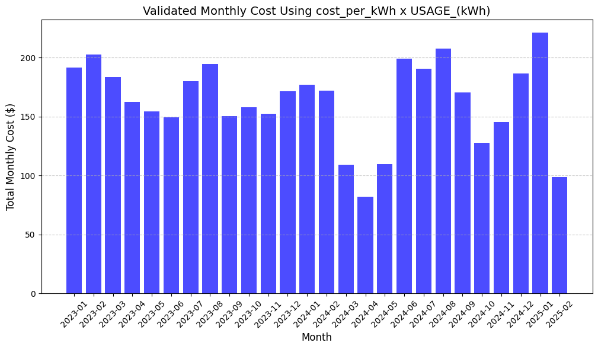

```python
# Filter out rows with negative USAGE or cost_per_kWh
valid_data = merged_combined_df.loc[
    (merged_combined_df['USAGE_(kWh)'] > 0) & (merged_combined_df['cost_per_kWh'] > 0)
].copy()  # Use .copy() to avoid SettingWithCopyWarning

# Extract year and month for grouping
valid_data['Year-Month'] = valid_data['date_timestamp'].dt.to_period('M')

# Calculate total monthly cost using cost_per_kWh
monthly_cost_valid = valid_data.groupby('Year-Month', as_index=False).apply(
    lambda x: pd.Series({'Total_Cost': (x['cost_per_kWh'] * x['USAGE_(kWh)']).sum()}),
    include_groups=False  # Exclude grouping columns during the operation
)

# Convert 'Year-Month' to string for plotting
monthly_cost_valid['Year-Month'] = monthly_cost_valid['Year-Month'].astype(str)

# Plot the monthly cost
import matplotlib.pyplot as plt

plt.figure(figsize=(12, 6))
plt.bar(monthly_cost_valid['Year-Month'], monthly_cost_valid['Total_Cost'], color='blue', alpha=0.7)

# Formatting
plt.xlabel('Month', fontsize=12)
plt.ylabel('Total Monthly Cost ($)', fontsize=12)
plt.title('Validated Monthly Cost Using cost_per_kWh x USAGE_(kWh)', fontsize=14)
plt.xticks(rotation=45)
plt.grid(axis='y', linestyle='--', alpha=0.7)

# Show the plot
plt.show()
```

```python
print(merged_combined_df['cost_per_kWh'].describe())
```

```
count    105183.000000
mean          0.024011
std           0.057140
min           0.000000
25%           0.000000
50%           0.000000
75%           0.000000
max           1.246575
Name: cost_per_kWh, dtype: float64
```

```python
# Define the target timestamp
target_date = pd.Timestamp('2024-04-15 00:00:00')

# Filter the DataFrame for the target date
result = merged_combined_df.loc[merged_combined_df['date_timestamp'] == target_date, ['date_timestamp', 'Billing_Year']]

# Display the result
print(result)
```

```
      date_timestamp  Billing_Year
11278     2024-04-15          2023
```

# Adding the data for the dashboard

```python
# Ensure 'date_timestamp' is in datetime format
merged_combined_df['date_timestamp'] = pd.to_datetime(merged_combined_df['date_timestamp'])

# Create a new DataFrame and filter rows
dashboard_filtered = merged_combined_df[merged_combined_df['date_timestamp'] >= '2024-01-08'].copy()  #Filter data to the solar start date.

# Display the first few rows of the new DataFrame to verify
print("Filtered DataFrame (merged_combined_df):")
print(dashboard_filtered.head())
print(f"Number of rows: {len(merged_combined_df)}")
```

```
Filtered DataFrame (merged_combined_df):
          date_timestamp  month  day_of_month  hour  is_daylight  solar_angle  \
8927 2024-01-08 00:00:00      1             8   0.0            0   -70.011063
8928 2024-01-08 01:00:00      1             8   1.0            0   -66.246124
8929 2024-01-08 02:00:00      1             8   2.0            0   -57.762338
8930 2024-01-08 03:00:00      1             8   3.0            0   -47.404734
8931 2024-01-08 04:00:00      1             8   4.0            0   -36.417971

      solar_azimuth  global_tilted_irradiance  solar_day_count  \
8927       0.987786                       0.0               18
8928      37.481176                       0.0               18
8929      61.244512                       0.0               18
8930      76.587755                       0.0               18
8931      88.037915                       0.0               18

      Estimated_Area_Solar_Production  ...  Production  Purchased  \
8927                              0.0  ...         NaN        NaN
8928                              0.0  ...         NaN        NaN
8929                              0.0  ...         NaN        NaN
8930                              0.0  ...         NaN        NaN
8931                              0.0  ...         NaN        NaN

     Consumption_Status Solaredge_Update_Date  Predicted_Usage  Billing_Year  \
8927          estimated   2025-02-20 23:00:00              NaN          2023
8928          estimated   2025-02-20 23:00:00              NaN          2023
8929          estimated   2025-02-20 23:00:00              NaN          2023
8930          estimated   2025-02-20 23:00:00              NaN          2023
8931          estimated   2025-02-20 23:00:00              NaN          2023

      Billing_Year_Start  Billing_Month_Start   Billing_Month_End  \
8927          2023-04-27           2023-12-28 2024-01-28 23:00:00
8928          2023-04-27           2023-12-28 2024-01-28 23:00:00
8929          2023-04-27           2023-12-28 2024-01-28 23:00:00
8930          2023-04-27           2023-12-28 2024-01-28 23:00:00
8931          2023-04-27           2023-12-28 2024-01-28 23:00:00

      Billing_Month
8927        January
8928        January
8929        January
8930        January
8931        January

[5 rows x 31 columns]
Number of rows: 105190
```

```python
dashboard_filtered.info(verbose=True, show_counts=True)
```

```
<class 'pandas.core.frame.DataFrame'>
Index: 96263 entries, 8927 to 105189
Data columns (total 31 columns):
 #   Column                           Non-Null Count  Dtype
---  ------                           --------------  -----
 0   date_timestamp                   96263 non-null  datetime64[ns]
 1   month                            96263 non-null  int64
 2   day_of_month                     96263 non-null  int64
 3   hour                             96263 non-null  float64
 4   is_daylight                      96263 non-null  int64
 5   solar_angle                      96263 non-null  float64
 6   solar_azimuth                    96263 non-null  float64
 7   global_tilted_irradiance         96263 non-null  float32
 8   solar_day_count                  96263 non-null  int64
 9   Estimated_Area_Solar_Production  96263 non-null  float64
```

[output cut: 23 more lines]

```python
# Define the target timestamp
target_date = pd.Timestamp('2024-04-15 00:00:00')

# Filter the DataFrame for the target date
result = dashboard_filtered.loc[dashboard_filtered['date_timestamp'] == target_date, ['date_timestamp', 'Billing_Year']]

# Display the result
print(result)
```

```
      date_timestamp  Billing_Year
11278     2024-04-15          2023
```

### Create Estimated Consumption

```python
# Step 1: Initialize 'Estimated_Consumption' as 0 for all rows
dashboard_filtered['Estimated_Consumption'] = 0.0

# Step 2: Update 'Estimated_Consumption' for dates greater than the maximum actual date
dashboard_filtered.loc[dashboard_filtered['date_timestamp'] > dashboard_filtered['Solaredge_Update_Date'], 'Estimated_Consumption'] = \
    dashboard_filtered.loc[dashboard_filtered['date_timestamp'] > dashboard_filtered['Solaredge_Update_Date'], 'Predicted_Usage']

# Step 4: Add labels for 'Estimated_Consumption_Label'
dashboard_filtered['Estimated_Consumption_Label'] = 'Actual'  # Default to 'Actual'
dashboard_filtered.loc[dashboard_filtered['date_timestamp'] > max_actual_date, 'Estimated_Consumption_Label'] = 'Predicted'

# Step 5: Drop the 'Predicted_Usage' column
dashboard_filtered = dashboard_filtered.drop(columns=['Predicted_Usage'], errors='ignore')

# Step 6: Verify the changes
dashboard_filtered[['date_timestamp', 'USAGE_(kWh)', 'Consumption', 'Estimated_Consumption', 'Estimated_Consumption_Label']].tail()
```

|  | date_timestamp | USAGE_(kWh) | Consumption | Estimated_Consumption | Estimated_Consumption_Label |
| --- | --- | --- | --- | --- | --- |
| 105185 | 2034-12-31 19:00:00 | 0.0 | 0.0 | 3.42 | Predicted |
| 105186 | 2034-12-31 20:00:00 | 0.0 | 0.0 | 2.87 | Predicted |
| 105187 | 2034-12-31 21:00:00 | 0.0 | 0.0 | 1.96 | Predicted |
| 105188 | 2034-12-31 22:00:00 | 0.0 | 0.0 | 1.68 | Predicted |
| 105189 | 2034-12-31 23:00:00 | 0.0 | 0.0 | 0.88 | Predicted |

```python
dashboard_filtered[['date_timestamp', 'USAGE_(kWh)', 'Consumption', 'Estimated_Consumption', 'Estimated_Consumption_Label']].head()
```

|  | date_timestamp | USAGE_(kWh) | Consumption | Estimated_Consumption | Estimated_Consumption_Label |
| --- | --- | --- | --- | --- | --- |
| 8927 | 2024-01-08 00:00:00 | 0.90 | 0.90 | 0.0 | Actual |
| 8928 | 2024-01-08 01:00:00 | 0.90 | 0.90 | 0.0 | Actual |
| 8929 | 2024-01-08 02:00:00 | 3.44 | 3.44 | 0.0 | Actual |
| 8930 | 2024-01-08 03:00:00 | 0.89 | 0.89 | 0.0 | Actual |
| 8931 | 2024-01-08 04:00:00 | 1.00 | 1.00 | 0.0 | Actual |

```python
dashboard_filtered.info(verbose=True)
```

```
<class 'pandas.core.frame.DataFrame'>
Index: 96263 entries, 8927 to 105189
Data columns (total 32 columns):
 #   Column                           Non-Null Count  Dtype
---  ------                           --------------  -----
 0   date_timestamp                   96263 non-null  datetime64[ns]
 1   month                            96263 non-null  int64
 2   day_of_month                     96263 non-null  int64
 3   hour                             96263 non-null  float64
 4   is_daylight                      96263 non-null  int64
 5   solar_angle                      96263 non-null  float64
 6   solar_azimuth                    96263 non-null  float64
 7   global_tilted_irradiance         96263 non-null  float32
 8   solar_day_count                  96263 non-null  int64
 9   Estimated_Area_Solar_Production  96263 non-null  float64
```

[output cut: 24 more lines]

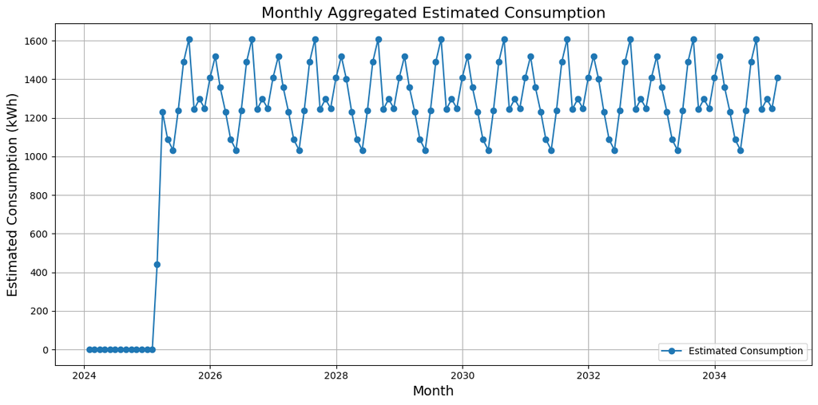

```python
# Ensure 'date_timestamp' is in datetime format
dashboard_filtered['date_timestamp'] = pd.to_datetime(dashboard_filtered['date_timestamp'])

# Aggregate 'Estimated_Consumption' by month
monthly_aggregated = dashboard_filtered.resample('ME', on='date_timestamp')['Estimated_Consumption'].sum()

# Create the line graph
plt.figure(figsize=(12, 6))
plt.plot(monthly_aggregated.index, monthly_aggregated, marker='o', linestyle='-', label='Estimated Consumption')
plt.title('Monthly Aggregated Estimated Consumption', fontsize=16)
plt.xlabel('Month', fontsize=14)
plt.ylabel('Estimated Consumption (kWh)', fontsize=14)
plt.grid(True)
plt.legend()
plt.tight_layout()

# Display the chart
plt.show()
```

```python
# Define the target timestamp
target_date = pd.Timestamp('2024-04-15 00:00:00')

# Filter the DataFrame for the target date
result = dashboard_filtered.loc[dashboard_filtered['date_timestamp'] == target_date, ['date_timestamp', 'Billing_Year']]

# Display the result
print(result)
```

```
      date_timestamp  Billing_Year
11278     2024-04-15          2023
```

### Create Estimated Production field and set it to 0.

```python
# Step 1: Initialize 'Estimated_Production' as 0 for all rows
dashboard_filtered['Estimated_Production'] = 0.0

# Step 2: Update 'Estimated_Production' for dates greater than the maximum actual date with the predicted_value
dashboard_filtered.loc[dashboard_filtered['date_timestamp'] > dashboard_filtered['Solaredge_Update_Date'], 'Estimated_Production'] = \
    dashboard_filtered.loc[dashboard_filtered['date_timestamp'] > dashboard_filtered['Solaredge_Update_Date'], 'predicted_value']

# Step 3: Add labels for 'Estimated_Production_Label'
dashboard_filtered['Estimated_Production_Label'] = 'Actual'  # Default to 'Actual'
dashboard_filtered.loc[dashboard_filtered['date_timestamp'] > dashboard_filtered['Solaredge_Update_Date'], 'Estimated_Production_Label'] = 'Predicted'

# Step 4: Verify the changes
dashboard_filtered[['date_timestamp', 'Production', 'Estimated_Production', 'Estimated_Production_Label']].tail()
```

|  | date_timestamp | Production | Estimated_Production | Estimated_Production_Label |
| --- | --- | --- | --- | --- |
| 105185 | 2034-12-31 19:00:00 | NaN | 0.0 | Predicted |
| 105186 | 2034-12-31 20:00:00 | NaN | 0.0 | Predicted |
| 105187 | 2034-12-31 21:00:00 | NaN | 0.0 | Predicted |
| 105188 | 2034-12-31 22:00:00 | NaN | 0.0 | Predicted |
| 105189 | 2034-12-31 23:00:00 | NaN | 0.0 | Predicted |

```python
dashboard_filtered[['date_timestamp', 'Production', 'Estimated_Production', 'Estimated_Production_Label', 'predicted_value', 'is_daylight']].head()
```

|  | date_timestamp | Production | Estimated_Production | Estimated_Production_Label | predicted_value | is_daylight |
| --- | --- | --- | --- | --- | --- | --- |
| 8927 | 2024-01-08 00:00:00 | NaN | 0.0 | Actual | 0.0 | 0 |
| 8928 | 2024-01-08 01:00:00 | NaN | 0.0 | Actual | 0.0 | 0 |
| 8929 | 2024-01-08 02:00:00 | NaN | 0.0 | Actual | 0.0 | 0 |
| 8930 | 2024-01-08 03:00:00 | NaN | 0.0 | Actual | 0.0 | 0 |
| 8931 | 2024-01-08 04:00:00 | NaN | 0.0 | Actual | 0.0 | 0 |

```python
dashboard_filtered.info(verbose=True,show_counts=True)
```

```
<class 'pandas.core.frame.DataFrame'>
Index: 96263 entries, 8927 to 105189
Data columns (total 34 columns):
 #   Column                           Non-Null Count  Dtype
---  ------                           --------------  -----
 0   date_timestamp                   96263 non-null  datetime64[ns]
 1   month                            96263 non-null  int64
 2   day_of_month                     96263 non-null  int64
 3   hour                             96263 non-null  float64
 4   is_daylight                      96263 non-null  int64
 5   solar_angle                      96263 non-null  float64
 6   solar_azimuth                    96263 non-null  float64
 7   global_tilted_irradiance         96263 non-null  float32
 8   solar_day_count                  96263 non-null  int64
 9   Estimated_Area_Solar_Production  96263 non-null  float64
```

[output cut: 26 more lines]

```python
# Define the target timestamp
target_date = pd.Timestamp('2024-04-15 00:00:00')

# Filter the DataFrame for the target date
result = dashboard_filtered.loc[dashboard_filtered['date_timestamp'] == target_date, ['date_timestamp', 'Billing_Year']]

# Display the result
print(result)
```

```
      date_timestamp  Billing_Year
11278     2024-04-15          2023
```

### Calculating Cost per kWh and taking it to the future

```python
# Step 1: Calculate the mean of valid (non-zero, non-NaN) cost_per_kWh values
non_zero_mean_cost = dashboard_filtered.loc[dashboard_filtered['cost_per_kWh'] > 0, 'cost_per_kWh'].mean()

# Step 2: Efficiently replace 0 and NaN values using vectorized operations
mask = (dashboard_filtered['cost_per_kWh'].isna()) | (dashboard_filtered['cost_per_kWh'] == 0)
dashboard_filtered.loc[mask, 'cost_per_kWh'] = non_zero_mean_cost

# Step 3: Verify the changes
print("✅ Updated cost_per_kWh column:")
print(dashboard_filtered['cost_per_kWh'].describe())
```

```
✅ Updated cost_per_kWh column:
count    96263.000000
mean         0.130134
std          0.010166
min          0.002899
25%          0.130134
50%          0.130134
75%          0.130134
max          0.166667
Name: cost_per_kWh, dtype: float64
```

```python
# Display the first few rows to verify the result
dashboard_filtered[['date_timestamp', 'COST', 'cost_per_kWh']].tail()
```

|  | date_timestamp | COST | cost_per_kWh |
| --- | --- | --- | --- |
| 105185 | 2034-12-31 19:00:00 | 0.0 | 0.130134 |
| 105186 | 2034-12-31 20:00:00 | 0.0 | 0.130134 |
| 105187 | 2034-12-31 21:00:00 | 0.0 | 0.130134 |
| 105188 | 2034-12-31 22:00:00 | 0.0 | 0.130134 |
| 105189 | 2034-12-31 23:00:00 | 0.0 | 0.130134 |

```python
# Step 1: Identify the maximum actual date
max_cost_date = electric_df.loc[electric_df['cost_per_kWh'] != 0, 'date_timestamp'].max()

if pd.isna(max_cost_date):
    print("❌ No valid max_cost_date found, using earliest available date.")
    max_cost_date = electric_df['date_timestamp'].min()

print("✅ Maximum cost date:", max_cost_date)

# Step 2: Filter historical data (before max_cost_date)
historical_data = dashboard_filtered[dashboard_filtered['date_timestamp'] <= max_cost_date].copy()

# Optimize memory usage by converting to smaller integer types
historical_data['month'] = historical_data['date_timestamp'].dt.month.astype('int8')
historical_data['day'] = historical_data['date_timestamp'].dt.day.astype('int8')
historical_data['hour'] = historical_data['date_timestamp'].dt.hour.astype('int8')

# Step 3: Group historical data by month, day, and hour and calculate mean and std for cost_per_kWh
grouped_historical_costs = historical_data.groupby(['month', 'day', 'hour'], as_index=False).agg(
    mean=('cost_per_kWh', 'mean'),
    std=('cost_per_kWh', 'std')
)

# Step 4: Filter future data (after max_cost_date)
future_data = dashboard_filtered[dashboard_filtered['date_timestamp'] > max_cost_date].copy()

# Extract and optimize month, day, and hour for future data
future_data['month'] = future_data['date_timestamp'].dt.month.astype('int8')
future_data['day'] = future_data['date_timestamp'].dt.day.astype('int8')
future_data['hour'] = future_data['date_timestamp'].dt.hour.astype('int8')

# Handle leap year: Replace February 29 in future data with February 28 from historical data
future_data.loc[(future_data['month'] == 2) & (future_data['day'] == 29), 'day'] = 28

# Step 5: Merge future data with grouped historical costs
future_data = future_data.merge(
    grouped_historical_costs,
    on=['month', 'day', 'hour'],
    how='left'
)

# Step 6: Assign historical averages to 'Estimated_Cost_Per_KWh'
# If no match is found, fill missing values with the overall historical mean
historical_mean_cost = historical_data['cost_per_kWh'].mean()
future_data['Estimated_Cost_Per_KWh'] = future_data['mean'].fillna(historical_mean_cost)

# Add variability to the estimated costs using historical standard deviation (optimized for memory)
future_data['Estimated_Cost_Per_KWh'] += future_data['std'].fillna(0) * future_data.apply(
    lambda _: np.random.uniform(-0.5, 0.5), axis=1
)

# Step 7: Add 'Cost_Label' to indicate whether the row is 'Actual' or 'Estimated'
historical_data['Cost_Label'] = 'Actual'
future_data['Cost_Label'] = 'Estimated'

# Drop unnecessary columns from future_data
future_data.drop(columns=['mean', 'std'], inplace=True, errors='ignore')

# Step 8: Update the original DataFrame by concatenating historical and future data
dashboard_filtered = pd.concat([historical_data, future_data], ignore_index=True).sort_values(by='date_timestamp')

# Drop extra columns no longer needed
dashboard_filtered.drop(columns=['month', 'day', 'hour'], errors='ignore', inplace=True)

# Step 9: Verify the changes
print("✅ Updated DataFrame with 'Estimated_Cost_Per_KWh' and 'Cost_Label':")
print(dashboard_filtered[['date_timestamp', 'cost_per_kWh', 'Estimated_Cost_Per_KWh', 'Cost_Label']].tail())
```

```
✅ Maximum cost date: 2025-02-14 23:00:00
✅ Updated DataFrame with 'Estimated_Cost_Per_KWh' and 'Cost_Label':
           date_timestamp  cost_per_kWh  Estimated_Cost_Per_KWh Cost_Label
96258 2034-12-31 19:00:00      0.130134                0.126638  Estimated
96259 2034-12-31 20:00:00      0.130134                0.126984  Estimated
96260 2034-12-31 21:00:00      0.130134                0.126168  Estimated
96261 2034-12-31 22:00:00      0.130134                0.127572  Estimated
96262 2034-12-31 23:00:00      0.130134                0.127517  Estimated
```

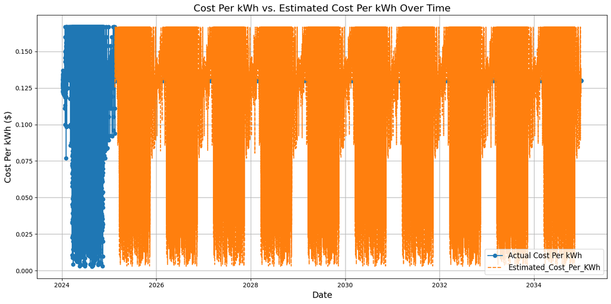

```python
# Plot the line graph for cost_per_kWh and Estimated_Cost_Per_KWh
plt.figure(figsize=(14, 7))
plt.plot(dashboard_filtered['date_timestamp'], dashboard_filtered['cost_per_kWh'], label='Actual Cost Per kWh', marker='o')
plt.plot(dashboard_filtered['date_timestamp'], dashboard_filtered['Estimated_Cost_Per_KWh'], label='Estimated_Cost_Per_KWh', linestyle='--')
plt.title('Cost Per kWh vs. Estimated Cost Per kWh Over Time', fontsize=16)
plt.xlabel('Date', fontsize=14)
plt.ylabel('Cost Per kWh ($)', fontsize=14)
plt.legend(fontsize=12)
plt.grid(True)
plt.tight_layout()

# Display the chart
plt.show()
```

```python
# Apply absolute value correction to cost_per_kWh
dashboard_filtered['cost_per_kWh'] = dashboard_filtered['cost_per_kWh'].abs()
dashboard_filtered['Estimated_Cost_Per_KWh'] = dashboard_filtered['Estimated_Cost_Per_KWh'].abs()
# Verify the update
print("Updated dashboard_filtered DataFrame with absolute cost_per_kWh:")
print(dashboard_filtered[['date_timestamp', 'cost_per_kWh']].tail())
```

```
Updated dashboard_filtered DataFrame with absolute cost_per_kWh:
           date_timestamp  cost_per_kWh
96258 2034-12-31 19:00:00      0.130134
96259 2034-12-31 20:00:00      0.130134
96260 2034-12-31 21:00:00      0.130134
96261 2034-12-31 22:00:00      0.130134
96262 2034-12-31 23:00:00      0.130134
```

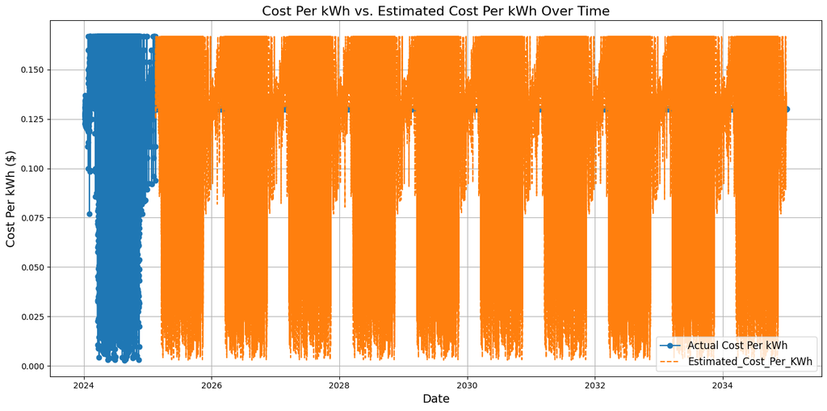

```python
# Plot the line graph for cost_per_kWh and Estimated_Cost_Per_KWh
plt.figure(figsize=(14, 7))
plt.plot(dashboard_filtered['date_timestamp'], dashboard_filtered['cost_per_kWh'], label='Actual Cost Per kWh', marker='o')
plt.plot(dashboard_filtered['date_timestamp'], dashboard_filtered['Estimated_Cost_Per_KWh'], label='Estimated_Cost_Per_KWh', linestyle='--')
plt.title('Cost Per kWh vs. Estimated Cost Per kWh Over Time', fontsize=16)
plt.xlabel('Date', fontsize=14)
plt.ylabel('Cost Per kWh ($)', fontsize=14)
plt.legend(fontsize=12)
plt.grid(True)
plt.tight_layout()

# Display the chart
plt.show()
```

```python
dashboard_filtered.info(verbose=True,show_counts=True)
```

```
<class 'pandas.core.frame.DataFrame'>
RangeIndex: 96263 entries, 0 to 96262
Data columns (total 34 columns):
 #   Column                           Non-Null Count  Dtype
---  ------                           --------------  -----
 0   date_timestamp                   96263 non-null  datetime64[ns]
 1   day_of_month                     96263 non-null  int64
 2   is_daylight                      96263 non-null  int64
 3   solar_angle                      96263 non-null  float64
 4   solar_azimuth                    96263 non-null  float64
 5   global_tilted_irradiance         96263 non-null  float32
 6   solar_day_count                  96263 non-null  int64
 7   Estimated_Area_Solar_Production  96263 non-null  float64
 8   value                            0 non-null      float64
 9   predicted_value                  96263 non-null  float64
```

[output cut: 26 more lines]

```python
# Define the target timestamp
target_date = pd.Timestamp('2024-04-15 00:00:00')

# Filter the DataFrame for the target date
result = dashboard_filtered.loc[dashboard_filtered['date_timestamp'] == target_date, ['date_timestamp', 'Billing_Year']]

# Display the result
print(result)
```

```
     date_timestamp  Billing_Year
2351     2024-04-15          2023
```

```python
# Define the filename for saving the dashboard data
file_path = "bi_solar_dashboard.pkl"

# Save the DataFrame locally in GitHub Codespaces
dashboard_filtered.to_pickle(file_path)
print(f"✅ Dashboard data saved to {file_path}")
```

```
✅ Dashboard data saved to bi_solar_dashboard.pkl
```

```python
dashboard_filtered.info(verbose=True,show_counts=True)
```

```
<class 'pandas.core.frame.DataFrame'>
RangeIndex: 96263 entries, 0 to 96262
Data columns (total 34 columns):
 #   Column                           Non-Null Count  Dtype
---  ------                           --------------  -----
 0   date_timestamp                   96263 non-null  datetime64[ns]
 1   day_of_month                     96263 non-null  int64
 2   is_daylight                      96263 non-null  int64
 3   solar_angle                      96263 non-null  float64
 4   solar_azimuth                    96263 non-null  float64
 5   global_tilted_irradiance         96263 non-null  float32
 6   solar_day_count                  96263 non-null  int64
 7   Estimated_Area_Solar_Production  96263 non-null  float64
 8   value                            0 non-null      float64
 9   predicted_value                  96263 non-null  float64
```

[output cut: 26 more lines]

```python
display(dashboard_filtered[['date_timestamp', 'Billing_Year', 'Billing_Year_Start', 'Billing_Month', 'Billing_Month_Start', 'Billing_Month_End']])
```

|  | date_timestamp | Billing_Year | Billing_Year_Start | Billing_Month | Billing_Month_Start | Billing_Month_End |
| --- | --- | --- | --- | --- | --- | --- |
| 0 | 2024-01-08 00:00:00 | 2023 | 2023-04-27 | January | 2023-12-28 | 2024-01-28 23:00:00 |
| 1 | 2024-01-08 01:00:00 | 2023 | 2023-04-27 | January | 2023-12-28 | 2024-01-28 23:00:00 |
| 2 | 2024-01-08 02:00:00 | 2023 | 2023-04-27 | January | 2023-12-28 | 2024-01-28 23:00:00 |
| 3 | 2024-01-08 03:00:00 | 2023 | 2023-04-27 | January | 2023-12-28 | 2024-01-28 23:00:00 |
| 4 | 2024-01-08 04:00:00 | 2023 | 2023-04-27 | January | 2023-12-28 | 2024-01-28 23:00:00 |
| ... | ... | ... | ... | ... | ... | ... |
| 96258 | 2034-12-31 19:00:00 | 2034 | 2034-05-01 | December | 2034-12-06 | 2035-01-04 23:00:00 |
| 96259 | 2034-12-31 20:00:00 | 2034 | 2034-05-01 | December | 2034-12-06 | 2035-01-04 23:00:00 |
| 96260 | 2034-12-31 21:00:00 | 2034 | 2034-05-01 | December | 2034-12-06 | 2035-01-04 23:00:00 |
| 96261 | 2034-12-31 22:00:00 | 2034 | 2034-05-01 | December | 2034-12-06 | 2035-01-04 23:00:00 |
| 96262 | 2034-12-31 23:00:00 | 2034 | 2034-05-01 | December | 2034-12-06 | 2035-01-04 23:00:00 |

96263 rows × 6 columns

```python
# Define the target timestamp
target_date = pd.Timestamp('2024-04-15 00:00:00')

# Filter the DataFrame for the target date
result = dashboard_filtered.loc[dashboard_filtered['date_timestamp'] == target_date, ['date_timestamp', 'Billing_Year']]

# Display the result
print(result)
```

```
     date_timestamp  Billing_Year
2351     2024-04-15          2023
```

### Investigate NaN and 0 values on the key fields - production, consumption, estimated prodction, estimated consumption, estimated cost per kwh, cost per kwh to decide how to handle NaN safely.

### Production and Estimated Production.

- These are both fine to 0 fill the NaN. 0's are naturally happening due to snowfall and around the edges of sunrise and sunset. NaNs are too few to worry about (2)

```python
# Identify problematic 0 or NaN values in Production
# Define the condition to filter rows
condition = (
    ((dashboard_filtered['Production'] == 0) | (dashboard_filtered['Production'].isna())) &
    (dashboard_filtered['is_daylight'] == 1) &
    (dashboard_filtered['date_timestamp'] > '2024-01-08') &
    (dashboard_filtered['date_timestamp'] <= dashboard_filtered['Solaredge_Update_Date'])
)

# Filter the DataFrame based on the condition
zero_or_nan_production = dashboard_filtered.loc[condition, ['date_timestamp', 'Production', 'is_daylight']]

# Print the count of rows matching the condition
print(f"Total rows matching the condition: {len(zero_or_nan_production)}")

# Display the filtered data
print(zero_or_nan_production)
```

```
Total rows matching the condition: 170
          date_timestamp  Production  is_daylight
7    2024-01-08 07:00:00         NaN            1
8    2024-01-08 08:00:00         NaN            1
16   2024-01-08 16:00:00         0.0            1
31   2024-01-09 07:00:00         0.0            1
32   2024-01-09 08:00:00         0.0            1
...                  ...         ...          ...
9544 2025-02-08 17:00:00         0.0            1
9640 2025-02-12 17:00:00         0.0            1
9688 2025-02-14 17:00:00         0.0            1
9702 2025-02-15 07:00:00         0.0            1
9712 2025-02-15 17:00:00         0.0            1

[170 rows x 3 columns]
```

```python
# Identify problematic 0 or NaN values in Estimated Production
# Define the condition to filter rows
condition = (
    ((dashboard_filtered['Estimated_Production'] == 0) | (dashboard_filtered['Estimated_Production'].isna())) &
    (dashboard_filtered['is_daylight'] == 1) &
    (dashboard_filtered['date_timestamp'] > dashboard_filtered['Solaredge_Update_Date'])
)

# Filter the DataFrame based on the condition
zero_or_nan_estimated_production = dashboard_filtered.loc[condition, ['date_timestamp', 'Estimated_Production', 'is_daylight']]

# Print the count of rows matching the condition
print(f"Total rows matching the condition: {len(zero_or_nan_estimated_production)}")

# Display the filtered data
print(zero_or_nan_estimated_production)
```

```
Total rows matching the condition: 0
Empty DataFrame
Columns: [date_timestamp, Estimated_Production, is_daylight]
Index: []
```